# Credit Portfolio Risk Monitoring & Automation Dashboard

Zahra Nur Anisah

May 19, 2026

# Project Description

This project focuses on developing an **interactive Credit Portfolio Risk Monitoring and Automation Dashboard** using **R Shiny**, designed to help financial institutions monitor loan performance and detect early signs of credit risk.

The dashboard delivers comprehensive automation and analytics capabilities, such as: - Integrated **Gross**, **Net**, and **External** portfolios across **7 islands** and **37 regions** throughout **Indonesia**.  
- Automated the tracking of key **credit risk indicators**, including:  
- **Days Past Due (DPD) buckets**  
- **Non-Performing Loan (NPL) ratios**  
- **Flow rate movements**  
- Reduced **manual reporting efforts** by **up to 95%** through automation and **real-time portfolio monitoring**.

# Introduction

The first step involves importing all necessary libraries that support data manipulation, visualization, and the creation of an interactive dashboard.

```r
# Load required libraries
library(dplyr)   # Data manipulation
library(ggplot2) # Data visualization
library(ggpubr)
library(scales)  # For number formatting (commas, percentages)
library(tidyverse)  # For data cleaning and manipulation
library(glue)
library(plotly)  # For interactive visualizations
library(lubridate)   # For working with date and time
options(scipen = 100) # Prevent scientific notation in numeric outputs
library(readxl)
library(purrr) # Mapping function over lists
```

# Load Data

Before reading the three datasets **(Gross, Net, and External)**, we first need to create a dedicated folder for each dataset on our local computer, ideally within the same directory as the project file. Each folder will serve as a dedicated storage location for the files containing the respective data.

This setup makes it easy to keep the datasets up to date, you can simply add new files to the corresponding folder, and the code will automatically detect, compile, and merge all files within that folder into a single, unified dataset.

After completing the folder setup, we can proceed to load and read the three datasets (Gross, Net, and External), from their respective directories:

1. *Gross*

```r
# Read Data: Gross
# Define the folder path for the "Gross" dataset
folder_path_gross <- "dataset/DPD NPL Gross Net Extrenal/Gross/"

# List all .xlsx files in the "Gross" folder
file_list_gross <- list.files(path = folder_path_gross,
                              pattern = "\\.xlsx$",
                              full.name = TRUE)

# Combine all Excel files into one dataframe
sqllab_gross <- file_list_gross %>%
  map_df(read_excel)

# Read all "Gross" dataset files (including possible duplicates and NA values)
sqllab_gross
```

```
#> # A tibble: 135,420 × 8
#>    cut_off_date island   region area      branch bucket   noa outstanding_amount
#>    <chr>        <chr>    <chr>  <chr>     <chr>  <chr>  <dbl>              <dbl>
#>  1 2024-09-07   Sumatera Aceh   Aceh Are… Aceh … 01. C…    90         247996238.
#>  2 2024-09-07   Sumatera Aceh   Aceh Are… Aceh … 02. 1…   398        1764887888.
#>  3 2024-09-07   Sumatera Aceh   Aceh Are… Aceh … 03. 3…    88         121150426.
#>  4 2024-09-07   Sumatera Aceh   Aceh Are… Aceh … 04. 6…   363        1779603655.
#>  5 2024-09-07   Sumatera Aceh   Aceh Are… Aceh … 05. 9…   381        1578962001.
#>  6 2024-09-07   Sumatera Aceh   Aceh Are… Aceh … 01. C…   392         592882176.
#>  7 2024-09-07   Sumatera Aceh   Aceh Are… Aceh … 02. 1…   427        1060323025.
#>  8 2024-09-07   Sumatera Aceh   Aceh Are… Aceh … 03. 3…   252        1186179109.
#>  9 2024-09-07   Sumatera Aceh   Aceh Are… Aceh … 04. 6…   401        1720709628.
#> 10 2024-09-07   Sumatera Aceh   Aceh Are… Aceh … 05. 9…   339         940269654.
#> # ℹ 135,410 more rows
```

```r
# Read top 10 "Gross" dataset
head(sqllab_gross,10)
```

```
#> # A tibble: 10 × 8
#>    cut_off_date island   region area      branch bucket   noa outstanding_amount
#>    <chr>        <chr>    <chr>  <chr>     <chr>  <chr>  <dbl>              <dbl>
#>  1 2024-09-07   Sumatera Aceh   Aceh Are… Aceh … 01. C…    90         247996238.
#>  2 2024-09-07   Sumatera Aceh   Aceh Are… Aceh … 02. 1…   398        1764887888.
#>  3 2024-09-07   Sumatera Aceh   Aceh Are… Aceh … 03. 3…    88         121150426.
#>  4 2024-09-07   Sumatera Aceh   Aceh Are… Aceh … 04. 6…   363        1779603655.
#>  5 2024-09-07   Sumatera Aceh   Aceh Are… Aceh … 05. 9…   381        1578962001.
#>  6 2024-09-07   Sumatera Aceh   Aceh Are… Aceh … 01. C…   392         592882176.
#>  7 2024-09-07   Sumatera Aceh   Aceh Are… Aceh … 02. 1…   427        1060323025.
#>  8 2024-09-07   Sumatera Aceh   Aceh Are… Aceh … 03. 3…   252        1186179109.
#>  9 2024-09-07   Sumatera Aceh   Aceh Are… Aceh … 04. 6…   401        1720709628.
#> 10 2024-09-07   Sumatera Aceh   Aceh Are… Aceh … 05. 9…   339         940269654.
```

2. *Net*

```r
# Read Data: Net
# Define the folder path for the "Net" dataset
folder_path_net <- "dataset/DPD NPL Gross Net Extrenal/Net/"

# List all .xlsx files in the "Net" folder
file_list_net <- list.files(path = folder_path_net,
                              pattern = "\\.xlsx$",
                              full.name = TRUE)

# Combine all Excel files into one dataframe
sqllab_net <- file_list_net %>%
  map_df(read_excel)

# Read all "Net" dataset files (including possible duplicates and NA values)
sqllab_net
```

```
#> # A tibble: 135,420 × 8
#>    cut_off_date island   region area      branch bucket   noa outstanding_amount
#>    <chr>        <chr>    <chr>  <chr>     <chr>  <chr>  <dbl>              <dbl>
#>  1 2024-09-07   Sumatera Aceh   Aceh Are… Aceh … 01. C…    90         199563952.
#>  2 2024-09-07   Sumatera Aceh   Aceh Are… Aceh … 02. 1…   398        1087429152.
#>  3 2024-09-07   Sumatera Aceh   Aceh Are… Aceh … 03. 3…    88          80699264.
#>  4 2024-09-07   Sumatera Aceh   Aceh Are… Aceh … 04. 6…   363        1166194817.
#>  5 2024-09-07   Sumatera Aceh   Aceh Are… Aceh … 05. 9…   381         399117020.
#>  6 2024-09-07   Sumatera Aceh   Aceh Are… Aceh … 01. C…   392         500172213.
#>  7 2024-09-07   Sumatera Aceh   Aceh Are… Aceh … 02. 1…   427         929907004.
#>  8 2024-09-07   Sumatera Aceh   Aceh Are… Aceh … 03. 3…   252         810127497.
#>  9 2024-09-07   Sumatera Aceh   Aceh Are… Aceh … 04. 6…   401        1455593647.
#> 10 2024-09-07   Sumatera Aceh   Aceh Are… Aceh … 05. 9…   339         439075659.
#> # ℹ 135,410 more rows
```

```r
# Read top 10 "Net" dataset
head(sqllab_net,10)
```

```
#> # A tibble: 10 × 8
#>    cut_off_date island   region area      branch bucket   noa outstanding_amount
#>    <chr>        <chr>    <chr>  <chr>     <chr>  <chr>  <dbl>              <dbl>
#>  1 2024-09-07   Sumatera Aceh   Aceh Are… Aceh … 01. C…    90         199563952.
#>  2 2024-09-07   Sumatera Aceh   Aceh Are… Aceh … 02. 1…   398        1087429152.
#>  3 2024-09-07   Sumatera Aceh   Aceh Are… Aceh … 03. 3…    88          80699264.
#>  4 2024-09-07   Sumatera Aceh   Aceh Are… Aceh … 04. 6…   363        1166194817.
#>  5 2024-09-07   Sumatera Aceh   Aceh Are… Aceh … 05. 9…   381         399117020.
#>  6 2024-09-07   Sumatera Aceh   Aceh Are… Aceh … 01. C…   392         500172213.
#>  7 2024-09-07   Sumatera Aceh   Aceh Are… Aceh … 02. 1…   427         929907004.
#>  8 2024-09-07   Sumatera Aceh   Aceh Are… Aceh … 03. 3…   252         810127497.
#>  9 2024-09-07   Sumatera Aceh   Aceh Are… Aceh … 04. 6…   401        1455593647.
#> 10 2024-09-07   Sumatera Aceh   Aceh Are… Aceh … 05. 9…   339         439075659.
```

3. *External*

```r
# Read Data: External
# Define the folder path for the "External" dataset
folder_path_external <- "dataset/DPD NPL Gross Net Extrenal/External/"

# List all .xlsx files in the "External" folder
file_list_external <- list.files(path = folder_path_external,
                              pattern = "\\.xlsx$",
                              full.name = TRUE)

# Combine all Excel files into one dataframe
sqllab_external <- file_list_external %>%
  map_df(read_excel)

# Read all "External" dataset files (including possible duplicates and NA values)
sqllab_external
```

```
#> # A tibble: 135,420 × 8
#>    cut_off_date island   region area      branch bucket   noa outstanding_amount
#>    <chr>        <chr>    <chr>  <chr>     <chr>  <chr>  <dbl>              <dbl>
#>  1 2024-09-07   Sumatera Aceh   Aceh Are… Aceh … 01. C…    90         163127228.
#>  2 2024-09-07   Sumatera Aceh   Aceh Are… Aceh … 02. 1…   398         882898762.
#>  3 2024-09-07   Sumatera Aceh   Aceh Are… Aceh … 03. 3…    88          58992308.
#>  4 2024-09-07   Sumatera Aceh   Aceh Are… Aceh … 04. 6…   363        1036411906.
#>  5 2024-09-07   Sumatera Aceh   Aceh Are… Aceh … 05. 9…   381         117578953.
#>  6 2024-09-07   Sumatera Aceh   Aceh Are… Aceh … 01. C…   392         360501598.
#>  7 2024-09-07   Sumatera Aceh   Aceh Are… Aceh … 02. 1…   427         721679483.
#>  8 2024-09-07   Sumatera Aceh   Aceh Are… Aceh … 03. 3…   252         728315290.
#>  9 2024-09-07   Sumatera Aceh   Aceh Are… Aceh … 04. 6…   401        1164871850.
#> 10 2024-09-07   Sumatera Aceh   Aceh Are… Aceh … 05. 9…   339         130194274.
#> # ℹ 135,410 more rows
```

```r
# Read top 10 "External" dataset
head(sqllab_external,10)
```

```
#> # A tibble: 10 × 8
#>    cut_off_date island   region area      branch bucket   noa outstanding_amount
#>    <chr>        <chr>    <chr>  <chr>     <chr>  <chr>  <dbl>              <dbl>
#>  1 2024-09-07   Sumatera Aceh   Aceh Are… Aceh … 01. C…    90         163127228.
#>  2 2024-09-07   Sumatera Aceh   Aceh Are… Aceh … 02. 1…   398         882898762.
#>  3 2024-09-07   Sumatera Aceh   Aceh Are… Aceh … 03. 3…    88          58992308.
#>  4 2024-09-07   Sumatera Aceh   Aceh Are… Aceh … 04. 6…   363        1036411906.
#>  5 2024-09-07   Sumatera Aceh   Aceh Are… Aceh … 05. 9…   381         117578953.
#>  6 2024-09-07   Sumatera Aceh   Aceh Are… Aceh … 01. C…   392         360501598.
#>  7 2024-09-07   Sumatera Aceh   Aceh Are… Aceh … 02. 1…   427         721679483.
#>  8 2024-09-07   Sumatera Aceh   Aceh Are… Aceh … 03. 3…   252         728315290.
#>  9 2024-09-07   Sumatera Aceh   Aceh Are… Aceh … 04. 6…   401        1164871850.
#> 10 2024-09-07   Sumatera Aceh   Aceh Are… Aceh … 05. 9…   339         130194274.
```

Here are the descriptions of each column in all three datasets.

- `cut_off_date`: the date when the data was extracted or recorded (in YYYY-MM-DD format).
- `island`: the main island or geographical region where the accounts is located.
- `region`: the operational region under an island used for grouping working areas.
- `area`: the operational coverage area that supervises several branches within a region.
- `branch`: the branch or operational unit where the accounts is managed.
- `bucket`: the category group representing loan delinquency or credit quality, usually based on Days Past Due (DPD) ranges.
- `noa`: the number of accounts (Number of accounts) in the loan portfolio.
- `outstanding_amount`: the total outstanding balance or remaining unpaid loan amount.

Now that we’ve read all the datasets and stored them in their respective variables, it’s time to move on to **Data Cleaning & Preprocessing** to ensure the data is accurate, consistent, and ready for further analysis.

# Data Cleaning & Prepocessing

Here are the following steps required to clean and preprocess your dataset so that it’s ready for data analysis:

- **1️⃣ Data Cleansing**, which includes:
  - Deleting unnecessary columns or rows
  - Renaming columns for consistency
  - Changing data types
  - Adding new columns
  - Sorting data (if needed)
- **2️⃣ Remove Missing Data (NA values)**
- **3️⃣ Remove Duplicate Data**

## Gross Dataset

```r
# Checking the "Gross" dataset's dimension
dim(sqllab_gross)
```

```
#> [1] 135420      8
```

```r
# Checking data types for each column
summary(sqllab_gross)
```

```
#>  cut_off_date          island             region              area
#>  Length:135420      Length:135420      Length:135420      Length:135420
#>  Class :character   Class :character   Class :character   Class :character
#>  Mode  :character   Mode  :character   Mode  :character   Mode  :character
#>
#>
#>
#>     branch             bucket               noa        outstanding_amount
#>  Length:135420      Length:135420      Min.   : 50.0   Min.   :  51258992
#>  Class :character   Class :character   1st Qu.:161.0   1st Qu.: 401388328
#>  Mode  :character   Mode  :character   Median :274.0   Median : 704291174
#>                                        Mean   :274.1   Mean   : 822829972
#>                                        3rd Qu.:386.0   3rd Qu.:1155246835
#>                                        Max.   :499.0   Max.   :2490873922
```

```r
# Gross Dataset
sqllab_gross
```

```
#> # A tibble: 135,420 × 8
#>    cut_off_date island   region area      branch bucket   noa outstanding_amount
#>    <chr>        <chr>    <chr>  <chr>     <chr>  <chr>  <dbl>              <dbl>
#>  1 2024-09-07   Sumatera Aceh   Aceh Are… Aceh … 01. C…    90         247996238.
#>  2 2024-09-07   Sumatera Aceh   Aceh Are… Aceh … 02. 1…   398        1764887888.
#>  3 2024-09-07   Sumatera Aceh   Aceh Are… Aceh … 03. 3…    88         121150426.
#>  4 2024-09-07   Sumatera Aceh   Aceh Are… Aceh … 04. 6…   363        1779603655.
#>  5 2024-09-07   Sumatera Aceh   Aceh Are… Aceh … 05. 9…   381        1578962001.
#>  6 2024-09-07   Sumatera Aceh   Aceh Are… Aceh … 01. C…   392         592882176.
#>  7 2024-09-07   Sumatera Aceh   Aceh Are… Aceh … 02. 1…   427        1060323025.
#>  8 2024-09-07   Sumatera Aceh   Aceh Are… Aceh … 03. 3…   252        1186179109.
#>  9 2024-09-07   Sumatera Aceh   Aceh Are… Aceh … 04. 6…   401        1720709628.
#> 10 2024-09-07   Sumatera Aceh   Aceh Are… Aceh … 05. 9…   339         940269654.
#> # ℹ 135,410 more rows
```

```r
# Data Cleansing & Preprocessing: Gross
# 1. Cleansing Data
sqllab_gross_clean <- sqllab_gross %>%

  mutate(
    # Changing data types
    cut_off_date= ymd(cut_off_date),
    island = as.factor(island),
    region = as.factor(region),
    area = as.factor(area),
    branch = as.factor(branch),
    bucket = as.factor(bucket),
    noa = as.integer(noa),
    outstanding_amount = as.numeric(outstanding_amount),

    # adding new column
    date = day(cut_off_date),
    month = month(cut_off_date),
    year = year(cut_off_date)
  ) %>%

  arrange(desc(cut_off_date))

sqllab_gross_clean
```

```
#> # A tibble: 135,420 × 11
#>    cut_off_date island region area  branch bucket   noa outstanding_amount  date
#>    <date>       <fct>  <fct>  <fct> <fct>  <fct>  <int>              <dbl> <int>
#>  1 2025-11-01   Sumat… Aceh   Aceh… Aceh … 01. C…    53          91784130.     1
#>  2 2025-11-01   Sumat… Aceh   Aceh… Aceh … 02. 1…   185         254273192.     1
#>  3 2025-11-01   Sumat… Aceh   Aceh… Aceh … 03. 3…   173         431221028.     1
#>  4 2025-11-01   Sumat… Aceh   Aceh… Aceh … 04. 6…   271        1326525315.     1
#>  5 2025-11-01   Sumat… Aceh   Aceh… Aceh … 05. 9…   119         557134482.     1
#>  6 2025-11-01   Sumat… Aceh   Aceh… Aceh … 01. C…   176         836408397.     1
#>  7 2025-11-01   Sumat… Aceh   Aceh… Aceh … 02. 1…   443         850066868.     1
#>  8 2025-11-01   Sumat… Aceh   Aceh… Aceh … 03. 3…   369        1051253334.     1
#>  9 2025-11-01   Sumat… Aceh   Aceh… Aceh … 04. 6…   386         920064468.     1
#> 10 2025-11-01   Sumat… Aceh   Aceh… Aceh … 05. 9…   148         702017007.     1
#> # ℹ 135,410 more rows
#> # ℹ 2 more variables: month <dbl>, year <dbl>
```

```r
# 2. Delete NA/ Missing Data
# Checking if there are any missing data
sqllab_gross_clean %>% is.na() %>% colSums()
```

```
#>       cut_off_date             island             region               area
#>                  0                  0                  0                  0
#>             branch             bucket                noa outstanding_amount
#>                  0                  0                  0                  0
#>               date              month               year
#>                  0                  0                  0
```

```r
# If we want to see the missing data
sqllab_gross_clean %>%
  filter(if_any(everything(),is.na))
```

```
#> # A tibble: 0 × 11
#> # ℹ 11 variables: cut_off_date <date>, island <fct>, region <fct>, area <fct>,
#> #   branch <fct>, bucket <fct>, noa <int>, outstanding_amount <dbl>,
#> #   date <int>, month <dbl>, year <dbl>
```

```r
# If there are any NA values, remove the rows containing NA
sqllab_gross_clean <- sqllab_gross_clean %>%
  drop_na()

# Check the dimensions of the Gross dataset after removing NA values
dim(sqllab_gross_clean)
```

```
#> [1] 135420     11
```

There are *no NA/ missing data* in the Gross dataset

```r
# 3. Delete Duplicate Data
# Checking if there are any duplicate data
sqllab_gross_clean %>% duplicated() %>% sum()
```

```
#> [1] 0
```

```r
# If there are any duplicates, keep only the unique rows OR remove any duplicates
sqllab_gross_clean <- sqllab_gross_clean %>%
  distinct(.keep_all = TRUE)

# Check the dimensions of the Gross dataset after removing duplicates
dim(sqllab_gross_clean)
```

```
#> [1] 135420     11
```

There are *no duplicate data* in the Gross dataset

```r
# Final "Gross" dataset form
sqllab_gross_clean
```

```
#> # A tibble: 135,420 × 11
#>    cut_off_date island region area  branch bucket   noa outstanding_amount  date
#>    <date>       <fct>  <fct>  <fct> <fct>  <fct>  <int>              <dbl> <int>
#>  1 2025-11-01   Sumat… Aceh   Aceh… Aceh … 01. C…    53          91784130.     1
#>  2 2025-11-01   Sumat… Aceh   Aceh… Aceh … 02. 1…   185         254273192.     1
#>  3 2025-11-01   Sumat… Aceh   Aceh… Aceh … 03. 3…   173         431221028.     1
#>  4 2025-11-01   Sumat… Aceh   Aceh… Aceh … 04. 6…   271        1326525315.     1
#>  5 2025-11-01   Sumat… Aceh   Aceh… Aceh … 05. 9…   119         557134482.     1
#>  6 2025-11-01   Sumat… Aceh   Aceh… Aceh … 01. C…   176         836408397.     1
#>  7 2025-11-01   Sumat… Aceh   Aceh… Aceh … 02. 1…   443         850066868.     1
#>  8 2025-11-01   Sumat… Aceh   Aceh… Aceh … 03. 3…   369        1051253334.     1
#>  9 2025-11-01   Sumat… Aceh   Aceh… Aceh … 04. 6…   386         920064468.     1
#> 10 2025-11-01   Sumat… Aceh   Aceh… Aceh … 05. 9…   148         702017007.     1
#> # ℹ 135,410 more rows
#> # ℹ 2 more variables: month <dbl>, year <dbl>
```

## Net Dataset

```r
# Checking the "Net" dataset's dimension
dim(sqllab_net)
```

```
#> [1] 135420      8
```

```r
# Checking data types for each column
summary(sqllab_net)
```

```
#>  cut_off_date          island             region              area
#>  Length:135420      Length:135420      Length:135420      Length:135420
#>  Class :character   Class :character   Class :character   Class :character
#>  Mode  :character   Mode  :character   Mode  :character   Mode  :character
#>
#>
#>
#>     branch             bucket               noa        outstanding_amount
#>  Length:135420      Length:135420      Min.   : 50.0   Min.   :  12377332
#>  Class :character   Class :character   1st Qu.:161.0   1st Qu.: 242907737
#>  Mode  :character   Mode  :character   Median :274.0   Median : 449070198
#>                                        Mean   :274.1   Mean   : 551303156
#>                                        3rd Qu.:386.0   3rd Qu.: 773143047
#>                                        Max.   :499.0   Max.   :2230391364
```

```r
# Net Dataset
sqllab_net
```

```
#> # A tibble: 135,420 × 8
#>    cut_off_date island   region area      branch bucket   noa outstanding_amount
#>    <chr>        <chr>    <chr>  <chr>     <chr>  <chr>  <dbl>              <dbl>
#>  1 2024-09-07   Sumatera Aceh   Aceh Are… Aceh … 01. C…    90         199563952.
#>  2 2024-09-07   Sumatera Aceh   Aceh Are… Aceh … 02. 1…   398        1087429152.
#>  3 2024-09-07   Sumatera Aceh   Aceh Are… Aceh … 03. 3…    88          80699264.
#>  4 2024-09-07   Sumatera Aceh   Aceh Are… Aceh … 04. 6…   363        1166194817.
#>  5 2024-09-07   Sumatera Aceh   Aceh Are… Aceh … 05. 9…   381         399117020.
#>  6 2024-09-07   Sumatera Aceh   Aceh Are… Aceh … 01. C…   392         500172213.
#>  7 2024-09-07   Sumatera Aceh   Aceh Are… Aceh … 02. 1…   427         929907004.
#>  8 2024-09-07   Sumatera Aceh   Aceh Are… Aceh … 03. 3…   252         810127497.
#>  9 2024-09-07   Sumatera Aceh   Aceh Are… Aceh … 04. 6…   401        1455593647.
#> 10 2024-09-07   Sumatera Aceh   Aceh Are… Aceh … 05. 9…   339         439075659.
#> # ℹ 135,410 more rows
```

```r
# Data Cleansing & Preprocessing: Net
# 1. Cleansing Data
sqllab_net_clean <- sqllab_net %>%

  mutate(
    # Changing data types
    cut_off_date= ymd(cut_off_date),
    island = as.factor(island),
    region = as.factor(region),
    area = as.factor(area),
    branch = as.factor(branch),
    bucket = as.factor(bucket),
    noa = as.integer(noa),
    outstanding_amount = as.numeric(outstanding_amount),

    # adding new column
    date = day(cut_off_date),
    month = month(cut_off_date),
    year = year(cut_off_date)
  ) %>%

  arrange(desc(cut_off_date))

sqllab_net_clean
```

```
#> # A tibble: 135,420 × 11
#>    cut_off_date island region area  branch bucket   noa outstanding_amount  date
#>    <date>       <fct>  <fct>  <fct> <fct>  <fct>  <int>              <dbl> <int>
#>  1 2025-11-01   Sumat… Aceh   Aceh… Aceh … 01. C…    53          76934000.     1
#>  2 2025-11-01   Sumat… Aceh   Aceh… Aceh … 02. 1…   185         218410473.     1
#>  3 2025-11-01   Sumat… Aceh   Aceh… Aceh … 03. 3…   173         317760703.     1
#>  4 2025-11-01   Sumat… Aceh   Aceh… Aceh … 04. 6…   271         811554170.     1
#>  5 2025-11-01   Sumat… Aceh   Aceh… Aceh … 05. 9…   119         271330064.     1
#>  6 2025-11-01   Sumat… Aceh   Aceh… Aceh … 01. C…   176         581834603.     1
#>  7 2025-11-01   Sumat… Aceh   Aceh… Aceh … 02. 1…   443         748995851.     1
#>  8 2025-11-01   Sumat… Aceh   Aceh… Aceh … 03. 3…   369         877552083.     1
#>  9 2025-11-01   Sumat… Aceh   Aceh… Aceh … 04. 6…   386         558000043.     1
#> 10 2025-11-01   Sumat… Aceh   Aceh… Aceh … 05. 9…   148         335235117.     1
#> # ℹ 135,410 more rows
#> # ℹ 2 more variables: month <dbl>, year <dbl>
```

```r
# 2. Delete NA/ Missing Data
# Checking if there are any missing data
sqllab_net_clean %>% is.na() %>% colSums()
```

```
#>       cut_off_date             island             region               area
#>                  0                  0                  0                  0
#>             branch             bucket                noa outstanding_amount
#>                  0                  0                  0                  0
#>               date              month               year
#>                  0                  0                  0
```

```r
# If we want to see the missing data
sqllab_net_clean %>%
  filter(if_any(everything(),is.na))
```

```
#> # A tibble: 0 × 11
#> # ℹ 11 variables: cut_off_date <date>, island <fct>, region <fct>, area <fct>,
#> #   branch <fct>, bucket <fct>, noa <int>, outstanding_amount <dbl>,
#> #   date <int>, month <dbl>, year <dbl>
```

```r
# If there are any NA values, remove the rows containing NA
sqllab_net_clean <- sqllab_net_clean %>%
  drop_na()

# Check the dimensions of the Net dataset after removing NA values
dim(sqllab_net_clean)
```

```
#> [1] 135420     11
```

There are *no NA/ missing data* in the Net dataset

```r
# 3. Delete Duplicate Data
# Checking if there are any duplicate data
sqllab_net_clean %>% duplicated() %>% sum()
```

```
#> [1] 0
```

```r
# If there are any duplicates, keep only the unique rows OR remove any duplicates
sqllab_net_clean <- sqllab_net_clean %>%
  distinct(.keep_all = TRUE)

# Check the dimensions of the Net dataset after removing duplicates
dim(sqllab_net_clean)
```

```
#> [1] 135420     11
```

There are *no duplicate data* in the Net dataset

```r
# Final "Net" dataset form
sqllab_net_clean
```

```
#> # A tibble: 135,420 × 11
#>    cut_off_date island region area  branch bucket   noa outstanding_amount  date
#>    <date>       <fct>  <fct>  <fct> <fct>  <fct>  <int>              <dbl> <int>
#>  1 2025-11-01   Sumat… Aceh   Aceh… Aceh … 01. C…    53          76934000.     1
#>  2 2025-11-01   Sumat… Aceh   Aceh… Aceh … 02. 1…   185         218410473.     1
#>  3 2025-11-01   Sumat… Aceh   Aceh… Aceh … 03. 3…   173         317760703.     1
#>  4 2025-11-01   Sumat… Aceh   Aceh… Aceh … 04. 6…   271         811554170.     1
#>  5 2025-11-01   Sumat… Aceh   Aceh… Aceh … 05. 9…   119         271330064.     1
#>  6 2025-11-01   Sumat… Aceh   Aceh… Aceh … 01. C…   176         581834603.     1
#>  7 2025-11-01   Sumat… Aceh   Aceh… Aceh … 02. 1…   443         748995851.     1
#>  8 2025-11-01   Sumat… Aceh   Aceh… Aceh … 03. 3…   369         877552083.     1
#>  9 2025-11-01   Sumat… Aceh   Aceh… Aceh … 04. 6…   386         558000043.     1
#> 10 2025-11-01   Sumat… Aceh   Aceh… Aceh … 05. 9…   148         335235117.     1
#> # ℹ 135,410 more rows
#> # ℹ 2 more variables: month <dbl>, year <dbl>
```

## External Dataset

```r
# Checking the "External" dataset's dimension
dim(sqllab_external)
```

```
#> [1] 135420      8
```

```r
# Checking data types for each column
summary(sqllab_external)
```

```
#>  cut_off_date          island             region              area
#>  Length:135420      Length:135420      Length:135420      Length:135420
#>  Class :character   Class :character   Class :character   Class :character
#>  Mode  :character   Mode  :character   Mode  :character   Mode  :character
#>
#>
#>
#>     branch             bucket               noa        outstanding_amount
#>  Length:135420      Length:135420      Min.   : 50.0   Min.   :   1822554
#>  Class :character   Class :character   1st Qu.:161.0   1st Qu.: 129237728
#>  Mode  :character   Mode  :character   Median :274.0   Median : 331667088
#>                                        Mean   :274.1   Mean   : 418971469
#>                                        3rd Qu.:386.0   3rd Qu.: 626106323
#>                                        Max.   :499.0   Max.   :1954698949
```

```r
# External Dataset
sqllab_external
```

```
#> # A tibble: 135,420 × 8
#>    cut_off_date island   region area      branch bucket   noa outstanding_amount
#>    <chr>        <chr>    <chr>  <chr>     <chr>  <chr>  <dbl>              <dbl>
#>  1 2024-09-07   Sumatera Aceh   Aceh Are… Aceh … 01. C…    90         163127228.
#>  2 2024-09-07   Sumatera Aceh   Aceh Are… Aceh … 02. 1…   398         882898762.
#>  3 2024-09-07   Sumatera Aceh   Aceh Are… Aceh … 03. 3…    88          58992308.
#>  4 2024-09-07   Sumatera Aceh   Aceh Are… Aceh … 04. 6…   363        1036411906.
#>  5 2024-09-07   Sumatera Aceh   Aceh Are… Aceh … 05. 9…   381         117578953.
#>  6 2024-09-07   Sumatera Aceh   Aceh Are… Aceh … 01. C…   392         360501598.
#>  7 2024-09-07   Sumatera Aceh   Aceh Are… Aceh … 02. 1…   427         721679483.
#>  8 2024-09-07   Sumatera Aceh   Aceh Are… Aceh … 03. 3…   252         728315290.
#>  9 2024-09-07   Sumatera Aceh   Aceh Are… Aceh … 04. 6…   401        1164871850.
#> 10 2024-09-07   Sumatera Aceh   Aceh Are… Aceh … 05. 9…   339         130194274.
#> # ℹ 135,410 more rows
```

```r
# Data Cleansing & Preprocessing: External
# 1. Cleansing Data
sqllab_external_clean <- sqllab_external %>%

  mutate(
    # Changing data types
    cut_off_date= ymd(cut_off_date),
    island = as.factor(island),
    region = as.factor(region),
    area = as.factor(area),
    branch = as.factor(branch),
    bucket = as.factor(bucket),
    noa = as.integer(noa),
    outstanding_amount = as.numeric(outstanding_amount),

    # adding new column
    date = day(cut_off_date),
    month = month(cut_off_date),
    year = year(cut_off_date)
  ) %>%

  arrange(desc(cut_off_date))

sqllab_external_clean
```

```
#> # A tibble: 135,420 × 11
#>    cut_off_date island region area  branch bucket   noa outstanding_amount  date
#>    <date>       <fct>  <fct>  <fct> <fct>  <fct>  <int>              <dbl> <int>
#>  1 2025-11-01   Sumat… Aceh   Aceh… Aceh … 01. C…    53          64398309.     1
#>  2 2025-11-01   Sumat… Aceh   Aceh… Aceh … 02. 1…   185         206470008.     1
#>  3 2025-11-01   Sumat… Aceh   Aceh… Aceh … 03. 3…   173         231682208.     1
#>  4 2025-11-01   Sumat… Aceh   Aceh… Aceh … 04. 6…   271         648403168.     1
#>  5 2025-11-01   Sumat… Aceh   Aceh… Aceh … 05. 9…   119          50133476.     1
#>  6 2025-11-01   Sumat… Aceh   Aceh… Aceh … 01. C…   176         458579814.     1
#>  7 2025-11-01   Sumat… Aceh   Aceh… Aceh … 02. 1…   443         553795359.     1
#>  8 2025-11-01   Sumat… Aceh   Aceh… Aceh … 03. 3…   369         827679983.     1
#>  9 2025-11-01   Sumat… Aceh   Aceh… Aceh … 04. 6…   386         511141034.     1
#> 10 2025-11-01   Sumat… Aceh   Aceh… Aceh … 05. 9…   148          47998959.     1
#> # ℹ 135,410 more rows
#> # ℹ 2 more variables: month <dbl>, year <dbl>
```

```r
# 2. Delete NA/ Missing Data
# Checking if there are any missing data
sqllab_external_clean %>% is.na() %>% colSums()
```

```
#>       cut_off_date             island             region               area
#>                  0                  0                  0                  0
#>             branch             bucket                noa outstanding_amount
#>                  0                  0                  0                  0
#>               date              month               year
#>                  0                  0                  0
```

```r
# If we want to see the missing data
sqllab_external_clean %>%
  filter(if_any(everything(),is.na))
```

```
#> # A tibble: 0 × 11
#> # ℹ 11 variables: cut_off_date <date>, island <fct>, region <fct>, area <fct>,
#> #   branch <fct>, bucket <fct>, noa <int>, outstanding_amount <dbl>,
#> #   date <int>, month <dbl>, year <dbl>
```

```r
# If there are any NA values, remove the rows containing NA
sqllab_external_clean <- sqllab_external_clean %>%
  drop_na()

# Check the dimensions of the External dataset after removing NA values
dim(sqllab_external_clean)
```

```
#> [1] 135420     11
```

There are *no NA/ missing data* in the External dataset

```r
# 3. Delete Duplicate Data
# Checking if there are any duplicate data
sqllab_external_clean %>% duplicated() %>% sum()
```

```
#> [1] 0
```

```r
# If there are any duplicates, keep only the unique rows OR remove any duplicates
sqllab_external_clean <- sqllab_external_clean %>%
  distinct(.keep_all = TRUE)

# Check the dimensions of the External dataset after removing duplicates
dim(sqllab_external_clean)
```

```
#> [1] 135420     11
```

There are *no duplicate data* in the External dataset

```r
# Final "External" dataset form
sqllab_external_clean
```

```
#> # A tibble: 135,420 × 11
#>    cut_off_date island region area  branch bucket   noa outstanding_amount  date
#>    <date>       <fct>  <fct>  <fct> <fct>  <fct>  <int>              <dbl> <int>
#>  1 2025-11-01   Sumat… Aceh   Aceh… Aceh … 01. C…    53          64398309.     1
#>  2 2025-11-01   Sumat… Aceh   Aceh… Aceh … 02. 1…   185         206470008.     1
#>  3 2025-11-01   Sumat… Aceh   Aceh… Aceh … 03. 3…   173         231682208.     1
#>  4 2025-11-01   Sumat… Aceh   Aceh… Aceh … 04. 6…   271         648403168.     1
#>  5 2025-11-01   Sumat… Aceh   Aceh… Aceh … 05. 9…   119          50133476.     1
#>  6 2025-11-01   Sumat… Aceh   Aceh… Aceh … 01. C…   176         458579814.     1
#>  7 2025-11-01   Sumat… Aceh   Aceh… Aceh … 02. 1…   443         553795359.     1
#>  8 2025-11-01   Sumat… Aceh   Aceh… Aceh … 03. 3…   369         827679983.     1
#>  9 2025-11-01   Sumat… Aceh   Aceh… Aceh … 04. 6…   386         511141034.     1
#> 10 2025-11-01   Sumat… Aceh   Aceh… Aceh … 05. 9…   148          47998959.     1
#> # ℹ 135,410 more rows
#> # ℹ 2 more variables: month <dbl>, year <dbl>
```

# TAB 1 (NPL OVERVIEW)

In this **NPL Overview**, the analysis focuses on identifying the **total outstanding amount** for each island by aggregating the outstanding amounts across all buckets for every island and each specific reporting date.

The dashboard also compares **weekly NPL performance** across islands using three different **NPL coverage levels**: `External`, `Net`, and `Gross`.

- `NPL External`: includes only the external portion of non-performing loans.
- `NPL Net`: includes the external portion along with eligible claim insurance coverage.
- `NPL Gross`: provides the broadest coverage by including NPL Net and additional non-performing loan exposure, including write-offs (+WO).

## Line 1 (Overview Gross)

### PLOT 1.1.a: (bar plot)

“Gross: Weekly Total Outstanding ~ Island vs Total Outstanding Amount”

```r
# Dataset: Gross
sqllab_gross_clean
```

```
#> # A tibble: 135,420 × 11
#>    cut_off_date island region area  branch bucket   noa outstanding_amount  date
#>    <date>       <fct>  <fct>  <fct> <fct>  <fct>  <int>              <dbl> <int>
#>  1 2025-11-01   Sumat… Aceh   Aceh… Aceh … 01. C…    53          91784130.     1
#>  2 2025-11-01   Sumat… Aceh   Aceh… Aceh … 02. 1…   185         254273192.     1
#>  3 2025-11-01   Sumat… Aceh   Aceh… Aceh … 03. 3…   173         431221028.     1
#>  4 2025-11-01   Sumat… Aceh   Aceh… Aceh … 04. 6…   271        1326525315.     1
#>  5 2025-11-01   Sumat… Aceh   Aceh… Aceh … 05. 9…   119         557134482.     1
#>  6 2025-11-01   Sumat… Aceh   Aceh… Aceh … 01. C…   176         836408397.     1
#>  7 2025-11-01   Sumat… Aceh   Aceh… Aceh … 02. 1…   443         850066868.     1
#>  8 2025-11-01   Sumat… Aceh   Aceh… Aceh … 03. 3…   369        1051253334.     1
#>  9 2025-11-01   Sumat… Aceh   Aceh… Aceh … 04. 6…   386         920064468.     1
#> 10 2025-11-01   Sumat… Aceh   Aceh… Aceh … 05. 9…   148         702017007.     1
#> # ℹ 135,410 more rows
#> # ℹ 2 more variables: month <dbl>, year <dbl>
```

```r
# category in island
unique(sqllab_gross_clean$island)
```

```
#> [1] Sumatera             Jawa                 Kalimantan
#> [4] Sulawesi             Bali & Nusa Tenggara Maluku
#> [7] Papua
#> 7 Levels: Bali & Nusa Tenggara Jawa Kalimantan Maluku Papua ... Sumatera
```

There are 7 islands in the “Gross” dataset.

```r
# category in region
unique(sqllab_gross_clean$region)
```

```
#>  [1] Aceh                Sumatera Utara      Sumatera Barat
#>  [4] Riau                Kepulauan Riau      Jambi
#>  [7] Bengkulu            Sumatera Selatan    Bangka Belitung
#> [10] Lampung             DKI Jakarta         Jawa Barat
#> [13] Jawa Tengah         DI Yogyakarta       Jawa Timur
#> [16] Banten              Kalimantan Barat    Kalimantan Tengah
#> [19] Kalimantan Selatan  Kalimantan Timur    Kalimantan Utara
#> [22] Sulawesi Utara      Gorontalo           Sulawesi Tengah
#> [25] Sulawesi Selatan    Sulawesi Tenggara   Sulawesi Barat
#> [28] Bali                Nusa Tenggara Barat Nusa Tenggara Timur
#> [31] Maluku              Maluku Utara        Papua
#> [34] Papua Barat         Papua Selatan       Papua Tengah
#> [37] Papua Pegunungan
#> 37 Levels: Aceh Bali Bangka Belitung Banten Bengkulu ... Sumatera Utara
```

There are 37 regions in the “Gross” dataset.

Now, I’m going to wrangle the data to capture only the total outstanding amount for each island, comparing the values between last week and this week.

```r
# Data Wrangling
gross_total_outstanding <- sqllab_gross_clean %>%
  filter(cut_off_date <= "2025-11-01") %>%
  group_by(cut_off_date, island) %>%
  summarise(total_outstanding_amount= sum(outstanding_amount)) %>%
  ungroup() %>%
  arrange(desc(cut_off_date)) %>%
  mutate(
    Date = factor(
      format(cut_off_date, "%d %b %Y"),
      levels = format(sort(unique(cut_off_date)),"%d %b %Y"))
  ) %>%
  head(14) # this and last week

gross_total_outstanding
```

```
#> # A tibble: 14 × 4
#>    cut_off_date island               total_outstanding_amount Date
#>    <date>       <fct>                                   <dbl> <fct>
#>  1 2025-11-01   Bali & Nusa Tenggara            143791078634. 01 Nov 2025
#>  2 2025-11-01   Jawa                            305058385753. 01 Nov 2025
#>  3 2025-11-01   Kalimantan                      259755858198. 01 Nov 2025
#>  4 2025-11-01   Maluku                           95847719915. 01 Nov 2025
#>  5 2025-11-01   Papua                           244322416284. 01 Nov 2025
#>  6 2025-11-01   Sulawesi                        294961035802. 01 Nov 2025
#>  7 2025-11-01   Sumatera                        487478246847. 01 Nov 2025
#>  8 2025-10-25   Bali & Nusa Tenggara            153656464025. 25 Oct 2025
#>  9 2025-10-25   Jawa                            294687968540. 25 Oct 2025
#> 10 2025-10-25   Kalimantan                      248424159664. 25 Oct 2025
#> 11 2025-10-25   Maluku                          104190643257. 25 Oct 2025
#> 12 2025-10-25   Papua                           236608492865. 25 Oct 2025
#> 13 2025-10-25   Sulawesi                        288169823468. 25 Oct 2025
#> 14 2025-10-25   Sumatera                        495701974100. 25 Oct 2025
```

```r
# tooltip
gross_total_outstanding <- gross_total_outstanding %>%
  mutate(
    label = glue(
      "Total Oustanding:IDR {number(total_outstanding_amount, big.mark = '.', decimal.mark = ',', accuracy = 1)}
      Cut Off Date: {format(as.Date(cut_off_date), '%d %b %Y')}"
    )
  )
gross_total_outstanding
```

```
#> # A tibble: 14 × 5
#>    cut_off_date island               total_outstanding_amount Date        label
#>    <date>       <fct>                                   <dbl> <fct>       <glue>
#>  1 2025-11-01   Bali & Nusa Tenggara            143791078634. 01 Nov 2025 Total…
#>  2 2025-11-01   Jawa                            305058385753. 01 Nov 2025 Total…
#>  3 2025-11-01   Kalimantan                      259755858198. 01 Nov 2025 Total…
#>  4 2025-11-01   Maluku                           95847719915. 01 Nov 2025 Total…
#>  5 2025-11-01   Papua                           244322416284. 01 Nov 2025 Total…
#>  6 2025-11-01   Sulawesi                        294961035802. 01 Nov 2025 Total…
#>  7 2025-11-01   Sumatera                        487478246847. 01 Nov 2025 Total…
#>  8 2025-10-25   Bali & Nusa Tenggara            153656464025. 25 Oct 2025 Total…
#>  9 2025-10-25   Jawa                            294687968540. 25 Oct 2025 Total…
#> 10 2025-10-25   Kalimantan                      248424159664. 25 Oct 2025 Total…
#> 11 2025-10-25   Maluku                          104190643257. 25 Oct 2025 Total…
#> 12 2025-10-25   Papua                           236608492865. 25 Oct 2025 Total…
#> 13 2025-10-25   Sulawesi                        288169823468. 25 Oct 2025 Total…
#> 14 2025-10-25   Sumatera                        495701974100. 25 Oct 2025 Total…
```

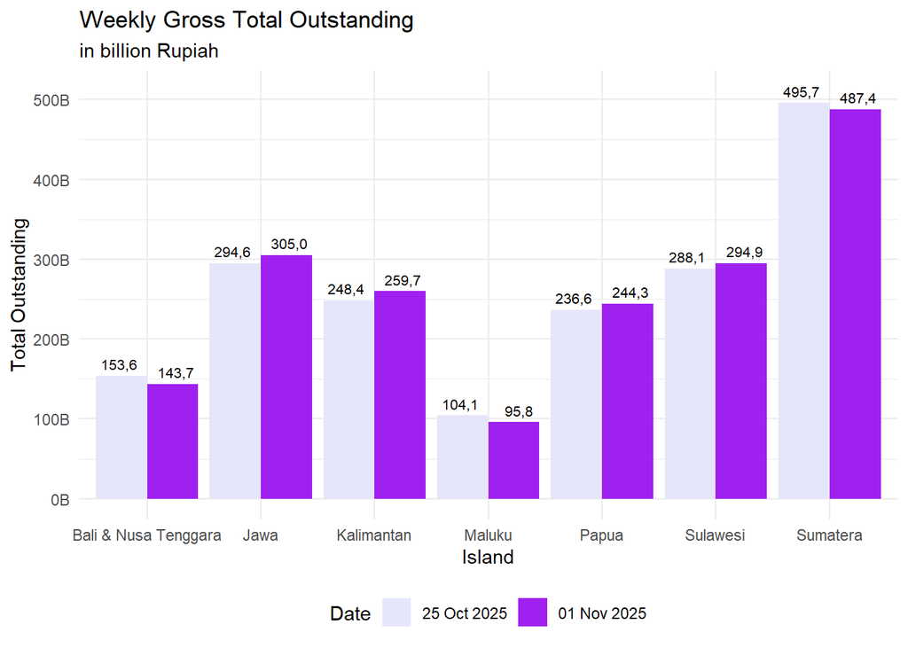

```r
# PLOT 1.1 a: Weekly Gross Total Outstanding (Current Cut-Off)
plot1.1.a <- ggplot(gross_total_outstanding, aes(x = island,
                    y = total_outstanding_amount,
                    text = label)) +

  geom_col(position = position_dodge(width = 0.9),
           aes(fill = Date)) +
  scale_y_continuous(labels = label_number(scale = 1e-9,
                                           suffix = "B",
                                           accuracy = 1)) +
  geom_text(aes(y = total_outstanding_amount + 1.5e10,
                label = format(floor(total_outstanding_amount/1e8)/10,
                                     big.mark = ".",
                                     decimal.mark = ","),
                group = Date),
            position = position_dodge(width = 1),
            size = 2.8) +
  scale_fill_manual(values= c("lavender","purple")) +
  labs(title = "Weekly Gross Total Outstanding",
       subtitle = "in billion Rupiah",
       x = "Island",
       y = "Total Outstanding",
       fill = "Date") +
  theme_minimal() +
  theme(legend.position = "bottom")

plot1.1.a
```

```r
# This is for interactive plot
# ggplotly(plot1.1.a, tooltip = "text") %>%
#   layout(title = list(text = paste0(
#       "Weekly Gross Total Outstanding",
#       "<br><sup>in billion Rupiah</sup>")),
#       legend = list(orientation = "h",
#                     y = -0.3)
#     )
```

This bar chart compares the total outstanding amounts across Indonesia’s islands for the last two weeks (**25 October 2025** and **01 November 2025**). The visualization highlights weekly financial performance trends regionally.

### PLOT 1.1.b: (bar plot)

“Gross: Weekly NPL Comparison by Island ~ Island vs NPL”

```r
# Dataset: Gross
sqllab_gross_clean
```

```
#> # A tibble: 135,420 × 11
#>    cut_off_date island region area  branch bucket   noa outstanding_amount  date
#>    <date>       <fct>  <fct>  <fct> <fct>  <fct>  <int>              <dbl> <int>
#>  1 2025-11-01   Sumat… Aceh   Aceh… Aceh … 01. C…    53          91784130.     1
#>  2 2025-11-01   Sumat… Aceh   Aceh… Aceh … 02. 1…   185         254273192.     1
#>  3 2025-11-01   Sumat… Aceh   Aceh… Aceh … 03. 3…   173         431221028.     1
#>  4 2025-11-01   Sumat… Aceh   Aceh… Aceh … 04. 6…   271        1326525315.     1
#>  5 2025-11-01   Sumat… Aceh   Aceh… Aceh … 05. 9…   119         557134482.     1
#>  6 2025-11-01   Sumat… Aceh   Aceh… Aceh … 01. C…   176         836408397.     1
#>  7 2025-11-01   Sumat… Aceh   Aceh… Aceh … 02. 1…   443         850066868.     1
#>  8 2025-11-01   Sumat… Aceh   Aceh… Aceh … 03. 3…   369        1051253334.     1
#>  9 2025-11-01   Sumat… Aceh   Aceh… Aceh … 04. 6…   386         920064468.     1
#> 10 2025-11-01   Sumat… Aceh   Aceh… Aceh … 05. 9…   148         702017007.     1
#> # ℹ 135,410 more rows
#> # ℹ 2 more variables: month <dbl>, year <dbl>
```

```r
# category in bucket
unique(sqllab_gross_clean$bucket)
```

```
#> [1] 01. Current   02. 1-30 DPD  03. 31-60 DPD 04. 61-90 DPD 05. 90+ DPD
#> Levels: 01. Current 02. 1-30 DPD 03. 31-60 DPD 04. 61-90 DPD 05. 90+ DPD
```

There are 5 bucket category in the “Gross” dataset.

In order to obtain the **NPL value**, we first need to calculate the ratio between the **total outstanding amount in the “DPD 90+” bucket** and the **overall total outstanding amount** for each cut-off date and island.

The **Non-Performing Loan (NPL)** ratio can be calculated as:
$$\text{NPL} = \frac{\text{Total Outstanding Amount (DPD
90+)}}{\text{Total Outstanding Amount (All Buckets)}}$$

To begin, we’ll calculate the total outstanding amount for loans in the **05. 90+ DPD** bucket, summarized by **cut-off date** and **island**.

```r
# Data Wrangling
# Total amount DPD 90+
gross_DPD_90 <- sqllab_gross_clean %>%
  filter(bucket == "05. 90+ DPD") %>%
  group_by(cut_off_date, island) %>%
  summarise(DPD_90 = sum(outstanding_amount)) %>%
  ungroup() %>%
  arrange(desc(cut_off_date)) %>%
  mutate(
    date = day(cut_off_date)
  )

gross_DPD_90
```

```
#> # A tibble: 427 × 4
#>    cut_off_date island                     DPD_90  date
#>    <date>       <fct>                       <dbl> <int>
#>  1 2025-11-01   Bali & Nusa Tenggara 31003030413.     1
#>  2 2025-11-01   Jawa                 64124530442.     1
#>  3 2025-11-01   Kalimantan           47065999364.     1
#>  4 2025-11-01   Maluku               21402843091.     1
#>  5 2025-11-01   Papua                55714241579.     1
#>  6 2025-11-01   Sulawesi             56068920845.     1
#>  7 2025-11-01   Sumatera             97924116601.     1
#>  8 2025-10-25   Bali & Nusa Tenggara 27586312894.    25
#>  9 2025-10-25   Jawa                 56433908115.    25
#> 10 2025-10-25   Kalimantan           53046595012.    25
#> # ℹ 417 more rows
```

Next, we’ll calculate the total outstanding amount for each **cut-off date** and **island** across **all DPD buckets**.

```r
# Data Wrangling 2
# Total Outstanding 2
gross_total_outstanding2 <- sqllab_gross_clean %>%
  group_by(cut_off_date, island) %>%
  summarise(total_outstanding_amount= sum(outstanding_amount)) %>%
  ungroup() %>%
  arrange(desc(cut_off_date)) %>%
  mutate(
    date = day(cut_off_date)
  )

gross_total_outstanding2
```

```
#> # A tibble: 427 × 4
#>    cut_off_date island               total_outstanding_amount  date
#>    <date>       <fct>                                   <dbl> <int>
#>  1 2025-11-01   Bali & Nusa Tenggara            143791078634.     1
#>  2 2025-11-01   Jawa                            305058385753.     1
#>  3 2025-11-01   Kalimantan                      259755858198.     1
#>  4 2025-11-01   Maluku                           95847719915.     1
#>  5 2025-11-01   Papua                           244322416284.     1
#>  6 2025-11-01   Sulawesi                        294961035802.     1
#>  7 2025-11-01   Sumatera                        487478246847.     1
#>  8 2025-10-25   Bali & Nusa Tenggara            153656464025.    25
#>  9 2025-10-25   Jawa                            294687968540.    25
#> 10 2025-10-25   Kalimantan                      248424159664.    25
#> # ℹ 417 more rows
```

Next, we’ll merge the datasets containing the **DPD 90+ outstanding amount** and the **total outstanding amount** into a single dataframe, allowing us to **calculate the NPL** ratio for each cut-off date and island.

```r
# Merge DPD 90+ outstanding amount with total outstanding amount to calculate current NPL
gross_NPL_Current <- gross_DPD_90 %>%
  inner_join(gross_total_outstanding2, by = c("cut_off_date", "island")) %>%
  mutate(
    NPL = round((DPD_90 / total_outstanding_amount * 100),2),
    Date = factor(
      format(cut_off_date, "%d %b %Y"),
      levels = format(sort(unique(cut_off_date)),"%d %b %Y"))
  ) %>%
  select (-c(date.x, date.y)) %>%
  arrange(desc(cut_off_date)) %>%
  filter(cut_off_date <= "2025-11-01") %>%
  head(14) # this and last week

gross_NPL_Current
```

```
#> # A tibble: 14 × 6
#>    cut_off_date island                 DPD_90 total_outstanding_am…¹   NPL Date
#>    <date>       <fct>                   <dbl>                  <dbl> <dbl> <fct>
#>  1 2025-11-01   Bali & Nusa Tenggara  3.10e10          143791078634.  21.6 01 N…
#>  2 2025-11-01   Jawa                  6.41e10          305058385753.  21.0 01 N…
#>  3 2025-11-01   Kalimantan            4.71e10          259755858198.  18.1 01 N…
#>  4 2025-11-01   Maluku                2.14e10           95847719915.  22.3 01 N…
#>  5 2025-11-01   Papua                 5.57e10          244322416284.  22.8 01 N…
#>  6 2025-11-01   Sulawesi              5.61e10          294961035802.  19.0 01 N…
#>  7 2025-11-01   Sumatera              9.79e10          487478246847.  20.1 01 N…
#>  8 2025-10-25   Bali & Nusa Tenggara  2.76e10          153656464025.  18.0 25 O…
#>  9 2025-10-25   Jawa                  5.64e10          294687968540.  19.2 25 O…
#> 10 2025-10-25   Kalimantan            5.30e10          248424159664.  21.4 25 O…
#> 11 2025-10-25   Maluku                2.10e10          104190643257.  20.2 25 O…
#> 12 2025-10-25   Papua                 4.85e10          236608492865.  20.5 25 O…
#> 13 2025-10-25   Sulawesi              5.69e10          288169823468.  19.7 25 O…
#> 14 2025-10-25   Sumatera              9.99e10          495701974100.  20.1 25 O…
#> # ℹ abbreviated name: ¹total_outstanding_amount
```

```r
# tooltip
gross_NPL_Current <- gross_NPL_Current %>%
  mutate(
    label = glue(
      "NPL: {number(NPL,  big.mark = '.', decimal.mark = ',', accuracy = 0.01)}%
      Cut Off Date: {format(as.Date(cut_off_date), '%d %b %Y')}"
    )
  )
gross_NPL_Current
```

```
#> # A tibble: 14 × 7
#>    cut_off_date island           DPD_90 total_outstanding_am…¹   NPL Date  label
#>    <date>       <fct>             <dbl>                  <dbl> <dbl> <fct> <glu>
#>  1 2025-11-01   Bali & Nusa Te… 3.10e10          143791078634.  21.6 01 N… NPL:…
#>  2 2025-11-01   Jawa            6.41e10          305058385753.  21.0 01 N… NPL:…
#>  3 2025-11-01   Kalimantan      4.71e10          259755858198.  18.1 01 N… NPL:…
#>  4 2025-11-01   Maluku          2.14e10           95847719915.  22.3 01 N… NPL:…
#>  5 2025-11-01   Papua           5.57e10          244322416284.  22.8 01 N… NPL:…
#>  6 2025-11-01   Sulawesi        5.61e10          294961035802.  19.0 01 N… NPL:…
#>  7 2025-11-01   Sumatera        9.79e10          487478246847.  20.1 01 N… NPL:…
#>  8 2025-10-25   Bali & Nusa Te… 2.76e10          153656464025.  18.0 25 O… NPL:…
#>  9 2025-10-25   Jawa            5.64e10          294687968540.  19.2 25 O… NPL:…
#> 10 2025-10-25   Kalimantan      5.30e10          248424159664.  21.4 25 O… NPL:…
#> 11 2025-10-25   Maluku          2.10e10          104190643257.  20.2 25 O… NPL:…
#> 12 2025-10-25   Papua           4.85e10          236608492865.  20.5 25 O… NPL:…
#> 13 2025-10-25   Sulawesi        5.69e10          288169823468.  19.7 25 O… NPL:…
#> 14 2025-10-25   Sumatera        9.99e10          495701974100.  20.1 25 O… NPL:…
#> # ℹ abbreviated name: ¹total_outstanding_amount
```

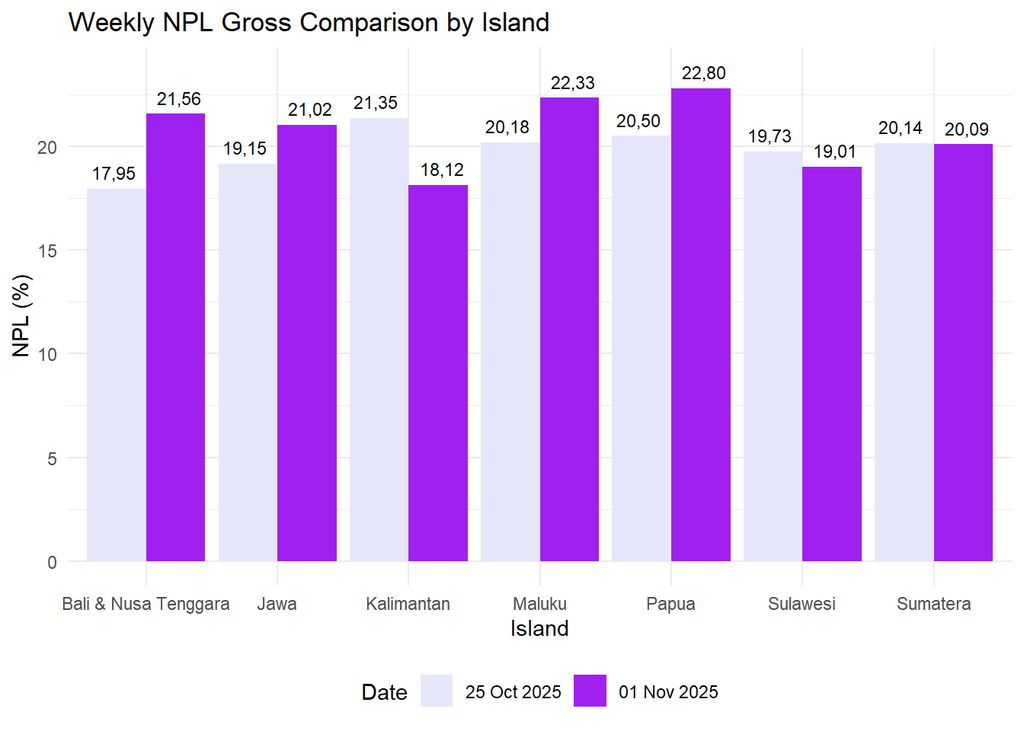

```r
# PLOT 1.1.b: NPL Comparison by Island
plot1.1.b <- ggplot(gross_NPL_Current, aes(x = island,
                    y = NPL,
                    text = label)) +

  geom_col(position = position_dodge(width = 0.9),
           aes(fill = Date)) +
  geom_text(aes(y = NPL + 0.8,
                label = label_number(big.mark = ".",
                                     decimal.mark = ",",
                                     accuracy = 0.01)
                (NPL),
                group = Date),
            position = position_dodge(width = 1),
            size = 3.0) +
  scale_fill_manual(values= c("lavender", "purple")) +
  labs(title = "Weekly NPL Gross Comparison by Island",
       x = "Island",
       y = "NPL (%)") +
  theme_minimal() +
  theme(legend.position = "bottom")

plot1.1.b
```

```r
# This is for interactive plot
# ggplotly(plot1.1.b, tooltip = "text") %>%
#   layout(legend = list(orientation = "h",
#                        y = -0.3))
```

This bar chart illustrates the **weekly change in NPL (Non-Performing Loan) Gross percentage** across Indonesia’s islands for **25 October 2025** and **01 November 2025**. The visualization captures how the credit quality shifts regionally over time.

- **Papua** records the **highest NPL levels**, increasing slightly from **20.50%** to **22.80%**.
- **Maluku** also shows a noticeable rise, moving from **20.18%** to **22.33%**.
- **Kalimantan** stands out with the biggest **decline** from **21.35%** to **18.12%**, suggesting improved credit performance.

## Line 2 (Overview Net)

### PLOT 1.2.a: (bar plot)

“Net: Total Outstanding (Current Cut-Off) ~ Pulau vs nilai outstanding amount”

```r
# Dataset: Net
sqllab_net_clean
```

```
#> # A tibble: 135,420 × 11
#>    cut_off_date island region area  branch bucket   noa outstanding_amount  date
#>    <date>       <fct>  <fct>  <fct> <fct>  <fct>  <int>              <dbl> <int>
#>  1 2025-11-01   Sumat… Aceh   Aceh… Aceh … 01. C…    53          76934000.     1
#>  2 2025-11-01   Sumat… Aceh   Aceh… Aceh … 02. 1…   185         218410473.     1
#>  3 2025-11-01   Sumat… Aceh   Aceh… Aceh … 03. 3…   173         317760703.     1
#>  4 2025-11-01   Sumat… Aceh   Aceh… Aceh … 04. 6…   271         811554170.     1
#>  5 2025-11-01   Sumat… Aceh   Aceh… Aceh … 05. 9…   119         271330064.     1
#>  6 2025-11-01   Sumat… Aceh   Aceh… Aceh … 01. C…   176         581834603.     1
#>  7 2025-11-01   Sumat… Aceh   Aceh… Aceh … 02. 1…   443         748995851.     1
#>  8 2025-11-01   Sumat… Aceh   Aceh… Aceh … 03. 3…   369         877552083.     1
#>  9 2025-11-01   Sumat… Aceh   Aceh… Aceh … 04. 6…   386         558000043.     1
#> 10 2025-11-01   Sumat… Aceh   Aceh… Aceh … 05. 9…   148         335235117.     1
#> # ℹ 135,410 more rows
#> # ℹ 2 more variables: month <dbl>, year <dbl>
```

```r
# Data Wrangling
net_total_outstanding <- sqllab_net_clean %>%
  filter(cut_off_date <= "2025-11-01") %>%
  group_by(cut_off_date, island) %>%
  summarise(total_outstanding_amount= sum(outstanding_amount)) %>%
  ungroup() %>%
  arrange(desc(cut_off_date)) %>%
  mutate(
    Date = factor(
      format(cut_off_date, "%d %b %Y"),
      levels = format(sort(unique(cut_off_date)),"%d %b %Y"))
  ) %>%
  head(14) # this and last week

net_total_outstanding
```

```
#> # A tibble: 14 × 4
#>    cut_off_date island               total_outstanding_amount Date
#>    <date>       <fct>                                   <dbl> <fct>
#>  1 2025-11-01   Bali & Nusa Tenggara             95070042667. 01 Nov 2025
#>  2 2025-11-01   Jawa                            205579088033. 01 Nov 2025
#>  3 2025-11-01   Kalimantan                      176411648216. 01 Nov 2025
#>  4 2025-11-01   Maluku                           64200464734. 01 Nov 2025
#>  5 2025-11-01   Papua                           159773648683. 01 Nov 2025
#>  6 2025-11-01   Sulawesi                        199024648131. 01 Nov 2025
#>  7 2025-11-01   Sumatera                        327494137949. 01 Nov 2025
#>  8 2025-10-25   Bali & Nusa Tenggara            104033344709. 25 Oct 2025
#>  9 2025-10-25   Jawa                            198472628731. 25 Oct 2025
#> 10 2025-10-25   Kalimantan                      167940849035. 25 Oct 2025
#> 11 2025-10-25   Maluku                           69862251215. 25 Oct 2025
#> 12 2025-10-25   Papua                           157465762086. 25 Oct 2025
#> 13 2025-10-25   Sulawesi                        193968983299. 25 Oct 2025
#> 14 2025-10-25   Sumatera                        333485371118. 25 Oct 2025
```

```r
# tooltip
net_total_outstanding <- net_total_outstanding %>%
  mutate(
    label = glue(
      "Total Oustanding:IDR {number(total_outstanding_amount, big.mark = '.', decimal.mark = ',', accuracy = 1)}
      Cut Off Date: {format(as.Date(cut_off_date), '%d %b %Y')}"
    )
  )
net_total_outstanding
```

```
#> # A tibble: 14 × 5
#>    cut_off_date island               total_outstanding_amount Date        label
#>    <date>       <fct>                                   <dbl> <fct>       <glue>
#>  1 2025-11-01   Bali & Nusa Tenggara             95070042667. 01 Nov 2025 Total…
#>  2 2025-11-01   Jawa                            205579088033. 01 Nov 2025 Total…
#>  3 2025-11-01   Kalimantan                      176411648216. 01 Nov 2025 Total…
#>  4 2025-11-01   Maluku                           64200464734. 01 Nov 2025 Total…
#>  5 2025-11-01   Papua                           159773648683. 01 Nov 2025 Total…
#>  6 2025-11-01   Sulawesi                        199024648131. 01 Nov 2025 Total…
#>  7 2025-11-01   Sumatera                        327494137949. 01 Nov 2025 Total…
#>  8 2025-10-25   Bali & Nusa Tenggara            104033344709. 25 Oct 2025 Total…
#>  9 2025-10-25   Jawa                            198472628731. 25 Oct 2025 Total…
#> 10 2025-10-25   Kalimantan                      167940849035. 25 Oct 2025 Total…
#> 11 2025-10-25   Maluku                           69862251215. 25 Oct 2025 Total…
#> 12 2025-10-25   Papua                           157465762086. 25 Oct 2025 Total…
#> 13 2025-10-25   Sulawesi                        193968983299. 25 Oct 2025 Total…
#> 14 2025-10-25   Sumatera                        333485371118. 25 Oct 2025 Total…
```

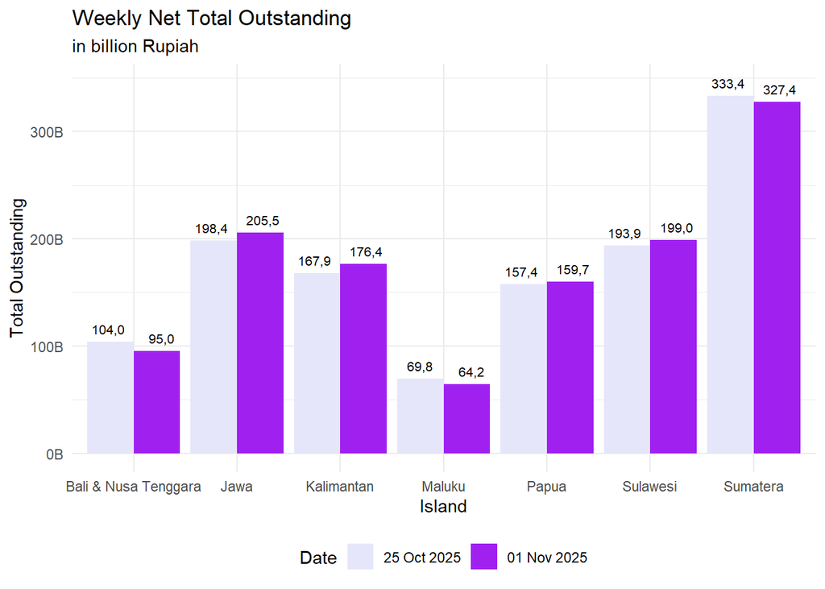

```r
# PLOT 1.2.a: Weekly Net Total Outstanding (Current Cut-Off)
plot1.2.a <- ggplot(net_total_outstanding, aes(x = island,
                    y = total_outstanding_amount,
                    text = label)) +

  geom_col(position = position_dodge(width = 0.9),
           aes(fill = Date)) +
  scale_y_continuous(labels = label_number(scale = 1e-9,
                                           suffix = "B",
                                           accuracy = 1)) +
  geom_text(aes(y = total_outstanding_amount + 1.2e10,
                label = format(floor(total_outstanding_amount/1e8)/10,
                                     big.mark = ".",
                                     decimal.mark = ","),
                group = Date),
            position = position_dodge(width = 1),
            size = 2.8) +
  scale_fill_manual(values= c("lavender","purple")) +
  labs(title = "Weekly Net Total Outstanding",
       subtitle = "in billion Rupiah",
       x = "Island",
       y = "Total Outstanding",
       fill = "Date") +
  theme_minimal() +
  theme(legend.position = "bottom")

plot1.2.a
```

```r
# This is for interactive plot
# ggplotly(plot1.2.a, tooltip = "text") %>%
#   layout(title = list(text = paste0(
#       "Weekly Net Total Outstanding",
#       "<br><sup>in billion Rupiah</sup>")),
#       legend = list(orientation = "h",
#                     y = -0.3)
#     )
```

The bar chart above shows the **Weekly Net Total Outstanding** across **seven islands** in Indonesia, comparing values between **25 Oct 2025** and **01 Nov 2025**.

- Overall, **Jawa** and **Sumatera** maintain the highest total outstanding amounts, while **Maluku** consistently records the lowest.
- Most islands show relatively stable values, with slight decreases observed in **Bali & Nusa Tenggara** and **Sumatera**, and small increases in **Jawa**, **Sulawesi**, and **Papua**.

### PLOT 1.2.b: (bar plot)

“Net: Weekly NPL Comparison by Island ~ Island vs NPL”

```r
# Dataset: Net
sqllab_net_clean
```

```
#> # A tibble: 135,420 × 11
#>    cut_off_date island region area  branch bucket   noa outstanding_amount  date
#>    <date>       <fct>  <fct>  <fct> <fct>  <fct>  <int>              <dbl> <int>
#>  1 2025-11-01   Sumat… Aceh   Aceh… Aceh … 01. C…    53          76934000.     1
#>  2 2025-11-01   Sumat… Aceh   Aceh… Aceh … 02. 1…   185         218410473.     1
#>  3 2025-11-01   Sumat… Aceh   Aceh… Aceh … 03. 3…   173         317760703.     1
#>  4 2025-11-01   Sumat… Aceh   Aceh… Aceh … 04. 6…   271         811554170.     1
#>  5 2025-11-01   Sumat… Aceh   Aceh… Aceh … 05. 9…   119         271330064.     1
#>  6 2025-11-01   Sumat… Aceh   Aceh… Aceh … 01. C…   176         581834603.     1
#>  7 2025-11-01   Sumat… Aceh   Aceh… Aceh … 02. 1…   443         748995851.     1
#>  8 2025-11-01   Sumat… Aceh   Aceh… Aceh … 03. 3…   369         877552083.     1
#>  9 2025-11-01   Sumat… Aceh   Aceh… Aceh … 04. 6…   386         558000043.     1
#> 10 2025-11-01   Sumat… Aceh   Aceh… Aceh … 05. 9…   148         335235117.     1
#> # ℹ 135,410 more rows
#> # ℹ 2 more variables: month <dbl>, year <dbl>
```

```r
# category in bucket
unique(sqllab_net_clean$bucket)
```

```
#> [1] 01. Current   02. 1-30 DPD  03. 31-60 DPD 04. 61-90 DPD 05. 90+ DPD
#> Levels: 01. Current 02. 1-30 DPD 03. 31-60 DPD 04. 61-90 DPD 05. 90+ DPD
```

There are 5 bucket category in the “Net” dataset. Just like the Gross NPL plot, we now need to calculate the Net NPL by obtaining the **total outstanding amount in the “DPD 90+”** bucket and the **overall total outstanding amount** for each cut-off date and island.

The key difference between **NPL Gross** and **NPL Net** is that the latter **excludes Write-Off (WO)** values. These values will then be used to derive the **Net NPL percentage**.

```r
# Data Wrangling
# Total amount DPD 90+
net_DPD_90 <- sqllab_net_clean %>%
  filter(bucket == "05. 90+ DPD") %>%
  group_by(cut_off_date, island) %>%
  summarise(DPD_90 = sum(outstanding_amount)) %>%
  ungroup() %>%
  arrange(desc(cut_off_date)) %>%
  mutate(
    date = day(cut_off_date)
  )

net_DPD_90
```

```
#> # A tibble: 427 × 4
#>    cut_off_date island                     DPD_90  date
#>    <date>       <fct>                       <dbl> <int>
#>  1 2025-11-01   Bali & Nusa Tenggara 10962829834.     1
#>  2 2025-11-01   Jawa                 22503499617.     1
#>  3 2025-11-01   Kalimantan           15959716160.     1
#>  4 2025-11-01   Maluku                7596672396.     1
#>  5 2025-11-01   Papua                18630620970.     1
#>  6 2025-11-01   Sulawesi             20494808363.     1
#>  7 2025-11-01   Sumatera             35463611319.     1
#>  8 2025-10-25   Bali & Nusa Tenggara  9950603569.    25
#>  9 2025-10-25   Jawa                 21248316932.    25
#> 10 2025-10-25   Kalimantan           18613065059.    25
#> # ℹ 417 more rows
```

```r
# Data Wrangling 2
# Total Outstanding 2
net_total_outstanding2 <- sqllab_net_clean %>%
  group_by(cut_off_date, island) %>%
  summarise(total_outstanding_amount= sum(outstanding_amount)) %>%
  ungroup() %>%
  arrange(desc(cut_off_date)) %>%
  mutate(
    date = day(cut_off_date)
  )

net_total_outstanding2
```

```
#> # A tibble: 427 × 4
#>    cut_off_date island               total_outstanding_amount  date
#>    <date>       <fct>                                   <dbl> <int>
#>  1 2025-11-01   Bali & Nusa Tenggara             95070042667.     1
#>  2 2025-11-01   Jawa                            205579088033.     1
#>  3 2025-11-01   Kalimantan                      176411648216.     1
#>  4 2025-11-01   Maluku                           64200464734.     1
#>  5 2025-11-01   Papua                           159773648683.     1
#>  6 2025-11-01   Sulawesi                        199024648131.     1
#>  7 2025-11-01   Sumatera                        327494137949.     1
#>  8 2025-10-25   Bali & Nusa Tenggara            104033344709.    25
#>  9 2025-10-25   Jawa                            198472628731.    25
#> 10 2025-10-25   Kalimantan                      167940849035.    25
#> # ℹ 417 more rows
```

```r
# Merge DPD 90+ outstanding amount with total outstanding amount to calculate current NPL
net_NPL_Current <- net_DPD_90 %>%
  inner_join(net_total_outstanding2, by = c("cut_off_date", "island")) %>%
  mutate(
    NPL = round((DPD_90 / total_outstanding_amount * 100),2),
    Date = factor(
      format(cut_off_date, "%d %b %Y"),
      levels = format(sort(unique(cut_off_date)),"%d %b %Y"))
  ) %>%
  select (-c(date.x, date.y)) %>%
  arrange(desc(cut_off_date)) %>%
  filter(cut_off_date <= "2025-11-01") %>%
  head(14) # this and last week

net_NPL_Current
```

```
#> # A tibble: 14 × 6
#>    cut_off_date island                 DPD_90 total_outstanding_am…¹   NPL Date
#>    <date>       <fct>                   <dbl>                  <dbl> <dbl> <fct>
#>  1 2025-11-01   Bali & Nusa Tenggara  1.10e10           95070042667. 11.5  01 N…
#>  2 2025-11-01   Jawa                  2.25e10          205579088033. 11.0  01 N…
#>  3 2025-11-01   Kalimantan            1.60e10          176411648216.  9.05 01 N…
#>  4 2025-11-01   Maluku                7.60e 9           64200464734. 11.8  01 N…
#>  5 2025-11-01   Papua                 1.86e10          159773648683. 11.7  01 N…
#>  6 2025-11-01   Sulawesi              2.05e10          199024648131. 10.3  01 N…
#>  7 2025-11-01   Sumatera              3.55e10          327494137949. 10.8  01 N…
#>  8 2025-10-25   Bali & Nusa Tenggara  9.95e 9          104033344709.  9.56 25 O…
#>  9 2025-10-25   Jawa                  2.12e10          198472628731. 10.7  25 O…
#> 10 2025-10-25   Kalimantan            1.86e10          167940849035. 11.1  25 O…
#> 11 2025-10-25   Maluku                6.68e 9           69862251215.  9.57 25 O…
#> 12 2025-10-25   Papua                 1.68e10          157465762086. 10.7  25 O…
#> 13 2025-10-25   Sulawesi              2.08e10          193968983299. 10.7  25 O…
#> 14 2025-10-25   Sumatera              3.44e10          333485371118. 10.3  25 O…
#> # ℹ abbreviated name: ¹total_outstanding_amount
```

```r
# tooltip
net_NPL_Current <- net_NPL_Current %>%
  mutate(
    label = glue(
      "NPL: {number(NPL,  big.mark = '.', decimal.mark = ',', accuracy = 0.01)}%
      Cut Off Date: {format(as.Date(cut_off_date), '%d %b %Y')}"
    )
  )
net_NPL_Current
```

```
#> # A tibble: 14 × 7
#>    cut_off_date island           DPD_90 total_outstanding_am…¹   NPL Date  label
#>    <date>       <fct>             <dbl>                  <dbl> <dbl> <fct> <glu>
#>  1 2025-11-01   Bali & Nusa Te… 1.10e10           95070042667. 11.5  01 N… NPL:…
#>  2 2025-11-01   Jawa            2.25e10          205579088033. 11.0  01 N… NPL:…
#>  3 2025-11-01   Kalimantan      1.60e10          176411648216.  9.05 01 N… NPL:…
#>  4 2025-11-01   Maluku          7.60e 9           64200464734. 11.8  01 N… NPL:…
#>  5 2025-11-01   Papua           1.86e10          159773648683. 11.7  01 N… NPL:…
#>  6 2025-11-01   Sulawesi        2.05e10          199024648131. 10.3  01 N… NPL:…
#>  7 2025-11-01   Sumatera        3.55e10          327494137949. 10.8  01 N… NPL:…
#>  8 2025-10-25   Bali & Nusa Te… 9.95e 9          104033344709.  9.56 25 O… NPL:…
#>  9 2025-10-25   Jawa            2.12e10          198472628731. 10.7  25 O… NPL:…
#> 10 2025-10-25   Kalimantan      1.86e10          167940849035. 11.1  25 O… NPL:…
#> 11 2025-10-25   Maluku          6.68e 9           69862251215.  9.57 25 O… NPL:…
#> 12 2025-10-25   Papua           1.68e10          157465762086. 10.7  25 O… NPL:…
#> 13 2025-10-25   Sulawesi        2.08e10          193968983299. 10.7  25 O… NPL:…
#> 14 2025-10-25   Sumatera        3.44e10          333485371118. 10.3  25 O… NPL:…
#> # ℹ abbreviated name: ¹total_outstanding_amount
```

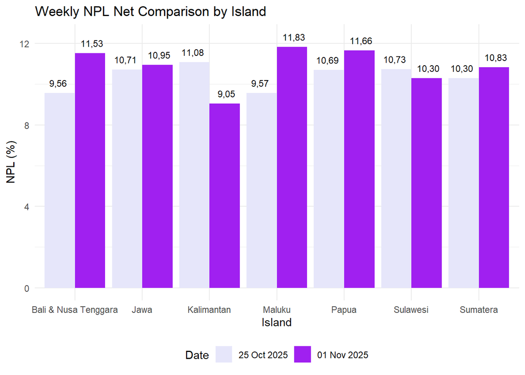

```r
# PLOT 1.2.b: NPL Comparison by Island
plot1.2.b <- ggplot(net_NPL_Current, aes(x = island,
                    y = NPL,
                    text = label)) +

  geom_col(position = position_dodge(width = 0.9),
           aes(fill = Date)) +
  geom_text(aes(y = NPL + 0.5,
                label = label_number(big.mark = ".",
                                     decimal.mark = ",",
                                     accuracy = 0.01)
                (NPL),
                group = Date),
            position = position_dodge(width = 1),
            size = 3.0) +
  scale_fill_manual(values= c("lavender", "purple")) +
  labs(title = "Weekly NPL Net Comparison by Island",
       x = "Island",
       y = "NPL (%)") +
  theme_minimal() +
  theme(legend.position = "bottom")

plot1.2.b
```

```r
# This is for interactive plot
# ggplotly(plot1.2.b, tooltip = "text") %>%
#   layout(legend = list(orientation = "h",
#                        y = -0.3))
```

The bar chart above illustrates the **Weekly NPL Net Comparison by Island**, showing changes in **NPL (%)** between **25 Oct 2025** and **01 Nov 2025**.

## Line 3 (Overview External)

### PLOT 1.3.a: (bar plot)

“External: Weekly Total Outstanding ~ Island vs Total Outstanding Amount”

```r
# Dataset: External
sqllab_external_clean
```

```
#> # A tibble: 135,420 × 11
#>    cut_off_date island region area  branch bucket   noa outstanding_amount  date
#>    <date>       <fct>  <fct>  <fct> <fct>  <fct>  <int>              <dbl> <int>
#>  1 2025-11-01   Sumat… Aceh   Aceh… Aceh … 01. C…    53          64398309.     1
#>  2 2025-11-01   Sumat… Aceh   Aceh… Aceh … 02. 1…   185         206470008.     1
#>  3 2025-11-01   Sumat… Aceh   Aceh… Aceh … 03. 3…   173         231682208.     1
#>  4 2025-11-01   Sumat… Aceh   Aceh… Aceh … 04. 6…   271         648403168.     1
#>  5 2025-11-01   Sumat… Aceh   Aceh… Aceh … 05. 9…   119          50133476.     1
#>  6 2025-11-01   Sumat… Aceh   Aceh… Aceh … 01. C…   176         458579814.     1
#>  7 2025-11-01   Sumat… Aceh   Aceh… Aceh … 02. 1…   443         553795359.     1
#>  8 2025-11-01   Sumat… Aceh   Aceh… Aceh … 03. 3…   369         827679983.     1
#>  9 2025-11-01   Sumat… Aceh   Aceh… Aceh … 04. 6…   386         511141034.     1
#> 10 2025-11-01   Sumat… Aceh   Aceh… Aceh … 05. 9…   148          47998959.     1
#> # ℹ 135,410 more rows
#> # ℹ 2 more variables: month <dbl>, year <dbl>
```

```r
# Data Wrangling
external_total_outstanding <- sqllab_external_clean %>%
  filter(cut_off_date <= "2025-11-01") %>%
  group_by(cut_off_date, island) %>%
  summarise(total_outstanding_amount= sum(outstanding_amount)) %>%
  ungroup() %>%
  arrange(desc(cut_off_date)) %>%
  mutate(
    Date = factor(
      format(cut_off_date, "%d %b %Y"),
      levels = format(sort(unique(cut_off_date)),"%d %b %Y"))
  ) %>%
  head(14) # this and last week

external_total_outstanding
```

```
#> # A tibble: 14 × 4
#>    cut_off_date island               total_outstanding_amount Date
#>    <date>       <fct>                                   <dbl> <fct>
#>  1 2025-11-01   Bali & Nusa Tenggara             71226252420. 01 Nov 2025
#>  2 2025-11-01   Jawa                            156117687350. 01 Nov 2025
#>  3 2025-11-01   Kalimantan                      135307784341. 01 Nov 2025
#>  4 2025-11-01   Maluku                           49013872412. 01 Nov 2025
#>  5 2025-11-01   Papua                           120467879306. 01 Nov 2025
#>  6 2025-11-01   Sulawesi                        151287046551. 01 Nov 2025
#>  7 2025-11-01   Sumatera                        245719756420. 01 Nov 2025
#>  8 2025-10-25   Bali & Nusa Tenggara             79929170711. 25 Oct 2025
#>  9 2025-10-25   Jawa                            149145882346. 25 Oct 2025
#> 10 2025-10-25   Kalimantan                      127755024506. 25 Oct 2025
#> 11 2025-10-25   Maluku                           54843305702. 25 Oct 2025
#> 12 2025-10-25   Papua                           119965198231. 25 Oct 2025
#> 13 2025-10-25   Sulawesi                        146770759955. 25 Oct 2025
#> 14 2025-10-25   Sumatera                        253752951291. 25 Oct 2025
```

```r
# tooltip
external_total_outstanding <- external_total_outstanding %>%
  mutate(
    label = glue(
      "Total Oustanding:IDR {number(total_outstanding_amount, big.mark = '.', decimal.mark = ',', accuracy = 1)}
      Cut Off Date: {format(as.Date(cut_off_date), '%d %b %Y')}"
    )
  )
external_total_outstanding
```

```
#> # A tibble: 14 × 5
#>    cut_off_date island               total_outstanding_amount Date        label
#>    <date>       <fct>                                   <dbl> <fct>       <glue>
#>  1 2025-11-01   Bali & Nusa Tenggara             71226252420. 01 Nov 2025 Total…
#>  2 2025-11-01   Jawa                            156117687350. 01 Nov 2025 Total…
#>  3 2025-11-01   Kalimantan                      135307784341. 01 Nov 2025 Total…
#>  4 2025-11-01   Maluku                           49013872412. 01 Nov 2025 Total…
#>  5 2025-11-01   Papua                           120467879306. 01 Nov 2025 Total…
#>  6 2025-11-01   Sulawesi                        151287046551. 01 Nov 2025 Total…
#>  7 2025-11-01   Sumatera                        245719756420. 01 Nov 2025 Total…
#>  8 2025-10-25   Bali & Nusa Tenggara             79929170711. 25 Oct 2025 Total…
#>  9 2025-10-25   Jawa                            149145882346. 25 Oct 2025 Total…
#> 10 2025-10-25   Kalimantan                      127755024506. 25 Oct 2025 Total…
#> 11 2025-10-25   Maluku                           54843305702. 25 Oct 2025 Total…
#> 12 2025-10-25   Papua                           119965198231. 25 Oct 2025 Total…
#> 13 2025-10-25   Sulawesi                        146770759955. 25 Oct 2025 Total…
#> 14 2025-10-25   Sumatera                        253752951291. 25 Oct 2025 Total…
```

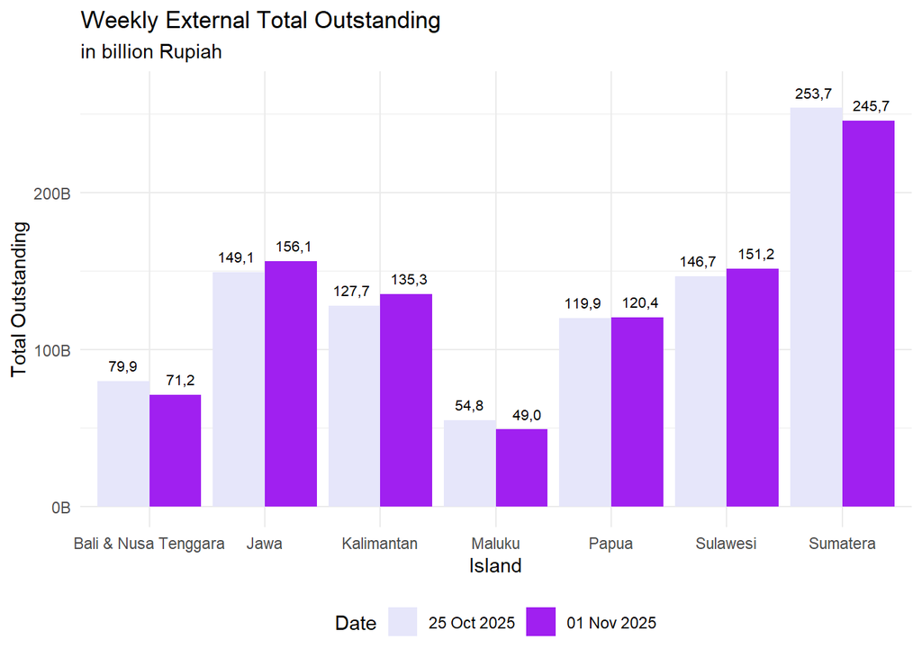

```r
# PLOT 1.3 a: Weekly Gross Total Outstanding (Current Cut-Off)
plot1.3.a <- ggplot(external_total_outstanding, aes(x = island,
                    y = total_outstanding_amount,
                    text = label)) +

  geom_col(position = position_dodge(width = 0.9),
           aes(fill = Date)) +
  scale_y_continuous(labels = label_number(scale = 1e-9,
                                           suffix = "B",
                                           accuracy = 1)) +
  geom_text(aes(y = total_outstanding_amount + 1e10,
                label = format(floor(total_outstanding_amount/1e8)/10,
                                     big.mark = ".",
                                     decimal.mark = ","),
                group = Date),
            position = position_dodge(width = 1),
            size = 2.8) +
  scale_fill_manual(values= c("lavender","purple")) +
  labs(title = "Weekly External Total Outstanding",
       subtitle = "in billion Rupiah",
       x = "Island",
       y = "Total Outstanding",
       fill = "Date") +
  theme_minimal() +
  theme(legend.position = "bottom")

plot1.3.a
```

```r
# This is for interactive plot
# ggplotly(plot1.3.a, tooltip = "text") %>%
#   layout(title = list(text = paste0(
#       "Weekly External Total Outstanding",
#       "<br><sup>in billion Rupiah</sup>")),
#       legend = list(orientation = "h",
#                     y = -0.3)
#     )
```

The chart above illustrates the **Weekly External Total Outstanding** across **different islands**, measured in **billion Rupiah**.

- The comparison between **25 Oct 2025** and **01 Nov 2025** shows relatively stable trends overall, with slight increases observed in **Jawa**, **Kalimantan**, and **Sulawesi**.
- While **Bali & Nusa Tenggara**, **Maluku**, and **Sumatera** experience minor decreases in total outstanding amounts.

### PLOT 1.3.b: (bar plot)

“External: Weekly NPL Comparison by Island ~ Island vs NPL”

```r
# Dataset: External
sqllab_external_clean
```

```
#> # A tibble: 135,420 × 11
#>    cut_off_date island region area  branch bucket   noa outstanding_amount  date
#>    <date>       <fct>  <fct>  <fct> <fct>  <fct>  <int>              <dbl> <int>
#>  1 2025-11-01   Sumat… Aceh   Aceh… Aceh … 01. C…    53          64398309.     1
#>  2 2025-11-01   Sumat… Aceh   Aceh… Aceh … 02. 1…   185         206470008.     1
#>  3 2025-11-01   Sumat… Aceh   Aceh… Aceh … 03. 3…   173         231682208.     1
#>  4 2025-11-01   Sumat… Aceh   Aceh… Aceh … 04. 6…   271         648403168.     1
#>  5 2025-11-01   Sumat… Aceh   Aceh… Aceh … 05. 9…   119          50133476.     1
#>  6 2025-11-01   Sumat… Aceh   Aceh… Aceh … 01. C…   176         458579814.     1
#>  7 2025-11-01   Sumat… Aceh   Aceh… Aceh … 02. 1…   443         553795359.     1
#>  8 2025-11-01   Sumat… Aceh   Aceh… Aceh … 03. 3…   369         827679983.     1
#>  9 2025-11-01   Sumat… Aceh   Aceh… Aceh … 04. 6…   386         511141034.     1
#> 10 2025-11-01   Sumat… Aceh   Aceh… Aceh … 05. 9…   148          47998959.     1
#> # ℹ 135,410 more rows
#> # ℹ 2 more variables: month <dbl>, year <dbl>
```

```r
# category in bucket
unique(sqllab_external_clean$bucket)
```

```
#> [1] 01. Current   02. 1-30 DPD  03. 31-60 DPD 04. 61-90 DPD 05. 90+ DPD
#> Levels: 01. Current 02. 1-30 DPD 03. 31-60 DPD 04. 61-90 DPD 05. 90+ DPD
```

There are 5 bucket category in the “External” dataset.

We now need to calculate the External NPL by obtaining the **total outstanding amount in the “DPD 90+”** bucket and the **overall total outstanding amount** for each cut-off date and island.

The main distinction between **NPL Gross** and **NPL External** is that the latter **excludes both Write-Off (WO) values and Eligible Claim Insurance**. These figures will then be used to derive the **External NPL percentage**.

```r
# Data Wrangling
# Total amount DPD 90+
external_DPD_90 <- sqllab_external_clean %>%
  filter(bucket == "05. 90+ DPD") %>%
  group_by(cut_off_date, island) %>%
  summarise(DPD_90 = sum(outstanding_amount)) %>%
  ungroup() %>%
  arrange(desc(cut_off_date)) %>%
  mutate(
    date = day(cut_off_date)
  )

external_DPD_90
```

```
#> # A tibble: 427 × 4
#>    cut_off_date island                    DPD_90  date
#>    <date>       <fct>                      <dbl> <int>
#>  1 2025-11-01   Bali & Nusa Tenggara 2306183060.     1
#>  2 2025-11-01   Jawa                 4678951964.     1
#>  3 2025-11-01   Kalimantan           3150806736.     1
#>  4 2025-11-01   Maluku               1435651017.     1
#>  5 2025-11-01   Papua                3649461770.     1
#>  6 2025-11-01   Sulawesi             4164370184.     1
#>  7 2025-11-01   Sumatera             6808339308.     1
#>  8 2025-10-25   Bali & Nusa Tenggara 2085192548.    25
#>  9 2025-10-25   Jawa                 4222837848.    25
#> 10 2025-10-25   Kalimantan           3814219996.    25
#> # ℹ 417 more rows
```

```r
# Data Wrangling 2
# Total Outstanding 2
external_total_outstanding2 <- sqllab_external_clean %>%
  group_by(cut_off_date, island) %>%
  summarise(total_outstanding_amount= sum(outstanding_amount)) %>%
  ungroup() %>%
  arrange(desc(cut_off_date)) %>%
  mutate(
    date = day(cut_off_date)
  )

external_total_outstanding2
```

```
#> # A tibble: 427 × 4
#>    cut_off_date island               total_outstanding_amount  date
#>    <date>       <fct>                                   <dbl> <int>
#>  1 2025-11-01   Bali & Nusa Tenggara             71226252420.     1
#>  2 2025-11-01   Jawa                            156117687350.     1
#>  3 2025-11-01   Kalimantan                      135307784341.     1
#>  4 2025-11-01   Maluku                           49013872412.     1
#>  5 2025-11-01   Papua                           120467879306.     1
#>  6 2025-11-01   Sulawesi                        151287046551.     1
#>  7 2025-11-01   Sumatera                        245719756420.     1
#>  8 2025-10-25   Bali & Nusa Tenggara             79929170711.    25
#>  9 2025-10-25   Jawa                            149145882346.    25
#> 10 2025-10-25   Kalimantan                      127755024506.    25
#> # ℹ 417 more rows
```

```r
# Merge DPD 90+ outstanding amount with total outstanding amount to calculate current NPL
external_NPL_Current <- external_DPD_90 %>%
  inner_join(external_total_outstanding2, by = c("cut_off_date", "island")) %>%
  mutate(
    NPL = round((DPD_90 / total_outstanding_amount * 100),2),
    Date = factor(
      format(cut_off_date, "%d %b %Y"),
      levels = format(sort(unique(cut_off_date)),"%d %b %Y"))
  ) %>%
  select (-c(date.x, date.y)) %>%
  arrange(desc(cut_off_date)) %>%
  filter(cut_off_date <= "2025-11-01") %>%
  head(14) # this and last week

external_NPL_Current
```

```
#> # A tibble: 14 × 6
#>    cut_off_date island                 DPD_90 total_outstanding_am…¹   NPL Date
#>    <date>       <fct>                   <dbl>                  <dbl> <dbl> <fct>
#>  1 2025-11-01   Bali & Nusa Tenggara   2.31e9           71226252420.  3.24 01 N…
#>  2 2025-11-01   Jawa                   4.68e9          156117687350.  3    01 N…
#>  3 2025-11-01   Kalimantan             3.15e9          135307784341.  2.33 01 N…
#>  4 2025-11-01   Maluku                 1.44e9           49013872412.  2.93 01 N…
#>  5 2025-11-01   Papua                  3.65e9          120467879306.  3.03 01 N…
#>  6 2025-11-01   Sulawesi               4.16e9          151287046551.  2.75 01 N…
#>  7 2025-11-01   Sumatera               6.81e9          245719756420.  2.77 01 N…
#>  8 2025-10-25   Bali & Nusa Tenggara   2.09e9           79929170711.  2.61 25 O…
#>  9 2025-10-25   Jawa                   4.22e9          149145882346.  2.83 25 O…
#> 10 2025-10-25   Kalimantan             3.81e9          127755024506.  2.99 25 O…
#> 11 2025-10-25   Maluku                 1.51e9           54843305702.  2.74 25 O…
#> 12 2025-10-25   Papua                  3.66e9          119965198231.  3.05 25 O…
#> 13 2025-10-25   Sulawesi               4.23e9          146770759955.  2.88 25 O…
#> 14 2025-10-25   Sumatera               6.88e9          253752951291.  2.71 25 O…
#> # ℹ abbreviated name: ¹total_outstanding_amount
```

```r
# tooltip
external_NPL_Current <- external_NPL_Current %>%
  mutate(
    label = glue(
      "NPL: {number(NPL,  big.mark = '.', decimal.mark = ',', accuracy = 0.01)}%
      Cut Off Date: {format(as.Date(cut_off_date), '%d %b %Y')}"
    )
  )
external_NPL_Current
```

```
#> # A tibble: 14 × 7
#>    cut_off_date island           DPD_90 total_outstanding_am…¹   NPL Date  label
#>    <date>       <fct>             <dbl>                  <dbl> <dbl> <fct> <glu>
#>  1 2025-11-01   Bali & Nusa Ten… 2.31e9           71226252420.  3.24 01 N… NPL:…
#>  2 2025-11-01   Jawa             4.68e9          156117687350.  3    01 N… NPL:…
#>  3 2025-11-01   Kalimantan       3.15e9          135307784341.  2.33 01 N… NPL:…
#>  4 2025-11-01   Maluku           1.44e9           49013872412.  2.93 01 N… NPL:…
#>  5 2025-11-01   Papua            3.65e9          120467879306.  3.03 01 N… NPL:…
#>  6 2025-11-01   Sulawesi         4.16e9          151287046551.  2.75 01 N… NPL:…
#>  7 2025-11-01   Sumatera         6.81e9          245719756420.  2.77 01 N… NPL:…
#>  8 2025-10-25   Bali & Nusa Ten… 2.09e9           79929170711.  2.61 25 O… NPL:…
#>  9 2025-10-25   Jawa             4.22e9          149145882346.  2.83 25 O… NPL:…
#> 10 2025-10-25   Kalimantan       3.81e9          127755024506.  2.99 25 O… NPL:…
#> 11 2025-10-25   Maluku           1.51e9           54843305702.  2.74 25 O… NPL:…
#> 12 2025-10-25   Papua            3.66e9          119965198231.  3.05 25 O… NPL:…
#> 13 2025-10-25   Sulawesi         4.23e9          146770759955.  2.88 25 O… NPL:…
#> 14 2025-10-25   Sumatera         6.88e9          253752951291.  2.71 25 O… NPL:…
#> # ℹ abbreviated name: ¹total_outstanding_amount
```

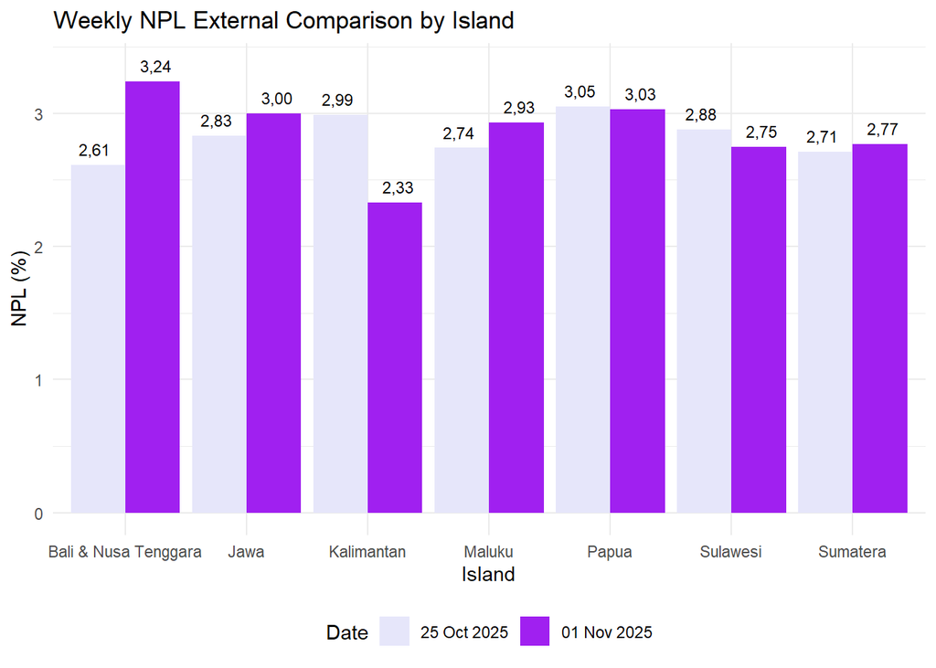

```r
# PLOT 1.3.b: NPL Comparison by Island
plot1.3.b <- ggplot(external_NPL_Current, aes(x = island,
                    y = NPL,
                    text = label)) +

  geom_col(position = position_dodge(width = 0.9),
           aes(fill = Date)) +
  geom_text(aes(y = NPL + 0.12,
                label = label_number(big.mark = ".",
                                     decimal.mark = ",",
                                     accuracy = 0.01)
                (NPL),
                group = Date),
            position = position_dodge(width = 1),
            size = 3.0) +
  scale_fill_manual(values= c("lavender", "purple")) +
  labs(title = "Weekly NPL External Comparison by Island",
       x = "Island",
       y = "NPL (%)") +
  theme_minimal() +
  theme(legend.position = "bottom")

plot1.3.b
```

```r
# This is for interactive plot
# ggplotly(plot1.3.b, tooltip = "text") %>%
#   layout(legend = list(orientation = "h",
#                        y = -0.3))
```

The chart above presents the **Weekly NPL External Comparison by Island**, showing the **NPL (%)** for **25 Oct 2025** and **01 Nov 2025**.

- Overall, **NPL External levels remain relatively stable** across islands, with a noticeable increase in **Bali & Nusa Tenggara**.

## Line 4 (Gross, Net, External NPL Weekly Difference)

Now, I’ll create a **plot** to compare the **national NPL** between this week and last week across each **NPL type**.

### PLOT 1.4: (bar plot)

“Weekly National NPL Comparison by Type”

```r
# Dataset: Gross, Net, and External
sqllab_gross_clean
```

```
#> # A tibble: 135,420 × 11
#>    cut_off_date island region area  branch bucket   noa outstanding_amount  date
#>    <date>       <fct>  <fct>  <fct> <fct>  <fct>  <int>              <dbl> <int>
#>  1 2025-11-01   Sumat… Aceh   Aceh… Aceh … 01. C…    53          91784130.     1
#>  2 2025-11-01   Sumat… Aceh   Aceh… Aceh … 02. 1…   185         254273192.     1
#>  3 2025-11-01   Sumat… Aceh   Aceh… Aceh … 03. 3…   173         431221028.     1
#>  4 2025-11-01   Sumat… Aceh   Aceh… Aceh … 04. 6…   271        1326525315.     1
#>  5 2025-11-01   Sumat… Aceh   Aceh… Aceh … 05. 9…   119         557134482.     1
#>  6 2025-11-01   Sumat… Aceh   Aceh… Aceh … 01. C…   176         836408397.     1
#>  7 2025-11-01   Sumat… Aceh   Aceh… Aceh … 02. 1…   443         850066868.     1
#>  8 2025-11-01   Sumat… Aceh   Aceh… Aceh … 03. 3…   369        1051253334.     1
#>  9 2025-11-01   Sumat… Aceh   Aceh… Aceh … 04. 6…   386         920064468.     1
#> 10 2025-11-01   Sumat… Aceh   Aceh… Aceh … 05. 9…   148         702017007.     1
#> # ℹ 135,410 more rows
#> # ℹ 2 more variables: month <dbl>, year <dbl>
```

```r
sqllab_net_clean
```

```
#> # A tibble: 135,420 × 11
#>    cut_off_date island region area  branch bucket   noa outstanding_amount  date
#>    <date>       <fct>  <fct>  <fct> <fct>  <fct>  <int>              <dbl> <int>
#>  1 2025-11-01   Sumat… Aceh   Aceh… Aceh … 01. C…    53          76934000.     1
#>  2 2025-11-01   Sumat… Aceh   Aceh… Aceh … 02. 1…   185         218410473.     1
#>  3 2025-11-01   Sumat… Aceh   Aceh… Aceh … 03. 3…   173         317760703.     1
#>  4 2025-11-01   Sumat… Aceh   Aceh… Aceh … 04. 6…   271         811554170.     1
#>  5 2025-11-01   Sumat… Aceh   Aceh… Aceh … 05. 9…   119         271330064.     1
#>  6 2025-11-01   Sumat… Aceh   Aceh… Aceh … 01. C…   176         581834603.     1
#>  7 2025-11-01   Sumat… Aceh   Aceh… Aceh … 02. 1…   443         748995851.     1
#>  8 2025-11-01   Sumat… Aceh   Aceh… Aceh … 03. 3…   369         877552083.     1
#>  9 2025-11-01   Sumat… Aceh   Aceh… Aceh … 04. 6…   386         558000043.     1
#> 10 2025-11-01   Sumat… Aceh   Aceh… Aceh … 05. 9…   148         335235117.     1
#> # ℹ 135,410 more rows
#> # ℹ 2 more variables: month <dbl>, year <dbl>
```

```r
sqllab_external_clean
```

```
#> # A tibble: 135,420 × 11
#>    cut_off_date island region area  branch bucket   noa outstanding_amount  date
#>    <date>       <fct>  <fct>  <fct> <fct>  <fct>  <int>              <dbl> <int>
#>  1 2025-11-01   Sumat… Aceh   Aceh… Aceh … 01. C…    53          64398309.     1
#>  2 2025-11-01   Sumat… Aceh   Aceh… Aceh … 02. 1…   185         206470008.     1
#>  3 2025-11-01   Sumat… Aceh   Aceh… Aceh … 03. 3…   173         231682208.     1
#>  4 2025-11-01   Sumat… Aceh   Aceh… Aceh … 04. 6…   271         648403168.     1
#>  5 2025-11-01   Sumat… Aceh   Aceh… Aceh … 05. 9…   119          50133476.     1
#>  6 2025-11-01   Sumat… Aceh   Aceh… Aceh … 01. C…   176         458579814.     1
#>  7 2025-11-01   Sumat… Aceh   Aceh… Aceh … 02. 1…   443         553795359.     1
#>  8 2025-11-01   Sumat… Aceh   Aceh… Aceh … 03. 3…   369         827679983.     1
#>  9 2025-11-01   Sumat… Aceh   Aceh… Aceh … 04. 6…   386         511141034.     1
#> 10 2025-11-01   Sumat… Aceh   Aceh… Aceh … 05. 9…   148          47998959.     1
#> # ℹ 135,410 more rows
#> # ℹ 2 more variables: month <dbl>, year <dbl>
```

```r
# Dataset Gross: DPD 90 & NPL (last 2 weeks)
gross_NPL_Current
```

```
#> # A tibble: 14 × 7
#>    cut_off_date island           DPD_90 total_outstanding_am…¹   NPL Date  label
#>    <date>       <fct>             <dbl>                  <dbl> <dbl> <fct> <glu>
#>  1 2025-11-01   Bali & Nusa Te… 3.10e10          143791078634.  21.6 01 N… NPL:…
#>  2 2025-11-01   Jawa            6.41e10          305058385753.  21.0 01 N… NPL:…
#>  3 2025-11-01   Kalimantan      4.71e10          259755858198.  18.1 01 N… NPL:…
#>  4 2025-11-01   Maluku          2.14e10           95847719915.  22.3 01 N… NPL:…
#>  5 2025-11-01   Papua           5.57e10          244322416284.  22.8 01 N… NPL:…
#>  6 2025-11-01   Sulawesi        5.61e10          294961035802.  19.0 01 N… NPL:…
#>  7 2025-11-01   Sumatera        9.79e10          487478246847.  20.1 01 N… NPL:…
#>  8 2025-10-25   Bali & Nusa Te… 2.76e10          153656464025.  18.0 25 O… NPL:…
#>  9 2025-10-25   Jawa            5.64e10          294687968540.  19.2 25 O… NPL:…
#> 10 2025-10-25   Kalimantan      5.30e10          248424159664.  21.4 25 O… NPL:…
#> 11 2025-10-25   Maluku          2.10e10          104190643257.  20.2 25 O… NPL:…
#> 12 2025-10-25   Papua           4.85e10          236608492865.  20.5 25 O… NPL:…
#> 13 2025-10-25   Sulawesi        5.69e10          288169823468.  19.7 25 O… NPL:…
#> 14 2025-10-25   Sumatera        9.99e10          495701974100.  20.1 25 O… NPL:…
#> # ℹ abbreviated name: ¹total_outstanding_amount
```

```r
# Dataset Net: DPD 90 & NPL (last 2 weeks)
net_NPL_Current
```

```
#> # A tibble: 14 × 7
#>    cut_off_date island           DPD_90 total_outstanding_am…¹   NPL Date  label
#>    <date>       <fct>             <dbl>                  <dbl> <dbl> <fct> <glu>
#>  1 2025-11-01   Bali & Nusa Te… 1.10e10           95070042667. 11.5  01 N… NPL:…
#>  2 2025-11-01   Jawa            2.25e10          205579088033. 11.0  01 N… NPL:…
#>  3 2025-11-01   Kalimantan      1.60e10          176411648216.  9.05 01 N… NPL:…
#>  4 2025-11-01   Maluku          7.60e 9           64200464734. 11.8  01 N… NPL:…
#>  5 2025-11-01   Papua           1.86e10          159773648683. 11.7  01 N… NPL:…
#>  6 2025-11-01   Sulawesi        2.05e10          199024648131. 10.3  01 N… NPL:…
#>  7 2025-11-01   Sumatera        3.55e10          327494137949. 10.8  01 N… NPL:…
#>  8 2025-10-25   Bali & Nusa Te… 9.95e 9          104033344709.  9.56 25 O… NPL:…
#>  9 2025-10-25   Jawa            2.12e10          198472628731. 10.7  25 O… NPL:…
#> 10 2025-10-25   Kalimantan      1.86e10          167940849035. 11.1  25 O… NPL:…
#> 11 2025-10-25   Maluku          6.68e 9           69862251215.  9.57 25 O… NPL:…
#> 12 2025-10-25   Papua           1.68e10          157465762086. 10.7  25 O… NPL:…
#> 13 2025-10-25   Sulawesi        2.08e10          193968983299. 10.7  25 O… NPL:…
#> 14 2025-10-25   Sumatera        3.44e10          333485371118. 10.3  25 O… NPL:…
#> # ℹ abbreviated name: ¹total_outstanding_amount
```

```r
# Dataset External: DPD 90 & NPL (last 2 weeks)
external_NPL_Current
```

```
#> # A tibble: 14 × 7
#>    cut_off_date island           DPD_90 total_outstanding_am…¹   NPL Date  label
#>    <date>       <fct>             <dbl>                  <dbl> <dbl> <fct> <glu>
#>  1 2025-11-01   Bali & Nusa Ten… 2.31e9           71226252420.  3.24 01 N… NPL:…
#>  2 2025-11-01   Jawa             4.68e9          156117687350.  3    01 N… NPL:…
#>  3 2025-11-01   Kalimantan       3.15e9          135307784341.  2.33 01 N… NPL:…
#>  4 2025-11-01   Maluku           1.44e9           49013872412.  2.93 01 N… NPL:…
#>  5 2025-11-01   Papua            3.65e9          120467879306.  3.03 01 N… NPL:…
#>  6 2025-11-01   Sulawesi         4.16e9          151287046551.  2.75 01 N… NPL:…
#>  7 2025-11-01   Sumatera         6.81e9          245719756420.  2.77 01 N… NPL:…
#>  8 2025-10-25   Bali & Nusa Ten… 2.09e9           79929170711.  2.61 25 O… NPL:…
#>  9 2025-10-25   Jawa             4.22e9          149145882346.  2.83 25 O… NPL:…
#> 10 2025-10-25   Kalimantan       3.81e9          127755024506.  2.99 25 O… NPL:…
#> 11 2025-10-25   Maluku           1.51e9           54843305702.  2.74 25 O… NPL:…
#> 12 2025-10-25   Papua            3.66e9          119965198231.  3.05 25 O… NPL:…
#> 13 2025-10-25   Sulawesi         4.23e9          146770759955.  2.88 25 O… NPL:…
#> 14 2025-10-25   Sumatera         6.88e9          253752951291.  2.71 25 O… NPL:…
#> # ℹ abbreviated name: ¹total_outstanding_amount
```

In this step, the Gross, Net, and External NPL datasets are *combined* and *aggregated* at the national level based on each cut-off date. The total outstanding amounts and DPD 90+ values are *calculated* to derive the respective NPL percentages for each type.

This processed data will then be used to visualize the **Weekly National NPL Comparison by Type**, showing how each NPL category evolves over time.

```r
# Data Wrangling ~> Nationally
GNE_NPL_current <- gross_NPL_Current %>%

  # Merging all current NPL datasets based on cut off date and island
  inner_join(net_NPL_Current, by= c("cut_off_date", "island")) %>%
  inner_join(external_NPL_Current, by = c("cut_off_date", "island")) %>%

  group_by(cut_off_date) %>%
  summarise(
    # Aggregating/ summarizing data to national level
    DPD_90_gross = sum(DPD_90.x),
    total_outstanding_amount_gross = sum(total_outstanding_amount.x),
    DPD_90_net = sum(DPD_90.y),
    total_outstanding_amount_net = sum(total_outstanding_amount.y),
    DPD_90_external = sum(DPD_90),
    total_outstanding_amount_external = sum(total_outstanding_amount)
      ) %>%
  ungroup() %>%

  mutate(
    # NPL Gross, Net, and External
    Gross = round((DPD_90_gross / total_outstanding_amount_gross * 100),2),
    Net = round((DPD_90_net / total_outstanding_amount_net * 100),2),
    External = round((DPD_90_external / total_outstanding_amount_external * 100),2),

    # Date ~> for legend
    Date = factor(
      format(cut_off_date, "%d %b %Y"),
      levels = format(sort(unique(cut_off_date)),"%d %b %Y"))
  ) %>%

  select(
    -c(DPD_90_gross,
       total_outstanding_amount_gross,
       DPD_90_net,
       total_outstanding_amount_net,
       DPD_90_external,
       total_outstanding_amount_external)
  )

GNE_NPL_current
```

```
#> # A tibble: 2 × 5
#>   cut_off_date Gross   Net External Date
#>   <date>       <dbl> <dbl>    <dbl> <fct>
#> 1 2025-10-25    20.0  10.5     2.83 25 Oct 2025
#> 2 2025-11-01    20.4  10.7     2.82 01 Nov 2025
```

```r
# pivot longer
GNE_NPL_current <- GNE_NPL_current %>%
  pivot_longer(
    cols = c(Gross, Net, External),
    names_to = "NPL_type",
    values_to = "NPL"
  ) %>%
  mutate(NPL_type = factor(NPL_type, levels = c("Gross", "Net", "External")))

GNE_NPL_current
```

```
#> # A tibble: 6 × 4
#>   cut_off_date Date        NPL_type   NPL
#>   <date>       <fct>       <fct>    <dbl>
#> 1 2025-10-25   25 Oct 2025 Gross    20.0
#> 2 2025-10-25   25 Oct 2025 Net      10.5
#> 3 2025-10-25   25 Oct 2025 External  2.83
#> 4 2025-11-01   01 Nov 2025 Gross    20.4
#> 5 2025-11-01   01 Nov 2025 Net      10.7
#> 6 2025-11-01   01 Nov 2025 External  2.82
```

```r
# tooltip
GNE_NPL_current <- GNE_NPL_current %>%
  mutate(
    label = glue(
      "NPL: {number(NPL,  big.mark = '.', decimal.mark = ',', accuracy = 0.01)}%
      Cut Off Date: {format(as.Date(cut_off_date), '%d %b %Y')}"
    )
  )
GNE_NPL_current
```

```
#> # A tibble: 6 × 5
#>   cut_off_date Date        NPL_type   NPL label
#>   <date>       <fct>       <fct>    <dbl> <glue>
#> 1 2025-10-25   25 Oct 2025 Gross    20.0  NPL: 19,95%
#> Cut Off Date: 25 Oct 2025
#> 2 2025-10-25   25 Oct 2025 Net      10.5  NPL: 10,49%
#> Cut Off Date: 25 Oct 2025
#> 3 2025-10-25   25 Oct 2025 External  2.83 NPL: 2,83%
#> Cut Off Date: 25 Oct 2025
#> 4 2025-11-01   01 Nov 2025 Gross    20.4  NPL: 20,39%
#> Cut Off Date: 01 Nov 2025
#> 5 2025-11-01   01 Nov 2025 Net      10.7  NPL: 10,72%
#> Cut Off Date: 01 Nov 2025
#> 6 2025-11-01   01 Nov 2025 External  2.82 NPL: 2,82%
#> Cut Off Date: 01 Nov 2025
```

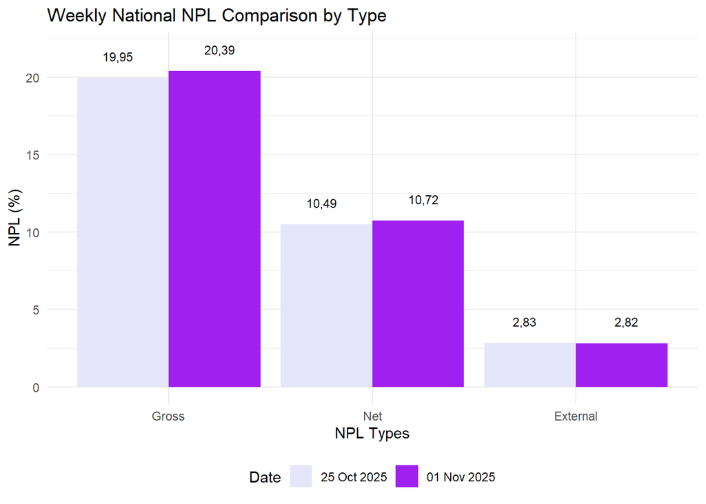

```r
# PLOT 1.4: Weekly National NPL Comparison by Type
plot1.4 <- ggplot(GNE_NPL_current, aes(x = NPL_type,
                    y = NPL,
                    text = label)) +

  geom_col(position = position_dodge(width = 0.9),
           aes(fill = Date)) +
  geom_text(aes(y = NPL + 1.4,
                label = label_number(big.mark = ".",
                                     decimal.mark = ",",
                                     accuracy = 0.01)
                (NPL),
                group = Date),
            position = position_dodge(width = 1),
            size = 3.0) +
  scale_fill_manual(values= c("lavender", "purple")) +
  labs(title = "Weekly National NPL Comparison by Type",
       x = "NPL Types",
       y = "NPL (%)") +
  theme_minimal() +
  theme(legend.position = "bottom")

plot1.4
```

```r
# This is for interactive plot
# ggplotly(plot1.4, tooltip = "text") %>%
#   layout(legend = list(orientation = "h",
#                        y = -0.3))
```

The chart above shows the **Weekly National NPL Comparison by Type**, comparing data from **25 Oct 2025** and **01 Nov 2025**.

- Overall, **Gross and Net NPL** slightly increased from **19.95% to 20.39%** and **10.49% to 10.72%**, respectively, indicating a minor rise in national non-performing loans.
- Meanwhile, **External NPL** remained stable at around **2.8%**, suggesting consistent performance in externally financed loans.

By definition, **Gross NPL** will always be higher than **Net NPL**, and **Net NPL** will always be higher than **External NPL**. This is because **Net NPL** excludes loans that have been written off, while **External NPL** further excludes loans covered by eligible claim assurances.

## Line 5 (Weekly Net NPL Comparison & DPD 90+ Difference)

### PLOT 1.5: (bar plot)

“Net NPL Weekly Comparison”

```r
# Net Dataset
sqllab_net_clean
```

```
#> # A tibble: 135,420 × 11
#>    cut_off_date island region area  branch bucket   noa outstanding_amount  date
#>    <date>       <fct>  <fct>  <fct> <fct>  <fct>  <int>              <dbl> <int>
#>  1 2025-11-01   Sumat… Aceh   Aceh… Aceh … 01. C…    53          76934000.     1
#>  2 2025-11-01   Sumat… Aceh   Aceh… Aceh … 02. 1…   185         218410473.     1
#>  3 2025-11-01   Sumat… Aceh   Aceh… Aceh … 03. 3…   173         317760703.     1
#>  4 2025-11-01   Sumat… Aceh   Aceh… Aceh … 04. 6…   271         811554170.     1
#>  5 2025-11-01   Sumat… Aceh   Aceh… Aceh … 05. 9…   119         271330064.     1
#>  6 2025-11-01   Sumat… Aceh   Aceh… Aceh … 01. C…   176         581834603.     1
#>  7 2025-11-01   Sumat… Aceh   Aceh… Aceh … 02. 1…   443         748995851.     1
#>  8 2025-11-01   Sumat… Aceh   Aceh… Aceh … 03. 3…   369         877552083.     1
#>  9 2025-11-01   Sumat… Aceh   Aceh… Aceh … 04. 6…   386         558000043.     1
#> 10 2025-11-01   Sumat… Aceh   Aceh… Aceh … 05. 9…   148         335235117.     1
#> # ℹ 135,410 more rows
#> # ℹ 2 more variables: month <dbl>, year <dbl>
```

```r
# Dataset Net: DPD 90 & NPL (last 2 weeks)
net_NPL_Current
```

```
#> # A tibble: 14 × 7
#>    cut_off_date island           DPD_90 total_outstanding_am…¹   NPL Date  label
#>    <date>       <fct>             <dbl>                  <dbl> <dbl> <fct> <glu>
#>  1 2025-11-01   Bali & Nusa Te… 1.10e10           95070042667. 11.5  01 N… NPL:…
#>  2 2025-11-01   Jawa            2.25e10          205579088033. 11.0  01 N… NPL:…
#>  3 2025-11-01   Kalimantan      1.60e10          176411648216.  9.05 01 N… NPL:…
#>  4 2025-11-01   Maluku          7.60e 9           64200464734. 11.8  01 N… NPL:…
#>  5 2025-11-01   Papua           1.86e10          159773648683. 11.7  01 N… NPL:…
#>  6 2025-11-01   Sulawesi        2.05e10          199024648131. 10.3  01 N… NPL:…
#>  7 2025-11-01   Sumatera        3.55e10          327494137949. 10.8  01 N… NPL:…
#>  8 2025-10-25   Bali & Nusa Te… 9.95e 9          104033344709.  9.56 25 O… NPL:…
#>  9 2025-10-25   Jawa            2.12e10          198472628731. 10.7  25 O… NPL:…
#> 10 2025-10-25   Kalimantan      1.86e10          167940849035. 11.1  25 O… NPL:…
#> 11 2025-10-25   Maluku          6.68e 9           69862251215.  9.57 25 O… NPL:…
#> 12 2025-10-25   Papua           1.68e10          157465762086. 10.7  25 O… NPL:…
#> 13 2025-10-25   Sulawesi        2.08e10          193968983299. 10.7  25 O… NPL:…
#> 14 2025-10-25   Sumatera        3.44e10          333485371118. 10.3  25 O… NPL:…
#> # ℹ abbreviated name: ¹total_outstanding_amount
```

Now, we need to *aggregate* the Net NPL data on a weekly basis by *summing* the DPD 90+ and total outstanding amounts for each cut-off date.

The weekly Net NPL percentage is then *calculated*, *rounded* to two decimal places, and *arranged* chronologically to prepare for visualization.

```r
# Data Wrangling
net_NPL_weekly_comparison <- net_NPL_Current %>%
  group_by(cut_off_date) %>%
  summarise(NPL_weekly = (sum(DPD_90)/sum(total_outstanding_amount))*100) %>%
  ungroup() %>%
  mutate(
    NPL_weekly = round(NPL_weekly,2),
    Date = factor(
      format(cut_off_date, "%d %b %Y"),
      levels = format(sort(unique(cut_off_date)), "%d %b %Y"))
  ) %>%
  arrange(desc(cut_off_date))

net_NPL_weekly_comparison
```

```
#> # A tibble: 2 × 3
#>   cut_off_date NPL_weekly Date
#>   <date>            <dbl> <fct>
#> 1 2025-11-01         10.7 01 Nov 2025
#> 2 2025-10-25         10.5 25 Oct 2025
```

```r
# tooltip
net_NPL_weekly_comparison <- net_NPL_weekly_comparison %>%
  mutate(
    label = glue(
      "NPL: {number(NPL_weekly,  big.mark = '.', decimal.mark = ',', accuracy = 0.01)}%
      Cut Off Date: {format(as.Date(cut_off_date), '%d %b %Y')}"
    )
  )
net_NPL_weekly_comparison
```

```
#> # A tibble: 2 × 4
#>   cut_off_date NPL_weekly Date        label
#>   <date>            <dbl> <fct>       <glue>
#> 1 2025-11-01         10.7 01 Nov 2025 NPL: 10,72%
#> Cut Off Date: 01 Nov 2025
#> 2 2025-10-25         10.5 25 Oct 2025 NPL: 10,49%
#> Cut Off Date: 25 Oct 2025
```

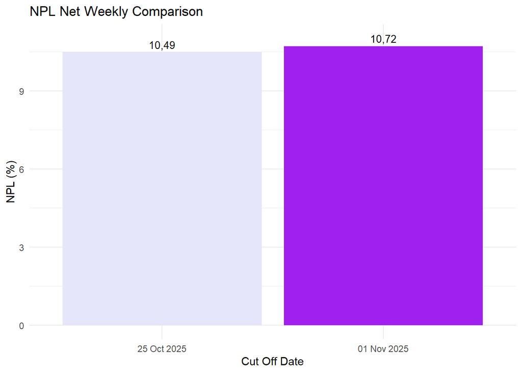

```r
# PLOT 1.5: NPL Net Weekly Comparison
plot1.5 <- ggplot(net_NPL_weekly_comparison, aes(x = Date,
                    y = NPL_weekly,
                    text = label)) +

  geom_col(position = "dodge", aes(fill = Date)) +
  scale_fill_manual(values= c("lavender", "purple")) +
  geom_text(aes(y = NPL_weekly + 0.3,
                label = label_number(big.mark = ".",
                                     decimal.mark = ",",
                                     accuracy = 0.01)
                (NPL_weekly),
                group = Date),
            size = 3.5)  +
  labs(title = "NPL Net Weekly Comparison",
       x = "Cut Off Date",
       y = "NPL (%)") +
  theme_minimal() +
  theme(legend.position = "none")

plot1.5
```

```r
# This is for interactive plot
# ggplotly(plot1.5, tooltip = "text")
```

The chart shows the **Net NPL** percentage comparison between **25 October 2025** and **01 November 2025**.

- There is a slight **increase** in NPL from **10.49%** to **10.72%**, indicating a **0.23 percentage point rise** in the weekly NPL rate.

### Difference Net NPL Weekly in Detail (%)

“Difference Net NPL Weekly in Detail”

```r
# Net NPL Last two weeks
net_NPL_weekly_comparison
```

```
#> # A tibble: 2 × 4
#>   cut_off_date NPL_weekly Date        label
#>   <date>            <dbl> <fct>       <glue>
#> 1 2025-11-01         10.7 01 Nov 2025 NPL: 10,72%
#> Cut Off Date: 01 Nov 2025
#> 2 2025-10-25         10.5 25 Oct 2025 NPL: 10,49%
#> Cut Off Date: 25 Oct 2025
```

```r
# Difference NPL in %
net_Diff_NPL_Weekly <- net_NPL_weekly_comparison %>%
  summarise(NPL_diff = NPL_weekly[1] - NPL_weekly[2],
            NPL_diff = if_else(
              NPL_diff >0,
              paste0("+", format(round(NPL_diff, 2), big.mark = ".", decimal.mark = ",", nsmall = 2), "%"), # if condition
      paste0(format(round(NPL_diff, 2), big.mark = ".", decimal.mark = ",", nsmall = 2), "%") # else condition
            ))

net_Diff_NPL_Weekly
```

```
#> # A tibble: 1 × 1
#>   NPL_diff
#>   <chr>
#> 1 +0,23%
```

### Difference Net DPD 90+ in Rp

```r
# Net Dataset
sqllab_net_clean
```

```
#> # A tibble: 135,420 × 11
#>    cut_off_date island region area  branch bucket   noa outstanding_amount  date
#>    <date>       <fct>  <fct>  <fct> <fct>  <fct>  <int>              <dbl> <int>
#>  1 2025-11-01   Sumat… Aceh   Aceh… Aceh … 01. C…    53          76934000.     1
#>  2 2025-11-01   Sumat… Aceh   Aceh… Aceh … 02. 1…   185         218410473.     1
#>  3 2025-11-01   Sumat… Aceh   Aceh… Aceh … 03. 3…   173         317760703.     1
#>  4 2025-11-01   Sumat… Aceh   Aceh… Aceh … 04. 6…   271         811554170.     1
#>  5 2025-11-01   Sumat… Aceh   Aceh… Aceh … 05. 9…   119         271330064.     1
#>  6 2025-11-01   Sumat… Aceh   Aceh… Aceh … 01. C…   176         581834603.     1
#>  7 2025-11-01   Sumat… Aceh   Aceh… Aceh … 02. 1…   443         748995851.     1
#>  8 2025-11-01   Sumat… Aceh   Aceh… Aceh … 03. 3…   369         877552083.     1
#>  9 2025-11-01   Sumat… Aceh   Aceh… Aceh … 04. 6…   386         558000043.     1
#> 10 2025-11-01   Sumat… Aceh   Aceh… Aceh … 05. 9…   148         335235117.     1
#> # ℹ 135,410 more rows
#> # ℹ 2 more variables: month <dbl>, year <dbl>
```

```r
# Dataset Net: DPD 90 & NPL (last 2 weeks)
net_NPL_Current
```

```
#> # A tibble: 14 × 7
#>    cut_off_date island           DPD_90 total_outstanding_am…¹   NPL Date  label
#>    <date>       <fct>             <dbl>                  <dbl> <dbl> <fct> <glu>
#>  1 2025-11-01   Bali & Nusa Te… 1.10e10           95070042667. 11.5  01 N… NPL:…
#>  2 2025-11-01   Jawa            2.25e10          205579088033. 11.0  01 N… NPL:…
#>  3 2025-11-01   Kalimantan      1.60e10          176411648216.  9.05 01 N… NPL:…
#>  4 2025-11-01   Maluku          7.60e 9           64200464734. 11.8  01 N… NPL:…
#>  5 2025-11-01   Papua           1.86e10          159773648683. 11.7  01 N… NPL:…
#>  6 2025-11-01   Sulawesi        2.05e10          199024648131. 10.3  01 N… NPL:…
#>  7 2025-11-01   Sumatera        3.55e10          327494137949. 10.8  01 N… NPL:…
#>  8 2025-10-25   Bali & Nusa Te… 9.95e 9          104033344709.  9.56 25 O… NPL:…
#>  9 2025-10-25   Jawa            2.12e10          198472628731. 10.7  25 O… NPL:…
#> 10 2025-10-25   Kalimantan      1.86e10          167940849035. 11.1  25 O… NPL:…
#> 11 2025-10-25   Maluku          6.68e 9           69862251215.  9.57 25 O… NPL:…
#> 12 2025-10-25   Papua           1.68e10          157465762086. 10.7  25 O… NPL:…
#> 13 2025-10-25   Sulawesi        2.08e10          193968983299. 10.7  25 O… NPL:…
#> 14 2025-10-25   Sumatera        3.44e10          333485371118. 10.3  25 O… NPL:…
#> # ℹ abbreviated name: ¹total_outstanding_amount
```

```r
# Total DPD 90+ outstanding amount last 2 weeks
net_Diff_DPD90_weekly <- net_NPL_Current %>%
  group_by(cut_off_date) %>%
  summarise(Total_DPD_90_weekly = sum(DPD_90)) %>%
  ungroup() %>%
  arrange(desc(cut_off_date))

net_Diff_DPD90_weekly
```

```
#> # A tibble: 2 × 2
#>   cut_off_date Total_DPD_90_weekly
#>   <date>                     <dbl>
#> 1 2025-11-01         131611758658.
#> 2 2025-10-25         128518958548.
```

```r
# Difference Net DPD 90+ in Rp
net_Diff_DPD90_weekly <- net_Diff_DPD90_weekly %>%
  summarise(Diff_DPD90_weekly= Total_DPD_90_weekly[1]-Total_DPD_90_weekly[2],
            Diff_DPD90_weekly = if_else(
              Diff_DPD90_weekly >0,
              paste0(" + IDR ", comma(Diff_DPD90_weekly)), # ini if-nya
              paste0(" - IDR ", comma(Diff_DPD90_weekly * (-1))) # ini else-nya
            ),

            Diff_DPD90_weekly = gsub(",", ".", Diff_DPD90_weekly),  # change thousand sep to "."
    Diff_DPD90_weekly = sub("\\.(\\d{2})$", ",\\1", Diff_DPD90_weekly) # change decimal sep to ","
    )

net_Diff_DPD90_weekly
```

```
#> # A tibble: 1 × 1
#>   Diff_DPD90_weekly
#>   <chr>
#> 1 " + IDR 3.092.800.111"
```

## Line 6 (Gross, Net, and External NPL Trends Over the Last 8 Weeks)

Next, I’ll create a **line plot** to visualize the **national NPL** trend over the last 8 weeks across each NPL type (`Gross`, `Net`, and `External`).

### PLOT 1.6: (line plot)

“Last 8 Weeks NPL Position ~ Date vs NPL (%)”

```r
# Dataset: Gross, Net, and External
sqllab_gross_clean
```

```
#> # A tibble: 135,420 × 11
#>    cut_off_date island region area  branch bucket   noa outstanding_amount  date
#>    <date>       <fct>  <fct>  <fct> <fct>  <fct>  <int>              <dbl> <int>
#>  1 2025-11-01   Sumat… Aceh   Aceh… Aceh … 01. C…    53          91784130.     1
#>  2 2025-11-01   Sumat… Aceh   Aceh… Aceh … 02. 1…   185         254273192.     1
#>  3 2025-11-01   Sumat… Aceh   Aceh… Aceh … 03. 3…   173         431221028.     1
#>  4 2025-11-01   Sumat… Aceh   Aceh… Aceh … 04. 6…   271        1326525315.     1
#>  5 2025-11-01   Sumat… Aceh   Aceh… Aceh … 05. 9…   119         557134482.     1
#>  6 2025-11-01   Sumat… Aceh   Aceh… Aceh … 01. C…   176         836408397.     1
#>  7 2025-11-01   Sumat… Aceh   Aceh… Aceh … 02. 1…   443         850066868.     1
#>  8 2025-11-01   Sumat… Aceh   Aceh… Aceh … 03. 3…   369        1051253334.     1
#>  9 2025-11-01   Sumat… Aceh   Aceh… Aceh … 04. 6…   386         920064468.     1
#> 10 2025-11-01   Sumat… Aceh   Aceh… Aceh … 05. 9…   148         702017007.     1
#> # ℹ 135,410 more rows
#> # ℹ 2 more variables: month <dbl>, year <dbl>
```

```r
sqllab_net_clean
```

```
#> # A tibble: 135,420 × 11
#>    cut_off_date island region area  branch bucket   noa outstanding_amount  date
#>    <date>       <fct>  <fct>  <fct> <fct>  <fct>  <int>              <dbl> <int>
#>  1 2025-11-01   Sumat… Aceh   Aceh… Aceh … 01. C…    53          76934000.     1
#>  2 2025-11-01   Sumat… Aceh   Aceh… Aceh … 02. 1…   185         218410473.     1
#>  3 2025-11-01   Sumat… Aceh   Aceh… Aceh … 03. 3…   173         317760703.     1
#>  4 2025-11-01   Sumat… Aceh   Aceh… Aceh … 04. 6…   271         811554170.     1
#>  5 2025-11-01   Sumat… Aceh   Aceh… Aceh … 05. 9…   119         271330064.     1
#>  6 2025-11-01   Sumat… Aceh   Aceh… Aceh … 01. C…   176         581834603.     1
#>  7 2025-11-01   Sumat… Aceh   Aceh… Aceh … 02. 1…   443         748995851.     1
#>  8 2025-11-01   Sumat… Aceh   Aceh… Aceh … 03. 3…   369         877552083.     1
#>  9 2025-11-01   Sumat… Aceh   Aceh… Aceh … 04. 6…   386         558000043.     1
#> 10 2025-11-01   Sumat… Aceh   Aceh… Aceh … 05. 9…   148         335235117.     1
#> # ℹ 135,410 more rows
#> # ℹ 2 more variables: month <dbl>, year <dbl>
```

```r
sqllab_external_clean
```

```
#> # A tibble: 135,420 × 11
#>    cut_off_date island region area  branch bucket   noa outstanding_amount  date
#>    <date>       <fct>  <fct>  <fct> <fct>  <fct>  <int>              <dbl> <int>
#>  1 2025-11-01   Sumat… Aceh   Aceh… Aceh … 01. C…    53          64398309.     1
#>  2 2025-11-01   Sumat… Aceh   Aceh… Aceh … 02. 1…   185         206470008.     1
#>  3 2025-11-01   Sumat… Aceh   Aceh… Aceh … 03. 3…   173         231682208.     1
#>  4 2025-11-01   Sumat… Aceh   Aceh… Aceh … 04. 6…   271         648403168.     1
#>  5 2025-11-01   Sumat… Aceh   Aceh… Aceh … 05. 9…   119          50133476.     1
#>  6 2025-11-01   Sumat… Aceh   Aceh… Aceh … 01. C…   176         458579814.     1
#>  7 2025-11-01   Sumat… Aceh   Aceh… Aceh … 02. 1…   443         553795359.     1
#>  8 2025-11-01   Sumat… Aceh   Aceh… Aceh … 03. 3…   369         827679983.     1
#>  9 2025-11-01   Sumat… Aceh   Aceh… Aceh … 04. 6…   386         511141034.     1
#> 10 2025-11-01   Sumat… Aceh   Aceh… Aceh … 05. 9…   148          47998959.     1
#> # ℹ 135,410 more rows
#> # ℹ 2 more variables: month <dbl>, year <dbl>
```

```r
# Dataset DPD 90: Gross, Net, and External
gross_DPD_90
```

```
#> # A tibble: 427 × 4
#>    cut_off_date island                     DPD_90  date
#>    <date>       <fct>                       <dbl> <int>
#>  1 2025-11-01   Bali & Nusa Tenggara 31003030413.     1
#>  2 2025-11-01   Jawa                 64124530442.     1
#>  3 2025-11-01   Kalimantan           47065999364.     1
#>  4 2025-11-01   Maluku               21402843091.     1
#>  5 2025-11-01   Papua                55714241579.     1
#>  6 2025-11-01   Sulawesi             56068920845.     1
#>  7 2025-11-01   Sumatera             97924116601.     1
#>  8 2025-10-25   Bali & Nusa Tenggara 27586312894.    25
#>  9 2025-10-25   Jawa                 56433908115.    25
#> 10 2025-10-25   Kalimantan           53046595012.    25
#> # ℹ 417 more rows
```

```r
net_DPD_90
```

```
#> # A tibble: 427 × 4
#>    cut_off_date island                     DPD_90  date
#>    <date>       <fct>                       <dbl> <int>
#>  1 2025-11-01   Bali & Nusa Tenggara 10962829834.     1
#>  2 2025-11-01   Jawa                 22503499617.     1
#>  3 2025-11-01   Kalimantan           15959716160.     1
#>  4 2025-11-01   Maluku                7596672396.     1
#>  5 2025-11-01   Papua                18630620970.     1
#>  6 2025-11-01   Sulawesi             20494808363.     1
#>  7 2025-11-01   Sumatera             35463611319.     1
#>  8 2025-10-25   Bali & Nusa Tenggara  9950603569.    25
#>  9 2025-10-25   Jawa                 21248316932.    25
#> 10 2025-10-25   Kalimantan           18613065059.    25
#> # ℹ 417 more rows
```

```r
external_DPD_90
```

```
#> # A tibble: 427 × 4
#>    cut_off_date island                    DPD_90  date
#>    <date>       <fct>                      <dbl> <int>
#>  1 2025-11-01   Bali & Nusa Tenggara 2306183060.     1
#>  2 2025-11-01   Jawa                 4678951964.     1
#>  3 2025-11-01   Kalimantan           3150806736.     1
#>  4 2025-11-01   Maluku               1435651017.     1
#>  5 2025-11-01   Papua                3649461770.     1
#>  6 2025-11-01   Sulawesi             4164370184.     1
#>  7 2025-11-01   Sumatera             6808339308.     1
#>  8 2025-10-25   Bali & Nusa Tenggara 2085192548.    25
#>  9 2025-10-25   Jawa                 4222837848.    25
#> 10 2025-10-25   Kalimantan           3814219996.    25
#> # ℹ 417 more rows
```

```r
# Dataset Total Outstanding (all buckets): Gross, Net, and External
gross_total_outstanding2
```

```
#> # A tibble: 427 × 4
#>    cut_off_date island               total_outstanding_amount  date
#>    <date>       <fct>                                   <dbl> <int>
#>  1 2025-11-01   Bali & Nusa Tenggara            143791078634.     1
#>  2 2025-11-01   Jawa                            305058385753.     1
#>  3 2025-11-01   Kalimantan                      259755858198.     1
#>  4 2025-11-01   Maluku                           95847719915.     1
#>  5 2025-11-01   Papua                           244322416284.     1
#>  6 2025-11-01   Sulawesi                        294961035802.     1
#>  7 2025-11-01   Sumatera                        487478246847.     1
#>  8 2025-10-25   Bali & Nusa Tenggara            153656464025.    25
#>  9 2025-10-25   Jawa                            294687968540.    25
#> 10 2025-10-25   Kalimantan                      248424159664.    25
#> # ℹ 417 more rows
```

```r
net_total_outstanding2
```

```
#> # A tibble: 427 × 4
#>    cut_off_date island               total_outstanding_amount  date
#>    <date>       <fct>                                   <dbl> <int>
#>  1 2025-11-01   Bali & Nusa Tenggara             95070042667.     1
#>  2 2025-11-01   Jawa                            205579088033.     1
#>  3 2025-11-01   Kalimantan                      176411648216.     1
#>  4 2025-11-01   Maluku                           64200464734.     1
#>  5 2025-11-01   Papua                           159773648683.     1
#>  6 2025-11-01   Sulawesi                        199024648131.     1
#>  7 2025-11-01   Sumatera                        327494137949.     1
#>  8 2025-10-25   Bali & Nusa Tenggara            104033344709.    25
#>  9 2025-10-25   Jawa                            198472628731.    25
#> 10 2025-10-25   Kalimantan                      167940849035.    25
#> # ℹ 417 more rows
```

```r
external_total_outstanding2
```

```
#> # A tibble: 427 × 4
#>    cut_off_date island               total_outstanding_amount  date
#>    <date>       <fct>                                   <dbl> <int>
#>  1 2025-11-01   Bali & Nusa Tenggara             71226252420.     1
#>  2 2025-11-01   Jawa                            156117687350.     1
#>  3 2025-11-01   Kalimantan                      135307784341.     1
#>  4 2025-11-01   Maluku                           49013872412.     1
#>  5 2025-11-01   Papua                           120467879306.     1
#>  6 2025-11-01   Sulawesi                        151287046551.     1
#>  7 2025-11-01   Sumatera                        245719756420.     1
#>  8 2025-10-25   Bali & Nusa Tenggara             79929170711.    25
#>  9 2025-10-25   Jawa                            149145882346.    25
#> 10 2025-10-25   Kalimantan                      127755024506.    25
#> # ℹ 417 more rows
```

Now, we’re going to calculate the *Gross NPL value* for each *island* across every *cut-off date*.

```r
# Data Wrangling: Gross NPL for each island & cut off date
gross_NPL_last_8_weeks <- gross_DPD_90 %>%
  inner_join(gross_total_outstanding2, by = c("cut_off_date", "island")) %>%
  mutate(
    Gross = round((DPD_90 / total_outstanding_amount * 100),2),
    Date = factor(
      format(cut_off_date, "%d %b %Y"),
      levels = format(sort(unique(cut_off_date)),"%d %b %Y"))
  ) %>%
  select (-c(date.x, date.y)) %>%
  arrange(desc(cut_off_date)) %>%
  filter(cut_off_date <= "2025-11-01")

gross_NPL_last_8_weeks
```

```
#> # A tibble: 427 × 6
#>    cut_off_date island                 DPD_90 total_outstanding_am…¹ Gross Date
#>    <date>       <fct>                   <dbl>                  <dbl> <dbl> <fct>
#>  1 2025-11-01   Bali & Nusa Tenggara  3.10e10          143791078634.  21.6 01 N…
#>  2 2025-11-01   Jawa                  6.41e10          305058385753.  21.0 01 N…
#>  3 2025-11-01   Kalimantan            4.71e10          259755858198.  18.1 01 N…
#>  4 2025-11-01   Maluku                2.14e10           95847719915.  22.3 01 N…
#>  5 2025-11-01   Papua                 5.57e10          244322416284.  22.8 01 N…
#>  6 2025-11-01   Sulawesi              5.61e10          294961035802.  19.0 01 N…
#>  7 2025-11-01   Sumatera              9.79e10          487478246847.  20.1 01 N…
#>  8 2025-10-25   Bali & Nusa Tenggara  2.76e10          153656464025.  18.0 25 O…
#>  9 2025-10-25   Jawa                  5.64e10          294687968540.  19.2 25 O…
#> 10 2025-10-25   Kalimantan            5.30e10          248424159664.  21.4 25 O…
#> # ℹ 417 more rows
#> # ℹ abbreviated name: ¹total_outstanding_amount
```

After obtaining each *island* and *cut-off date’s Gross NPL value*, we now calculate the *overall national Gross NPL* by *grouping the data* based on the *cut-off date*, then *summing all DPD 90+ values* and *dividing them by the total outstanding amounts*. This process results in the *national Gross NPL value* for each *cut-off date*.

```r
# National Gross NPL value for each cut off date
gross_NPL_last_8_weeks <- gross_NPL_last_8_weeks %>%
  group_by(cut_off_date) %>%
  summarise(Gross= round((sum(DPD_90)/sum(total_outstanding_amount)*100),2)) %>%
  ungroup() %>%
  arrange(desc(cut_off_date))

gross_NPL_last_8_weeks
```

```
#> # A tibble: 61 × 2
#>    cut_off_date Gross
#>    <date>       <dbl>
#>  1 2025-11-01    20.4
#>  2 2025-10-25    20.0
#>  3 2025-10-18    19.0
#>  4 2025-10-11    20.1
#>  5 2025-10-04    20.9
#>  6 2025-09-27    20.1
#>  7 2025-09-20    20.1
#>  8 2025-09-13    20.0
#>  9 2025-09-06    20.2
#> 10 2025-08-30    20.2
#> # ℹ 51 more rows
```

Now, we’re going to calculate the *Net NPL value* for each *island* across every *cut-off date*.

```r
# Data Wrangling: Net NPL for each island & cut off date
net_NPL_last_8_weeks <- net_DPD_90 %>%
  inner_join(net_total_outstanding2, by = c("cut_off_date", "island")) %>%
  mutate(
    Net = round((DPD_90 / total_outstanding_amount * 100),2),
    Date = factor(
      format(cut_off_date, "%d %b %Y"),
      levels = format(sort(unique(cut_off_date)),"%d %b %Y"))
  ) %>%
  select (-c(date.x, date.y)) %>%
  arrange(desc(cut_off_date)) %>%
  filter(cut_off_date <= "2025-11-01")

net_NPL_last_8_weeks
```

```
#> # A tibble: 427 × 6
#>    cut_off_date island                 DPD_90 total_outstanding_am…¹   Net Date
#>    <date>       <fct>                   <dbl>                  <dbl> <dbl> <fct>
#>  1 2025-11-01   Bali & Nusa Tenggara  1.10e10           95070042667. 11.5  01 N…
#>  2 2025-11-01   Jawa                  2.25e10          205579088033. 11.0  01 N…
#>  3 2025-11-01   Kalimantan            1.60e10          176411648216.  9.05 01 N…
#>  4 2025-11-01   Maluku                7.60e 9           64200464734. 11.8  01 N…
#>  5 2025-11-01   Papua                 1.86e10          159773648683. 11.7  01 N…
#>  6 2025-11-01   Sulawesi              2.05e10          199024648131. 10.3  01 N…
#>  7 2025-11-01   Sumatera              3.55e10          327494137949. 10.8  01 N…
#>  8 2025-10-25   Bali & Nusa Tenggara  9.95e 9          104033344709.  9.56 25 O…
#>  9 2025-10-25   Jawa                  2.12e10          198472628731. 10.7  25 O…
#> 10 2025-10-25   Kalimantan            1.86e10          167940849035. 11.1  25 O…
#> # ℹ 417 more rows
#> # ℹ abbreviated name: ¹total_outstanding_amount
```

We perform the same process for the Net dataset to derive the *national Net NPL value* for each *cut-off date*.

```r
# National Net NPL value for each cut off date
net_NPL_last_8_weeks <- net_NPL_last_8_weeks %>%
  group_by(cut_off_date) %>%
  summarise(Net= round((sum(DPD_90)/sum(total_outstanding_amount)*100),2)) %>%
  ungroup() %>%
  arrange(desc(cut_off_date))

net_NPL_last_8_weeks
```

```
#> # A tibble: 61 × 2
#>    cut_off_date   Net
#>    <date>       <dbl>
#>  1 2025-11-01   10.7
#>  2 2025-10-25   10.5
#>  3 2025-10-18    9.89
#>  4 2025-10-11   10.6
#>  5 2025-10-04   11.0
#>  6 2025-09-27   10.5
#>  7 2025-09-20   10.4
#>  8 2025-09-13   10.5
#>  9 2025-09-06   10.5
#> 10 2025-08-30   10.7
#> # ℹ 51 more rows
```

Now, we’re going to calculate the *External NPL value* for each *island* across every *cut-off date*.

```r
# Data Wrangling: External NPL for each island & cut off date
external_NPL_last_8_weeks <- external_DPD_90 %>%
  inner_join(external_total_outstanding2, by = c("cut_off_date", "island")) %>%
  mutate(
    External = round((DPD_90 / total_outstanding_amount * 100),2),
    Date = factor(
      format(cut_off_date, "%d %b %Y"),
      levels = format(sort(unique(cut_off_date)),"%d %b %Y"))
  ) %>%
  select (-c(date.x, date.y)) %>%
  arrange(desc(cut_off_date)) %>%
  filter(cut_off_date <= "2025-11-01")

external_NPL_last_8_weeks
```

```
#> # A tibble: 427 × 6
#>    cut_off_date island              DPD_90 total_outstanding_am…¹ External Date
#>    <date>       <fct>                <dbl>                  <dbl>    <dbl> <fct>
#>  1 2025-11-01   Bali & Nusa Tengga… 2.31e9           71226252420.     3.24 01 N…
#>  2 2025-11-01   Jawa                4.68e9          156117687350.     3    01 N…
#>  3 2025-11-01   Kalimantan          3.15e9          135307784341.     2.33 01 N…
#>  4 2025-11-01   Maluku              1.44e9           49013872412.     2.93 01 N…
#>  5 2025-11-01   Papua               3.65e9          120467879306.     3.03 01 N…
#>  6 2025-11-01   Sulawesi            4.16e9          151287046551.     2.75 01 N…
#>  7 2025-11-01   Sumatera            6.81e9          245719756420.     2.77 01 N…
#>  8 2025-10-25   Bali & Nusa Tengga… 2.09e9           79929170711.     2.61 25 O…
#>  9 2025-10-25   Jawa                4.22e9          149145882346.     2.83 25 O…
#> 10 2025-10-25   Kalimantan          3.81e9          127755024506.     2.99 25 O…
#> # ℹ 417 more rows
#> # ℹ abbreviated name: ¹total_outstanding_amount
```

Lastly, we perform the same process for the External dataset to derive the *national External NPL value* for each *cut-off date*.

```r
# National External NPL value for each cut off date
external_NPL_last_8_weeks <- external_NPL_last_8_weeks %>%
  group_by(cut_off_date) %>%
  summarise(External= round((sum(DPD_90)/sum(total_outstanding_amount)*100),2)) %>%
  ungroup() %>%
  arrange(desc(cut_off_date))

external_NPL_last_8_weeks
```

```
#> # A tibble: 61 × 2
#>    cut_off_date External
#>    <date>          <dbl>
#>  1 2025-11-01       2.82
#>  2 2025-10-25       2.83
#>  3 2025-10-18       2.58
#>  4 2025-10-11       2.85
#>  5 2025-10-04       2.87
#>  6 2025-09-27       2.84
#>  7 2025-09-20       2.75
#>  8 2025-09-13       2.77
#>  9 2025-09-06       2.85
#> 10 2025-08-30       2.75
#> # ℹ 51 more rows
```

After obtaining the **Gross**, **Net**, and **External national NPL values** for the last **8 weeks**, we need to **merge them into a single dataset** to make it neater and compare in the next step.

```r
# Merging Gross, Net, and External national NPL values into one dataset
GNE_NPL_last_8_weeks <- gross_NPL_last_8_weeks %>%
  inner_join(net_NPL_last_8_weeks, by = c("cut_off_date")) %>%
  inner_join(external_NPL_last_8_weeks, by = c("cut_off_date")) %>%
  mutate(
    Date = factor(
      format(cut_off_date, "%d %b %Y"),
      levels = format(sort(unique(cut_off_date)),"%d %b %Y"))
  ) %>%
  arrange(desc(cut_off_date))

GNE_NPL_last_8_weeks
```

```
#> # A tibble: 61 × 5
#>    cut_off_date Gross   Net External Date
#>    <date>       <dbl> <dbl>    <dbl> <fct>
#>  1 2025-11-01    20.4 10.7      2.82 01 Nov 2025
#>  2 2025-10-25    20.0 10.5      2.83 25 Oct 2025
#>  3 2025-10-18    19.0  9.89     2.58 18 Oct 2025
#>  4 2025-10-11    20.1 10.6      2.85 11 Oct 2025
#>  5 2025-10-04    20.9 11.0      2.87 04 Oct 2025
#>  6 2025-09-27    20.1 10.5      2.84 27 Sep 2025
#>  7 2025-09-20    20.1 10.4      2.75 20 Sep 2025
#>  8 2025-09-13    20.0 10.5      2.77 13 Sep 2025
#>  9 2025-09-06    20.2 10.5      2.85 06 Sep 2025
#> 10 2025-08-30    20.2 10.7      2.75 30 Aug 2025
#> # ℹ 51 more rows
```

Next, it’s time to **pivot the dataset** to make it easier to visualize.

Since we only want to focus on the **national NPL data for the last 8 weeks**, we will keep only the **top 24 observations**, representing **3 NPL types × 8 weeks = 24 data points**.

```r
# Pivot and taking the last 8 weeks national NPL values
GNE_NPL_last_8_weeks <- GNE_NPL_last_8_weeks %>%
  pivot_longer(
    cols = c(Gross, Net, External),
    names_to = "NPL_type",
    values_to = "NPL"
  ) %>%
  mutate(NPL_type = factor(NPL_type, levels = c("Gross", "Net", "External"))) %>%
  head(24)

GNE_NPL_last_8_weeks
```

```
#> # A tibble: 24 × 4
#>    cut_off_date Date        NPL_type   NPL
#>    <date>       <fct>       <fct>    <dbl>
#>  1 2025-11-01   01 Nov 2025 Gross    20.4
#>  2 2025-11-01   01 Nov 2025 Net      10.7
#>  3 2025-11-01   01 Nov 2025 External  2.82
#>  4 2025-10-25   25 Oct 2025 Gross    20.0
#>  5 2025-10-25   25 Oct 2025 Net      10.5
#>  6 2025-10-25   25 Oct 2025 External  2.83
#>  7 2025-10-18   18 Oct 2025 Gross    19.0
#>  8 2025-10-18   18 Oct 2025 Net       9.89
#>  9 2025-10-18   18 Oct 2025 External  2.58
#> 10 2025-10-11   11 Oct 2025 Gross    20.1
#> # ℹ 14 more rows
```

```r
# tooltip
GNE_NPL_last_8_weeks <- GNE_NPL_last_8_weeks %>%
  mutate(
    label = glue(
      "NPL: {number(NPL,  big.mark = '.', decimal.mark = ',', accuracy = 0.01)}%
      Cut Off Date: {format(as.Date(cut_off_date), '%d %b %Y')}"
    )
  )
GNE_NPL_last_8_weeks
```

```
#> # A tibble: 24 × 5
#>    cut_off_date Date        NPL_type   NPL label
#>    <date>       <fct>       <fct>    <dbl> <glue>
#>  1 2025-11-01   01 Nov 2025 Gross    20.4  NPL: 20,39%
#> Cut Off Date: 01 Nov 2025
#>  2 2025-11-01   01 Nov 2025 Net      10.7  NPL: 10,72%
#> Cut Off Date: 01 Nov 2025
#>  3 2025-11-01   01 Nov 2025 External  2.82 NPL: 2,82%
#> Cut Off Date: 01 Nov 2025
#>  4 2025-10-25   25 Oct 2025 Gross    20.0  NPL: 19,95%
#> Cut Off Date: 25 Oct 2025
#>  5 2025-10-25   25 Oct 2025 Net      10.5  NPL: 10,49%
#> Cut Off Date: 25 Oct 2025
#>  6 2025-10-25   25 Oct 2025 External  2.83 NPL: 2,83%
#> Cut Off Date: 25 Oct 2025
#>  7 2025-10-18   18 Oct 2025 Gross    19.0  NPL: 19,01%
#> Cut Off Date: 18 Oct 2025
#>  8 2025-10-18   18 Oct 2025 Net       9.89 NPL: 9,89%
#> Cut Off Date: 18 Oct 2025
#>  9 2025-10-18   18 Oct 2025 External  2.58 NPL: 2,58%
#> Cut Off Date: 18 Oct 2025
#> 10 2025-10-11   11 Oct 2025 Gross    20.1  NPL: 20,14%
#> Cut Off Date: 11 Oct 2025
#> # ℹ 14 more rows
```

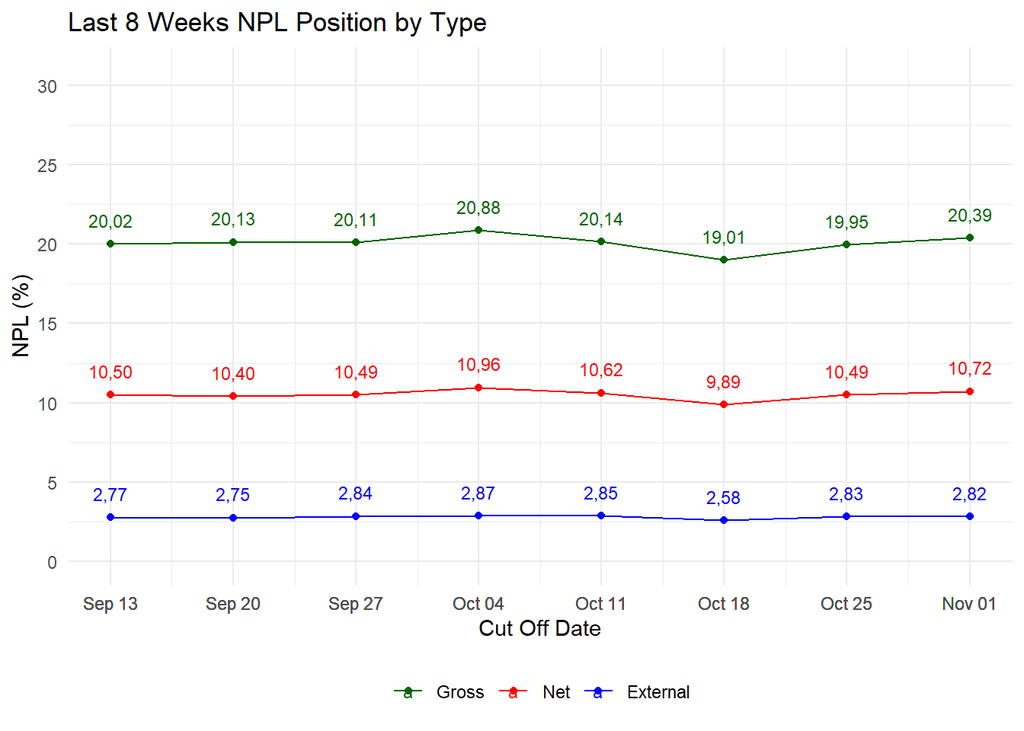

```r
# PLOT 1.6: Last 8 Weeks NPL Position by Type
plot1.6 <- ggplot(GNE_NPL_last_8_weeks, aes(x = cut_off_date,
                    y = NPL,
                    color = NPL_type,
                    group = NPL_type,
                    text = label)) +

  geom_point() +
  geom_line() +
  geom_text(aes(y = NPL + 1.5,
                label = label_number(big.mark = ".",
                                     decimal.mark = ",",
                                     accuracy = 0.01)
                (NPL)),
            size = 3) +
  scale_x_date(
    breaks = GNE_NPL_last_8_weeks$cut_off_date,
    date_labels = "%b %d"
  ) +
  scale_y_continuous(
    limits = c(0, max(GNE_NPL_last_8_weeks$NPL) + 10),
    breaks = seq(0,100,5)
  ) +
  scale_color_manual(values = c(
    "Gross" = "darkgreen",
    "Net" = "red",
    "External" = "blue"),
    name = NULL) +
  labs(title = "Last 8 Weeks NPL Position by Type",
       x = "Cut Off Date",
       y = "NPL (%)",
       color = "NPL Type") +
  theme_minimal() +
  theme(legend.position = "bottom")

plot1.6
```

```r
# This is for interactive plot
# ggplotly(plot1.6, tooltip = "text") %>%
#   layout(legend = list(
#     orientation = "h",
#     y = -0.3
#   ))
```

The chart presents the **NPL** trend over the **last 8 weeks**, separated by **Gross**, **Net**, and **External** types.

- **Gross NPL** remained relatively stable, fluctuating slightly between **19.01%** and **20.88%**, ending at **20.39%** on **1 November 2025**.
- **Net NPL** showed minor variation, with a low of **9.89%** and peaking at **10.96%**, finishing at **10.72%**.
- **External NPL** stayed consistently low, ranging from **2.58%** to **2.87%**, ending at **2.82%**.

Overall, the **NPL levels remained steady** across all types, with **Net and Gross NPL** showing a slight **upward movement** toward the end of the period.

## Line 7 (Gross, Net, and External NPL Trends Over the Last 4 Months)

Next, I’ll create a **line plot** to visualize the **national NPL trend** over the last 4 months by using the latest recorded cut-off date from each month across all NPL types (`Gross`, `Net`, and `External`).

### PLOT 1.7: (line plot)

“Last 4 Months NPL Position ~ Date vs NPL (%)”

```r
# Dataset: Gross, Net, and External
sqllab_gross_clean
```

```
#> # A tibble: 135,420 × 11
#>    cut_off_date island region area  branch bucket   noa outstanding_amount  date
#>    <date>       <fct>  <fct>  <fct> <fct>  <fct>  <int>              <dbl> <int>
#>  1 2025-11-01   Sumat… Aceh   Aceh… Aceh … 01. C…    53          91784130.     1
#>  2 2025-11-01   Sumat… Aceh   Aceh… Aceh … 02. 1…   185         254273192.     1
#>  3 2025-11-01   Sumat… Aceh   Aceh… Aceh … 03. 3…   173         431221028.     1
#>  4 2025-11-01   Sumat… Aceh   Aceh… Aceh … 04. 6…   271        1326525315.     1
#>  5 2025-11-01   Sumat… Aceh   Aceh… Aceh … 05. 9…   119         557134482.     1
#>  6 2025-11-01   Sumat… Aceh   Aceh… Aceh … 01. C…   176         836408397.     1
#>  7 2025-11-01   Sumat… Aceh   Aceh… Aceh … 02. 1…   443         850066868.     1
#>  8 2025-11-01   Sumat… Aceh   Aceh… Aceh … 03. 3…   369        1051253334.     1
#>  9 2025-11-01   Sumat… Aceh   Aceh… Aceh … 04. 6…   386         920064468.     1
#> 10 2025-11-01   Sumat… Aceh   Aceh… Aceh … 05. 9…   148         702017007.     1
#> # ℹ 135,410 more rows
#> # ℹ 2 more variables: month <dbl>, year <dbl>
```

```r
sqllab_net_clean
```

```
#> # A tibble: 135,420 × 11
#>    cut_off_date island region area  branch bucket   noa outstanding_amount  date
#>    <date>       <fct>  <fct>  <fct> <fct>  <fct>  <int>              <dbl> <int>
#>  1 2025-11-01   Sumat… Aceh   Aceh… Aceh … 01. C…    53          76934000.     1
#>  2 2025-11-01   Sumat… Aceh   Aceh… Aceh … 02. 1…   185         218410473.     1
#>  3 2025-11-01   Sumat… Aceh   Aceh… Aceh … 03. 3…   173         317760703.     1
#>  4 2025-11-01   Sumat… Aceh   Aceh… Aceh … 04. 6…   271         811554170.     1
#>  5 2025-11-01   Sumat… Aceh   Aceh… Aceh … 05. 9…   119         271330064.     1
#>  6 2025-11-01   Sumat… Aceh   Aceh… Aceh … 01. C…   176         581834603.     1
#>  7 2025-11-01   Sumat… Aceh   Aceh… Aceh … 02. 1…   443         748995851.     1
#>  8 2025-11-01   Sumat… Aceh   Aceh… Aceh … 03. 3…   369         877552083.     1
#>  9 2025-11-01   Sumat… Aceh   Aceh… Aceh … 04. 6…   386         558000043.     1
#> 10 2025-11-01   Sumat… Aceh   Aceh… Aceh … 05. 9…   148         335235117.     1
#> # ℹ 135,410 more rows
#> # ℹ 2 more variables: month <dbl>, year <dbl>
```

```r
sqllab_external_clean
```

```
#> # A tibble: 135,420 × 11
#>    cut_off_date island region area  branch bucket   noa outstanding_amount  date
#>    <date>       <fct>  <fct>  <fct> <fct>  <fct>  <int>              <dbl> <int>
#>  1 2025-11-01   Sumat… Aceh   Aceh… Aceh … 01. C…    53          64398309.     1
#>  2 2025-11-01   Sumat… Aceh   Aceh… Aceh … 02. 1…   185         206470008.     1
#>  3 2025-11-01   Sumat… Aceh   Aceh… Aceh … 03. 3…   173         231682208.     1
#>  4 2025-11-01   Sumat… Aceh   Aceh… Aceh … 04. 6…   271         648403168.     1
#>  5 2025-11-01   Sumat… Aceh   Aceh… Aceh … 05. 9…   119          50133476.     1
#>  6 2025-11-01   Sumat… Aceh   Aceh… Aceh … 01. C…   176         458579814.     1
#>  7 2025-11-01   Sumat… Aceh   Aceh… Aceh … 02. 1…   443         553795359.     1
#>  8 2025-11-01   Sumat… Aceh   Aceh… Aceh … 03. 3…   369         827679983.     1
#>  9 2025-11-01   Sumat… Aceh   Aceh… Aceh … 04. 6…   386         511141034.     1
#> 10 2025-11-01   Sumat… Aceh   Aceh… Aceh … 05. 9…   148          47998959.     1
#> # ℹ 135,410 more rows
#> # ℹ 2 more variables: month <dbl>, year <dbl>
```

The same as the previous step, firstly, we’re going to calculate the *Gross NPL value* for each *island* across every *cut-off date*.

```r
# Data Wrangling: Gross NPL for each island & cut off date
gross_NPL_last_4_months <- gross_DPD_90 %>%
  inner_join(gross_total_outstanding2, by = c("cut_off_date", "island")) %>%
  mutate(
    Gross = round((DPD_90 / total_outstanding_amount * 100),2),
    Date = factor(
      format(cut_off_date, "%d %b %Y"),
      levels = format(sort(unique(cut_off_date)),"%d %b %Y"))
  ) %>%
  select (-c(date.x, date.y)) %>%
  arrange(desc(cut_off_date)) %>%
  filter(cut_off_date <= "2025-11-01")

gross_NPL_last_4_months
```

```
#> # A tibble: 427 × 6
#>    cut_off_date island                 DPD_90 total_outstanding_am…¹ Gross Date
#>    <date>       <fct>                   <dbl>                  <dbl> <dbl> <fct>
#>  1 2025-11-01   Bali & Nusa Tenggara  3.10e10          143791078634.  21.6 01 N…
#>  2 2025-11-01   Jawa                  6.41e10          305058385753.  21.0 01 N…
#>  3 2025-11-01   Kalimantan            4.71e10          259755858198.  18.1 01 N…
#>  4 2025-11-01   Maluku                2.14e10           95847719915.  22.3 01 N…
#>  5 2025-11-01   Papua                 5.57e10          244322416284.  22.8 01 N…
#>  6 2025-11-01   Sulawesi              5.61e10          294961035802.  19.0 01 N…
#>  7 2025-11-01   Sumatera              9.79e10          487478246847.  20.1 01 N…
#>  8 2025-10-25   Bali & Nusa Tenggara  2.76e10          153656464025.  18.0 25 O…
#>  9 2025-10-25   Jawa                  5.64e10          294687968540.  19.2 25 O…
#> 10 2025-10-25   Kalimantan            5.30e10          248424159664.  21.4 25 O…
#> # ℹ 417 more rows
#> # ℹ abbreviated name: ¹total_outstanding_amount
```

Then, we derive the *national Gross NPL value* for each *cut-off date*.

```r
# National Gross NPL value for each cut off date
gross_NPL_last_4_months <- gross_NPL_last_4_months %>%
  group_by(cut_off_date) %>%
  summarise(Gross= round((sum(DPD_90)/sum(total_outstanding_amount)*100),2)) %>%
  ungroup() %>%
  arrange(desc(cut_off_date))

gross_NPL_last_4_months
```

```
#> # A tibble: 61 × 2
#>    cut_off_date Gross
#>    <date>       <dbl>
#>  1 2025-11-01    20.4
#>  2 2025-10-25    20.0
#>  3 2025-10-18    19.0
#>  4 2025-10-11    20.1
#>  5 2025-10-04    20.9
#>  6 2025-09-27    20.1
#>  7 2025-09-20    20.1
#>  8 2025-09-13    20.0
#>  9 2025-09-06    20.2
#> 10 2025-08-30    20.2
#> # ℹ 51 more rows
```

The same as the Gross dataset, we’re going to calculate the *Net NPL value* for each *island* across every *cut-off date*.

```r
# Data Wrangling: Net NPL for each island & cut off date
net_NPL_last_4_months <- net_DPD_90 %>%
  inner_join(net_total_outstanding2, by = c("cut_off_date", "island")) %>%
  mutate(
    Net = round((DPD_90 / total_outstanding_amount * 100),2),
    Date = factor(
      format(cut_off_date, "%d %b %Y"),
      levels = format(sort(unique(cut_off_date)),"%d %b %Y"))
  ) %>%
  select (-c(date.x, date.y)) %>%
  arrange(desc(cut_off_date)) %>%
  filter(cut_off_date <= "2025-11-01")

net_NPL_last_4_months
```

```
#> # A tibble: 427 × 6
#>    cut_off_date island                 DPD_90 total_outstanding_am…¹   Net Date
#>    <date>       <fct>                   <dbl>                  <dbl> <dbl> <fct>
#>  1 2025-11-01   Bali & Nusa Tenggara  1.10e10           95070042667. 11.5  01 N…
#>  2 2025-11-01   Jawa                  2.25e10          205579088033. 11.0  01 N…
#>  3 2025-11-01   Kalimantan            1.60e10          176411648216.  9.05 01 N…
#>  4 2025-11-01   Maluku                7.60e 9           64200464734. 11.8  01 N…
#>  5 2025-11-01   Papua                 1.86e10          159773648683. 11.7  01 N…
#>  6 2025-11-01   Sulawesi              2.05e10          199024648131. 10.3  01 N…
#>  7 2025-11-01   Sumatera              3.55e10          327494137949. 10.8  01 N…
#>  8 2025-10-25   Bali & Nusa Tenggara  9.95e 9          104033344709.  9.56 25 O…
#>  9 2025-10-25   Jawa                  2.12e10          198472628731. 10.7  25 O…
#> 10 2025-10-25   Kalimantan            1.86e10          167940849035. 11.1  25 O…
#> # ℹ 417 more rows
#> # ℹ abbreviated name: ¹total_outstanding_amount
```

Then, we derive the *national Net NPL value* for each *cut-off date*.

```r
# National Net NPL value for each cut off date
net_NPL_last_4_months <- net_NPL_last_4_months %>%
  group_by(cut_off_date) %>%
  summarise(Net= round((sum(DPD_90)/sum(total_outstanding_amount)*100),2)) %>%
  ungroup() %>%
  arrange(desc(cut_off_date))

net_NPL_last_4_months
```

```
#> # A tibble: 61 × 2
#>    cut_off_date   Net
#>    <date>       <dbl>
#>  1 2025-11-01   10.7
#>  2 2025-10-25   10.5
#>  3 2025-10-18    9.89
#>  4 2025-10-11   10.6
#>  5 2025-10-04   11.0
#>  6 2025-09-27   10.5
#>  7 2025-09-20   10.4
#>  8 2025-09-13   10.5
#>  9 2025-09-06   10.5
#> 10 2025-08-30   10.7
#> # ℹ 51 more rows
```

Lastly, we’re going to calculate the *External NPL value* for each *island* across every *cut-off date*.

```r
# Data Wrangling: External NPL for each island & cut off date
external_NPL_last_4_months <- external_DPD_90 %>%
  inner_join(external_total_outstanding2, by = c("cut_off_date", "island")) %>%
  mutate(
    External = round((DPD_90 / total_outstanding_amount * 100),2),
    Date = factor(
      format(cut_off_date, "%d %b %Y"),
      levels = format(sort(unique(cut_off_date)),"%d %b %Y"))
  ) %>%
  select (-c(date.x, date.y)) %>%
  arrange(desc(cut_off_date)) %>%
  filter(cut_off_date <= "2025-11-01")

external_NPL_last_4_months
```

```
#> # A tibble: 427 × 6
#>    cut_off_date island              DPD_90 total_outstanding_am…¹ External Date
#>    <date>       <fct>                <dbl>                  <dbl>    <dbl> <fct>
#>  1 2025-11-01   Bali & Nusa Tengga… 2.31e9           71226252420.     3.24 01 N…
#>  2 2025-11-01   Jawa                4.68e9          156117687350.     3    01 N…
#>  3 2025-11-01   Kalimantan          3.15e9          135307784341.     2.33 01 N…
#>  4 2025-11-01   Maluku              1.44e9           49013872412.     2.93 01 N…
#>  5 2025-11-01   Papua               3.65e9          120467879306.     3.03 01 N…
#>  6 2025-11-01   Sulawesi            4.16e9          151287046551.     2.75 01 N…
#>  7 2025-11-01   Sumatera            6.81e9          245719756420.     2.77 01 N…
#>  8 2025-10-25   Bali & Nusa Tengga… 2.09e9           79929170711.     2.61 25 O…
#>  9 2025-10-25   Jawa                4.22e9          149145882346.     2.83 25 O…
#> 10 2025-10-25   Kalimantan          3.81e9          127755024506.     2.99 25 O…
#> # ℹ 417 more rows
#> # ℹ abbreviated name: ¹total_outstanding_amount
```

We also derive the *national External NPL value* for each *cut-off date*.

```r
# National External NPL value for each cut off date
external_NPL_last_4_months <- external_NPL_last_4_months %>%
  group_by(cut_off_date) %>%
  summarise(External= round((sum(DPD_90)/sum(total_outstanding_amount)*100),2)) %>%
  ungroup() %>%
  arrange(desc(cut_off_date))

external_NPL_last_4_months
```

```
#> # A tibble: 61 × 2
#>    cut_off_date External
#>    <date>          <dbl>
#>  1 2025-11-01       2.82
#>  2 2025-10-25       2.83
#>  3 2025-10-18       2.58
#>  4 2025-10-11       2.85
#>  5 2025-10-04       2.87
#>  6 2025-09-27       2.84
#>  7 2025-09-20       2.75
#>  8 2025-09-13       2.77
#>  9 2025-09-06       2.85
#> 10 2025-08-30       2.75
#> # ℹ 51 more rows
```

We also need to **merge all the Gross, Net, and External NPL values into a single dataset** to make it neater for the next step.

```r
# Merging Gross, Net, and External national NPL values into one dataset
GNE_NPL_last_4_months <- gross_NPL_last_4_months %>%
  inner_join(net_NPL_last_4_months, by = c("cut_off_date")) %>%
  inner_join(external_NPL_last_4_months, by = c("cut_off_date")) %>%
  mutate(
    Date = factor(
      format(cut_off_date, "%d %b %Y"),
      levels = format(sort(unique(cut_off_date)),"%d %b %Y"))
  ) %>%
  arrange(desc(cut_off_date))

GNE_NPL_last_4_months
```

```
#> # A tibble: 61 × 5
#>    cut_off_date Gross   Net External Date
#>    <date>       <dbl> <dbl>    <dbl> <fct>
#>  1 2025-11-01    20.4 10.7      2.82 01 Nov 2025
#>  2 2025-10-25    20.0 10.5      2.83 25 Oct 2025
#>  3 2025-10-18    19.0  9.89     2.58 18 Oct 2025
#>  4 2025-10-11    20.1 10.6      2.85 11 Oct 2025
#>  5 2025-10-04    20.9 11.0      2.87 04 Oct 2025
#>  6 2025-09-27    20.1 10.5      2.84 27 Sep 2025
#>  7 2025-09-20    20.1 10.4      2.75 20 Sep 2025
#>  8 2025-09-13    20.0 10.5      2.77 13 Sep 2025
#>  9 2025-09-06    20.2 10.5      2.85 06 Sep 2025
#> 10 2025-08-30    20.2 10.7      2.75 30 Aug 2025
#> # ℹ 51 more rows
```

Now, we want to **obtain the national NPL values for the last 4 months**.

To take the NPL values from the **last cut-off date of each month**, we first need to **add separate columns for date, month, and year** based on the existing **cut-off date**.

```r
# Adding date, month, and year column
GNE_NPL_last_4_months <- GNE_NPL_last_4_months %>%
  mutate(
    date = day(cut_off_date),
    month = floor_date(cut_off_date, "month"),
    year = year(cut_off_date)
    ) %>%
  arrange(desc(cut_off_date))

GNE_NPL_last_4_months
```

```
#> # A tibble: 61 × 8
#>    cut_off_date Gross   Net External Date         date month       year
#>    <date>       <dbl> <dbl>    <dbl> <fct>       <int> <date>     <dbl>
#>  1 2025-11-01    20.4 10.7      2.82 01 Nov 2025     1 2025-11-01  2025
#>  2 2025-10-25    20.0 10.5      2.83 25 Oct 2025    25 2025-10-01  2025
#>  3 2025-10-18    19.0  9.89     2.58 18 Oct 2025    18 2025-10-01  2025
#>  4 2025-10-11    20.1 10.6      2.85 11 Oct 2025    11 2025-10-01  2025
#>  5 2025-10-04    20.9 11.0      2.87 04 Oct 2025     4 2025-10-01  2025
#>  6 2025-09-27    20.1 10.5      2.84 27 Sep 2025    27 2025-09-01  2025
#>  7 2025-09-20    20.1 10.4      2.75 20 Sep 2025    20 2025-09-01  2025
#>  8 2025-09-13    20.0 10.5      2.77 13 Sep 2025    13 2025-09-01  2025
#>  9 2025-09-06    20.2 10.5      2.85 06 Sep 2025     6 2025-09-01  2025
#> 10 2025-08-30    20.2 10.7      2.75 30 Aug 2025    30 2025-08-01  2025
#> # ℹ 51 more rows
```

Then, we only need to **select the maximum cut-off date for each month**, and **filter the data to include only the last 4 months**.

```r
# Retrieve the maximum date from each month and filter only for the last 4 months
GNE_NPL_last_4_months <- GNE_NPL_last_4_months %>%
  group_by(month) %>%
  filter(cut_off_date <= "2025-11-01") %>%
  filter(date == max(date)) %>%
  ungroup() %>%
  head(4)

GNE_NPL_last_4_months
```

```
#> # A tibble: 4 × 8
#>   cut_off_date Gross   Net External Date         date month       year
#>   <date>       <dbl> <dbl>    <dbl> <fct>       <int> <date>     <dbl>
#> 1 2025-11-01    20.4  10.7     2.82 01 Nov 2025     1 2025-11-01  2025
#> 2 2025-10-25    20.0  10.5     2.83 25 Oct 2025    25 2025-10-01  2025
#> 3 2025-09-27    20.1  10.5     2.84 27 Sep 2025    27 2025-09-01  2025
#> 4 2025-08-30    20.2  10.7     2.75 30 Aug 2025    30 2025-08-01  2025
```

Next, it’s time to **pivot the dataset** to make it easier to visualize.

```r
# Pivot and adding NPL type column
GNE_NPL_last_4_months <- GNE_NPL_last_4_months %>%
  pivot_longer(
    cols = c(Gross, Net, External),
    names_to = "NPL_type",
    values_to = "NPL"
  ) %>%
  mutate(NPL_type = factor(NPL_type, levels = c("Gross", "Net", "External")))

GNE_NPL_last_4_months
```

```
#> # A tibble: 12 × 7
#>    cut_off_date Date         date month       year NPL_type   NPL
#>    <date>       <fct>       <int> <date>     <dbl> <fct>    <dbl>
#>  1 2025-11-01   01 Nov 2025     1 2025-11-01  2025 Gross    20.4
#>  2 2025-11-01   01 Nov 2025     1 2025-11-01  2025 Net      10.7
#>  3 2025-11-01   01 Nov 2025     1 2025-11-01  2025 External  2.82
#>  4 2025-10-25   25 Oct 2025    25 2025-10-01  2025 Gross    20.0
#>  5 2025-10-25   25 Oct 2025    25 2025-10-01  2025 Net      10.5
#>  6 2025-10-25   25 Oct 2025    25 2025-10-01  2025 External  2.83
#>  7 2025-09-27   27 Sep 2025    27 2025-09-01  2025 Gross    20.1
#>  8 2025-09-27   27 Sep 2025    27 2025-09-01  2025 Net      10.5
#>  9 2025-09-27   27 Sep 2025    27 2025-09-01  2025 External  2.84
#> 10 2025-08-30   30 Aug 2025    30 2025-08-01  2025 Gross    20.2
#> 11 2025-08-30   30 Aug 2025    30 2025-08-01  2025 Net      10.7
#> 12 2025-08-30   30 Aug 2025    30 2025-08-01  2025 External  2.75
```

```r
# tooltip
GNE_NPL_last_4_months <- GNE_NPL_last_4_months %>%
  mutate(
    label = glue(
      "NPL: {number(NPL,  big.mark = '.', decimal.mark = ',', accuracy = 0.01)}%
      Cut Off Date: {format(as.Date(cut_off_date), '%d %b %Y')}"
    )
  )
GNE_NPL_last_4_months
```

```
#> # A tibble: 12 × 8
#>    cut_off_date Date         date month       year NPL_type   NPL label
#>    <date>       <fct>       <int> <date>     <dbl> <fct>    <dbl> <glue>
#>  1 2025-11-01   01 Nov 2025     1 2025-11-01  2025 Gross    20.4  NPL: 20,39%
#> C…
#>  2 2025-11-01   01 Nov 2025     1 2025-11-01  2025 Net      10.7  NPL: 10,72%
#> C…
#>  3 2025-11-01   01 Nov 2025     1 2025-11-01  2025 External  2.82 NPL: 2,82%
#> Cu…
#>  4 2025-10-25   25 Oct 2025    25 2025-10-01  2025 Gross    20.0  NPL: 19,95%
#> C…
#>  5 2025-10-25   25 Oct 2025    25 2025-10-01  2025 Net      10.5  NPL: 10,49%
#> C…
#>  6 2025-10-25   25 Oct 2025    25 2025-10-01  2025 External  2.83 NPL: 2,83%
#> Cu…
#>  7 2025-09-27   27 Sep 2025    27 2025-09-01  2025 Gross    20.1  NPL: 20,11%
#> C…
#>  8 2025-09-27   27 Sep 2025    27 2025-09-01  2025 Net      10.5  NPL: 10,49%
#> C…
#>  9 2025-09-27   27 Sep 2025    27 2025-09-01  2025 External  2.84 NPL: 2,84%
#> Cu…
#> 10 2025-08-30   30 Aug 2025    30 2025-08-01  2025 Gross    20.2  NPL: 20,22%
#> C…
#> 11 2025-08-30   30 Aug 2025    30 2025-08-01  2025 Net      10.7  NPL: 10,70%
#> C…
#> 12 2025-08-30   30 Aug 2025    30 2025-08-01  2025 External  2.75 NPL: 2,75%
#> Cu…
```

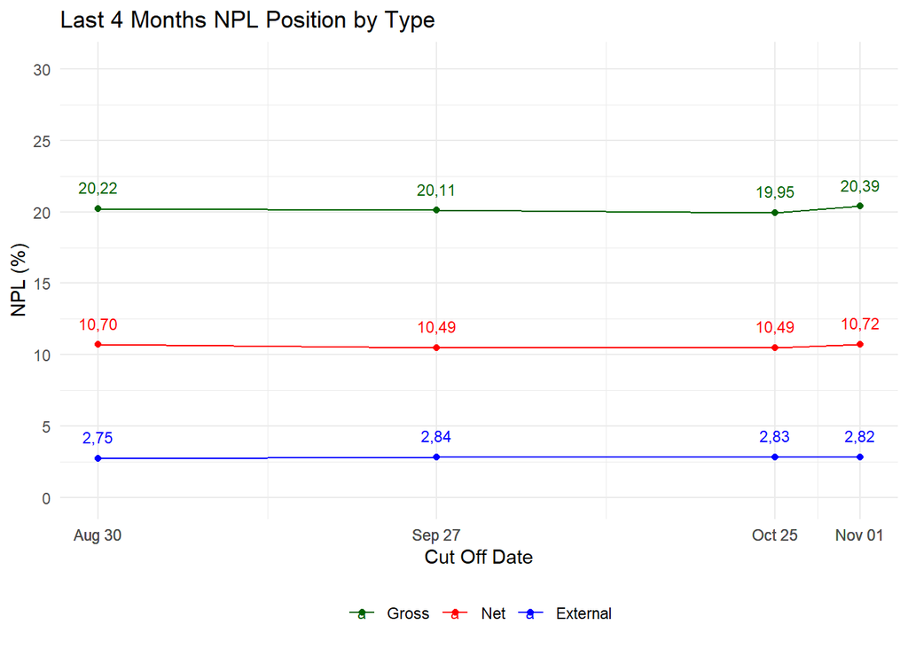

```r
# PLOT 1.7: Last 4 Months NPL Position by Type
plot1.7 <- ggplot(GNE_NPL_last_4_months, aes(x = cut_off_date,
                    y = NPL,
                    color = NPL_type,
                    group = NPL_type,
                    text = label)) +

  geom_point() +
  geom_line() +
  geom_text(aes(y = NPL + 1.5,
                label = label_number(big.mark = ".",
                                     decimal.mark = ",",
                                     accuracy = 0.01)
                (NPL)),
            size = 3) +
  scale_x_date(
    breaks = GNE_NPL_last_4_months$cut_off_date,
    date_labels = "%b %d"
  ) +
  scale_y_continuous(
    limits = c(0, max(GNE_NPL_last_4_months$NPL) + 10),
    breaks = seq(0,100,5)
  ) +
  scale_color_manual(values = c(
    "Gross" = "darkgreen",
    "Net" = "red",
    "External" = "blue"),
    name = NULL) +
  labs(title = "Last 4 Months NPL Position by Type",
       x = "Cut Off Date",
       y = "NPL (%)",
       color = "NPL Type") +
  theme_minimal() +
  theme(legend.position = "bottom")

plot1.7
```

```r
# This is for interactive plot
# ggplotly(plot1.7, tooltip = "text") %>%
#   layout(legend = list(
#     orientation = "h",
#     y = -0.3
#   ))
```

The chart illustrates the **NPL** trend over the **past 4 months** for **Gross**, **Net**, and **External** portfolios.

- **Gross NPL** remained relatively stable, moving slightly from **20.22% (Aug 30)** to **20.39% (Nov 1)**.
- **Net NPL** showed a mild decline from **10.70%** in **August** to **10.49%** in **September**, before rising again to **10.72%** in **November**.
- **External NPL** stayed consistently low and stable, ranging narrowly between **2.75%** and **2.84%**.

Overall, **Gross and Net NPLs** indicate **minor fluctuations** but no significant changes, suggesting **portfolio quality remained steady** throughout the observed period.

##Line 8 (Gross, Net, and External NPL Trends Over the Last 4 Quartals)

Next, I’ll create a **line plot** to visualize the **national NPL trend** over the last 4 quarters using the latest recorded cut-off date from each quarter across all NPL types (`Gross`, `Net`, and `External`).

###PLOT 1.8: (line plot) “Last 4 Quartal ~ Date vs NPL (%)”

```r
# Dataset: Gross, Net, and External
sqllab_gross_clean
```

```
#> # A tibble: 135,420 × 11
#>    cut_off_date island region area  branch bucket   noa outstanding_amount  date
#>    <date>       <fct>  <fct>  <fct> <fct>  <fct>  <int>              <dbl> <int>
#>  1 2025-11-01   Sumat… Aceh   Aceh… Aceh … 01. C…    53          91784130.     1
#>  2 2025-11-01   Sumat… Aceh   Aceh… Aceh … 02. 1…   185         254273192.     1
#>  3 2025-11-01   Sumat… Aceh   Aceh… Aceh … 03. 3…   173         431221028.     1
#>  4 2025-11-01   Sumat… Aceh   Aceh… Aceh … 04. 6…   271        1326525315.     1
#>  5 2025-11-01   Sumat… Aceh   Aceh… Aceh … 05. 9…   119         557134482.     1
#>  6 2025-11-01   Sumat… Aceh   Aceh… Aceh … 01. C…   176         836408397.     1
#>  7 2025-11-01   Sumat… Aceh   Aceh… Aceh … 02. 1…   443         850066868.     1
#>  8 2025-11-01   Sumat… Aceh   Aceh… Aceh … 03. 3…   369        1051253334.     1
#>  9 2025-11-01   Sumat… Aceh   Aceh… Aceh … 04. 6…   386         920064468.     1
#> 10 2025-11-01   Sumat… Aceh   Aceh… Aceh … 05. 9…   148         702017007.     1
#> # ℹ 135,410 more rows
#> # ℹ 2 more variables: month <dbl>, year <dbl>
```

```r
sqllab_net_clean
```

```
#> # A tibble: 135,420 × 11
#>    cut_off_date island region area  branch bucket   noa outstanding_amount  date
#>    <date>       <fct>  <fct>  <fct> <fct>  <fct>  <int>              <dbl> <int>
#>  1 2025-11-01   Sumat… Aceh   Aceh… Aceh … 01. C…    53          76934000.     1
#>  2 2025-11-01   Sumat… Aceh   Aceh… Aceh … 02. 1…   185         218410473.     1
#>  3 2025-11-01   Sumat… Aceh   Aceh… Aceh … 03. 3…   173         317760703.     1
#>  4 2025-11-01   Sumat… Aceh   Aceh… Aceh … 04. 6…   271         811554170.     1
#>  5 2025-11-01   Sumat… Aceh   Aceh… Aceh … 05. 9…   119         271330064.     1
#>  6 2025-11-01   Sumat… Aceh   Aceh… Aceh … 01. C…   176         581834603.     1
#>  7 2025-11-01   Sumat… Aceh   Aceh… Aceh … 02. 1…   443         748995851.     1
#>  8 2025-11-01   Sumat… Aceh   Aceh… Aceh … 03. 3…   369         877552083.     1
#>  9 2025-11-01   Sumat… Aceh   Aceh… Aceh … 04. 6…   386         558000043.     1
#> 10 2025-11-01   Sumat… Aceh   Aceh… Aceh … 05. 9…   148         335235117.     1
#> # ℹ 135,410 more rows
#> # ℹ 2 more variables: month <dbl>, year <dbl>
```

```r
sqllab_external_clean
```

```
#> # A tibble: 135,420 × 11
#>    cut_off_date island region area  branch bucket   noa outstanding_amount  date
#>    <date>       <fct>  <fct>  <fct> <fct>  <fct>  <int>              <dbl> <int>
#>  1 2025-11-01   Sumat… Aceh   Aceh… Aceh … 01. C…    53          64398309.     1
#>  2 2025-11-01   Sumat… Aceh   Aceh… Aceh … 02. 1…   185         206470008.     1
#>  3 2025-11-01   Sumat… Aceh   Aceh… Aceh … 03. 3…   173         231682208.     1
#>  4 2025-11-01   Sumat… Aceh   Aceh… Aceh … 04. 6…   271         648403168.     1
#>  5 2025-11-01   Sumat… Aceh   Aceh… Aceh … 05. 9…   119          50133476.     1
#>  6 2025-11-01   Sumat… Aceh   Aceh… Aceh … 01. C…   176         458579814.     1
#>  7 2025-11-01   Sumat… Aceh   Aceh… Aceh … 02. 1…   443         553795359.     1
#>  8 2025-11-01   Sumat… Aceh   Aceh… Aceh … 03. 3…   369         827679983.     1
#>  9 2025-11-01   Sumat… Aceh   Aceh… Aceh … 04. 6…   386         511141034.     1
#> 10 2025-11-01   Sumat… Aceh   Aceh… Aceh … 05. 9…   148          47998959.     1
#> # ℹ 135,410 more rows
#> # ℹ 2 more variables: month <dbl>, year <dbl>
```

Now, to create a plot for the last 4 quarters, we need to perform the same data wrangling process for the Gross, Net, and External datasets as we did previously.

```r
# Data Wrangling: Gross NPL for each island & cut off date
gross_NPL_last_4_quartals <- gross_DPD_90 %>%
  inner_join(gross_total_outstanding2, by = c("cut_off_date", "island")) %>%
  mutate(
    Gross = round((DPD_90 / total_outstanding_amount * 100),2),
    Date = factor(
      format(cut_off_date, "%d %b %Y"),
      levels = format(sort(unique(cut_off_date)),"%d %b %Y"))
  ) %>%
  select (-c(date.x, date.y)) %>%
  arrange(desc(cut_off_date)) %>%
  filter(cut_off_date <= "2025-11-01")

gross_NPL_last_4_quartals
```

```
#> # A tibble: 427 × 6
#>    cut_off_date island                 DPD_90 total_outstanding_am…¹ Gross Date
#>    <date>       <fct>                   <dbl>                  <dbl> <dbl> <fct>
#>  1 2025-11-01   Bali & Nusa Tenggara  3.10e10          143791078634.  21.6 01 N…
#>  2 2025-11-01   Jawa                  6.41e10          305058385753.  21.0 01 N…
#>  3 2025-11-01   Kalimantan            4.71e10          259755858198.  18.1 01 N…
#>  4 2025-11-01   Maluku                2.14e10           95847719915.  22.3 01 N…
#>  5 2025-11-01   Papua                 5.57e10          244322416284.  22.8 01 N…
#>  6 2025-11-01   Sulawesi              5.61e10          294961035802.  19.0 01 N…
#>  7 2025-11-01   Sumatera              9.79e10          487478246847.  20.1 01 N…
#>  8 2025-10-25   Bali & Nusa Tenggara  2.76e10          153656464025.  18.0 25 O…
#>  9 2025-10-25   Jawa                  5.64e10          294687968540.  19.2 25 O…
#> 10 2025-10-25   Kalimantan            5.30e10          248424159664.  21.4 25 O…
#> # ℹ 417 more rows
#> # ℹ abbreviated name: ¹total_outstanding_amount
```

```r
# National Gross NPL value for each cut off date
gross_NPL_last_4_quartals <- gross_NPL_last_4_quartals %>%
  group_by(cut_off_date) %>%
  summarise(Gross= round((sum(DPD_90)/sum(total_outstanding_amount)*100),2)) %>%
  ungroup() %>%
  arrange(desc(cut_off_date))

gross_NPL_last_4_quartals
```

```
#> # A tibble: 61 × 2
#>    cut_off_date Gross
#>    <date>       <dbl>
#>  1 2025-11-01    20.4
#>  2 2025-10-25    20.0
#>  3 2025-10-18    19.0
#>  4 2025-10-11    20.1
#>  5 2025-10-04    20.9
#>  6 2025-09-27    20.1
#>  7 2025-09-20    20.1
#>  8 2025-09-13    20.0
#>  9 2025-09-06    20.2
#> 10 2025-08-30    20.2
#> # ℹ 51 more rows
```

```r
# Data Wrangling: Net NPL for each island & cut off date
net_NPL_last_4_quartals <- net_DPD_90 %>%
  inner_join(net_total_outstanding2, by = c("cut_off_date", "island")) %>%
  mutate(
    Net = round((DPD_90 / total_outstanding_amount * 100),2),
    Date = factor(
      format(cut_off_date, "%d %b %Y"),
      levels = format(sort(unique(cut_off_date)),"%d %b %Y"))
  ) %>%
  select (-c(date.x, date.y)) %>%
  arrange(desc(cut_off_date)) %>%
  filter(cut_off_date <= "2025-11-01")

net_NPL_last_4_quartals
```

```
#> # A tibble: 427 × 6
#>    cut_off_date island                 DPD_90 total_outstanding_am…¹   Net Date
#>    <date>       <fct>                   <dbl>                  <dbl> <dbl> <fct>
#>  1 2025-11-01   Bali & Nusa Tenggara  1.10e10           95070042667. 11.5  01 N…
#>  2 2025-11-01   Jawa                  2.25e10          205579088033. 11.0  01 N…
#>  3 2025-11-01   Kalimantan            1.60e10          176411648216.  9.05 01 N…
#>  4 2025-11-01   Maluku                7.60e 9           64200464734. 11.8  01 N…
#>  5 2025-11-01   Papua                 1.86e10          159773648683. 11.7  01 N…
#>  6 2025-11-01   Sulawesi              2.05e10          199024648131. 10.3  01 N…
#>  7 2025-11-01   Sumatera              3.55e10          327494137949. 10.8  01 N…
#>  8 2025-10-25   Bali & Nusa Tenggara  9.95e 9          104033344709.  9.56 25 O…
#>  9 2025-10-25   Jawa                  2.12e10          198472628731. 10.7  25 O…
#> 10 2025-10-25   Kalimantan            1.86e10          167940849035. 11.1  25 O…
#> # ℹ 417 more rows
#> # ℹ abbreviated name: ¹total_outstanding_amount
```

```r
# National Net NPL value for each cut off date
net_NPL_last_4_quartals <- net_NPL_last_4_quartals %>%
  group_by(cut_off_date) %>%
  summarise(Net= round((sum(DPD_90)/sum(total_outstanding_amount)*100),2)) %>%
  ungroup() %>%
  arrange(desc(cut_off_date))

net_NPL_last_4_quartals
```

```
#> # A tibble: 61 × 2
#>    cut_off_date   Net
#>    <date>       <dbl>
#>  1 2025-11-01   10.7
#>  2 2025-10-25   10.5
#>  3 2025-10-18    9.89
#>  4 2025-10-11   10.6
#>  5 2025-10-04   11.0
#>  6 2025-09-27   10.5
#>  7 2025-09-20   10.4
#>  8 2025-09-13   10.5
#>  9 2025-09-06   10.5
#> 10 2025-08-30   10.7
#> # ℹ 51 more rows
```

```r
# Data Wrangling: External NPL for each island & cut off date
external_NPL_last_4_quartals <- external_DPD_90 %>%
  inner_join(external_total_outstanding2, by = c("cut_off_date", "island")) %>%
  mutate(
    External = round((DPD_90 / total_outstanding_amount * 100),2),
    Date = factor(
      format(cut_off_date, "%d %b %Y"),
      levels = format(sort(unique(cut_off_date)),"%d %b %Y"))
  ) %>%
  select (-c(date.x, date.y)) %>%
  arrange(desc(cut_off_date)) %>%
  filter(cut_off_date <= "2025-11-01")

external_NPL_last_4_quartals
```

```
#> # A tibble: 427 × 6
#>    cut_off_date island              DPD_90 total_outstanding_am…¹ External Date
#>    <date>       <fct>                <dbl>                  <dbl>    <dbl> <fct>
#>  1 2025-11-01   Bali & Nusa Tengga… 2.31e9           71226252420.     3.24 01 N…
#>  2 2025-11-01   Jawa                4.68e9          156117687350.     3    01 N…
#>  3 2025-11-01   Kalimantan          3.15e9          135307784341.     2.33 01 N…
#>  4 2025-11-01   Maluku              1.44e9           49013872412.     2.93 01 N…
#>  5 2025-11-01   Papua               3.65e9          120467879306.     3.03 01 N…
#>  6 2025-11-01   Sulawesi            4.16e9          151287046551.     2.75 01 N…
#>  7 2025-11-01   Sumatera            6.81e9          245719756420.     2.77 01 N…
#>  8 2025-10-25   Bali & Nusa Tengga… 2.09e9           79929170711.     2.61 25 O…
#>  9 2025-10-25   Jawa                4.22e9          149145882346.     2.83 25 O…
#> 10 2025-10-25   Kalimantan          3.81e9          127755024506.     2.99 25 O…
#> # ℹ 417 more rows
#> # ℹ abbreviated name: ¹total_outstanding_amount
```

```r
# National External NPL value for each cut off date
external_NPL_last_4_quartals <- external_NPL_last_4_quartals %>%
  group_by(cut_off_date) %>%
  summarise(External= round((sum(DPD_90)/sum(total_outstanding_amount)*100),2)) %>%
  ungroup() %>%
  arrange(desc(cut_off_date))

external_NPL_last_4_quartals
```

```
#> # A tibble: 61 × 2
#>    cut_off_date External
#>    <date>          <dbl>
#>  1 2025-11-01       2.82
#>  2 2025-10-25       2.83
#>  3 2025-10-18       2.58
#>  4 2025-10-11       2.85
#>  5 2025-10-04       2.87
#>  6 2025-09-27       2.84
#>  7 2025-09-20       2.75
#>  8 2025-09-13       2.77
#>  9 2025-09-06       2.85
#> 10 2025-08-30       2.75
#> # ℹ 51 more rows
```

After obtaining the **Gross**, **Net**, and **External national NPL values**. We need to **merge them into a single dataset** to make it neater for the next step.

```r
# Merging Gross, Net, and External national NPL values into one dataset
GNE_NPL_last_4_quartals <- gross_NPL_last_4_quartals %>%
  inner_join(net_NPL_last_4_quartals, by = c("cut_off_date")) %>%
  inner_join(external_NPL_last_4_quartals, by = c("cut_off_date")) %>%
  mutate(
    Date = factor(
      format(cut_off_date, "%d %b %Y"),
      levels = format(sort(unique(cut_off_date)),"%d %b %Y"))
  ) %>%
  arrange(desc(cut_off_date))

GNE_NPL_last_4_quartals
```

```
#> # A tibble: 61 × 5
#>    cut_off_date Gross   Net External Date
#>    <date>       <dbl> <dbl>    <dbl> <fct>
#>  1 2025-11-01    20.4 10.7      2.82 01 Nov 2025
#>  2 2025-10-25    20.0 10.5      2.83 25 Oct 2025
#>  3 2025-10-18    19.0  9.89     2.58 18 Oct 2025
#>  4 2025-10-11    20.1 10.6      2.85 11 Oct 2025
#>  5 2025-10-04    20.9 11.0      2.87 04 Oct 2025
#>  6 2025-09-27    20.1 10.5      2.84 27 Sep 2025
#>  7 2025-09-20    20.1 10.4      2.75 20 Sep 2025
#>  8 2025-09-13    20.0 10.5      2.77 13 Sep 2025
#>  9 2025-09-06    20.2 10.5      2.85 06 Sep 2025
#> 10 2025-08-30    20.2 10.7      2.75 30 Aug 2025
#> # ℹ 51 more rows
```

Now, we want to specifically **get the national NPL values for the last 4 quartals**.

To take the NPL values from the **last cut-off date of each quartals**, we first need to **add separate columns for date, month, and year** based on the existing **cut-off date**.

```r
# Adding date, month, and year column
GNE_NPL_last_4_quartals <- GNE_NPL_last_4_quartals %>%
  mutate(
    date = day(cut_off_date),
    month = floor_date(cut_off_date, "month"),
    year = year(cut_off_date)
    ) %>%
  arrange(desc(cut_off_date))

GNE_NPL_last_4_quartals
```

```
#> # A tibble: 61 × 8
#>    cut_off_date Gross   Net External Date         date month       year
#>    <date>       <dbl> <dbl>    <dbl> <fct>       <int> <date>     <dbl>
#>  1 2025-11-01    20.4 10.7      2.82 01 Nov 2025     1 2025-11-01  2025
#>  2 2025-10-25    20.0 10.5      2.83 25 Oct 2025    25 2025-10-01  2025
#>  3 2025-10-18    19.0  9.89     2.58 18 Oct 2025    18 2025-10-01  2025
#>  4 2025-10-11    20.1 10.6      2.85 11 Oct 2025    11 2025-10-01  2025
#>  5 2025-10-04    20.9 11.0      2.87 04 Oct 2025     4 2025-10-01  2025
#>  6 2025-09-27    20.1 10.5      2.84 27 Sep 2025    27 2025-09-01  2025
#>  7 2025-09-20    20.1 10.4      2.75 20 Sep 2025    20 2025-09-01  2025
#>  8 2025-09-13    20.0 10.5      2.77 13 Sep 2025    13 2025-09-01  2025
#>  9 2025-09-06    20.2 10.5      2.85 06 Sep 2025     6 2025-09-01  2025
#> 10 2025-08-30    20.2 10.7      2.75 30 Aug 2025    30 2025-08-01  2025
#> # ℹ 51 more rows
```

To identify the *quarter* of each *cut-off date*, we’ll create a *function* that labels it according to its *month*.

```r
# Function to determine Q1–Q4: Quarter
quartal <- function(x)
  {
  if(x == 3)
    {
    z <- "Q1" # returns "Q1" if the value of x is 3 (March)
    }
  else if(x == 6)
    {
    z <- "Q2" # returns "Q2" if the value of x is 6 (June)
    }
  else if(x == 9)
    {
    z <- "Q3" # returns "Q3" if the value of x is 9 (September)
    }
  else
    {
    z <- "Q4" # returns "Q4" if the value of x is 12 (December)
    }
  }
```

```r
# Example: trying out the "quartal" function above
print(quartal(6))
```

```
#> [1] "Q2"
```

When the input value is 6 (June), the function correctly returns Q2, which represents the second quarter.

Now, we need to *apply the Quartal function* to identify which quarter each cut-off date belongs to. We will then *filter the dataset* to include only the months *March (3), June (6), September (9),* and *December (12)* to ensure that only the end-of-quarter data is used.

We also want to make sure to *include only the maximum date of each quarter* and *take only the most recent year*, ensuring that we are using *the latest available quarterly data*.

```r
# Applying the Quartal function to extract only the most recent date from each quarter
GNE_NPL_last_4_quartals <- GNE_NPL_last_4_quartals %>%
  mutate(
    month_num = month(cut_off_date),
    quartal = sapply(month_num, quartal)
  ) %>%
  filter(cut_off_date <= "2025-11-01") %>%
  filter(
    month_num %in% c("3", "6", "9", "12"),
  ) %>%
  group_by(quartal) %>%
  filter(year == max(year)) %>%
  group_by(month_num) %>%
  filter(date == max(date)) %>%
  ungroup() %>%
  arrange(desc(cut_off_date))

GNE_NPL_last_4_quartals
```

```
#> # A tibble: 4 × 10
#>   cut_off_date Gross   Net External Date         date month       year month_num
#>   <date>       <dbl> <dbl>    <dbl> <fct>       <int> <date>     <dbl>     <dbl>
#> 1 2025-09-27    20.1  10.5     2.84 27 Sep 2025    27 2025-09-01  2025         9
#> 2 2025-06-28    20.5  10.7     2.85 28 Jun 2025    28 2025-06-01  2025         6
#> 3 2025-03-29    20.1  10.4     2.79 29 Mar 2025    29 2025-03-01  2025         3
#> 4 2024-12-28    19.6  10.2     2.68 28 Dec 2024    28 2024-12-01  2024        12
#> # ℹ 1 more variable: quartal <chr>
```

Next, it’s time to **pivot the dataset** to make it easier to visualize.

```r
# Pivot and adding NPL type column
GNE_NPL_last_4_quartals <- GNE_NPL_last_4_quartals %>%
  pivot_longer(
    cols = c(Gross, Net, External),
    names_to = "NPL_type",
    values_to = "NPL"
  ) %>%
  mutate(NPL_type = factor(NPL_type, levels = c("Gross", "Net", "External")))

GNE_NPL_last_4_quartals
```

```
#> # A tibble: 12 × 9
#>    cut_off_date Date      date month       year month_num quartal NPL_type   NPL
#>    <date>       <fct>    <int> <date>     <dbl>     <dbl> <chr>   <fct>    <dbl>
#>  1 2025-09-27   27 Sep …    27 2025-09-01  2025         9 Q3      Gross    20.1
#>  2 2025-09-27   27 Sep …    27 2025-09-01  2025         9 Q3      Net      10.5
#>  3 2025-09-27   27 Sep …    27 2025-09-01  2025         9 Q3      External  2.84
#>  4 2025-06-28   28 Jun …    28 2025-06-01  2025         6 Q2      Gross    20.5
#>  5 2025-06-28   28 Jun …    28 2025-06-01  2025         6 Q2      Net      10.7
#>  6 2025-06-28   28 Jun …    28 2025-06-01  2025         6 Q2      External  2.85
#>  7 2025-03-29   29 Mar …    29 2025-03-01  2025         3 Q1      Gross    20.1
#>  8 2025-03-29   29 Mar …    29 2025-03-01  2025         3 Q1      Net      10.4
#>  9 2025-03-29   29 Mar …    29 2025-03-01  2025         3 Q1      External  2.79
#> 10 2024-12-28   28 Dec …    28 2024-12-01  2024        12 Q4      Gross    19.6
#> 11 2024-12-28   28 Dec …    28 2024-12-01  2024        12 Q4      Net      10.2
#> 12 2024-12-28   28 Dec …    28 2024-12-01  2024        12 Q4      External  2.68
```

```r
# tooltip
GNE_NPL_last_4_quartals <- GNE_NPL_last_4_quartals %>%
  mutate(
    label = glue(
      "NPL: {number(NPL,  big.mark = '.', decimal.mark = ',', accuracy = 0.01)}%
      Cut Off Date: {format(as.Date(cut_off_date), '%d %b %Y')}
      Quarter: {quartal}"
    )
  )
GNE_NPL_last_4_quartals
```

```
#> # A tibble: 12 × 10
#>    cut_off_date Date      date month       year month_num quartal NPL_type   NPL
#>    <date>       <fct>    <int> <date>     <dbl>     <dbl> <chr>   <fct>    <dbl>
#>  1 2025-09-27   27 Sep …    27 2025-09-01  2025         9 Q3      Gross    20.1
#>  2 2025-09-27   27 Sep …    27 2025-09-01  2025         9 Q3      Net      10.5
#>  3 2025-09-27   27 Sep …    27 2025-09-01  2025         9 Q3      External  2.84
#>  4 2025-06-28   28 Jun …    28 2025-06-01  2025         6 Q2      Gross    20.5
#>  5 2025-06-28   28 Jun …    28 2025-06-01  2025         6 Q2      Net      10.7
#>  6 2025-06-28   28 Jun …    28 2025-06-01  2025         6 Q2      External  2.85
#>  7 2025-03-29   29 Mar …    29 2025-03-01  2025         3 Q1      Gross    20.1
#>  8 2025-03-29   29 Mar …    29 2025-03-01  2025         3 Q1      Net      10.4
#>  9 2025-03-29   29 Mar …    29 2025-03-01  2025         3 Q1      External  2.79
#> 10 2024-12-28   28 Dec …    28 2024-12-01  2024        12 Q4      Gross    19.6
#> 11 2024-12-28   28 Dec …    28 2024-12-01  2024        12 Q4      Net      10.2
#> 12 2024-12-28   28 Dec …    28 2024-12-01  2024        12 Q4      External  2.68
#> # ℹ 1 more variable: label <glue>
```

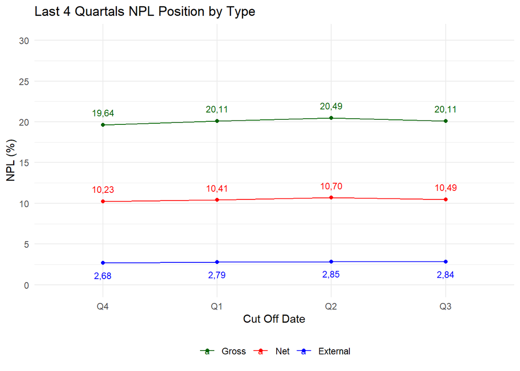

```r
# PLOT 1.8: Last 4 Quartals NPL Position by Type
plot1.8 <- ggplot(GNE_NPL_last_4_quartals, aes(x = reorder(quartal, month),
                    y = NPL,
                    color = NPL_type,
                    group = NPL_type,
                    text = label)) +

  geom_point() +
  geom_line() +
  geom_text(aes(y = ifelse(NPL_type == "External", NPL - 1.5, NPL + 1.5),
                label = label_number(big.mark = ".",
                                     decimal.mark = ",",
                                     accuracy = 0.01)
                (NPL)),
            size = 3) +
  scale_y_continuous(
    limits = c(0, max(GNE_NPL_last_4_quartals$NPL) + 10),
    breaks = seq(0,100,5)
  ) +
  scale_color_manual(values = c(
    "Gross" = "darkgreen",
    "Net" = "red",
    "External" = "blue"),
    name = NULL) +
  labs(title = "Last 4 Quartals NPL Position by Type",
       x = "Cut Off Date",
       y = "NPL (%)",
       color = "NPL Type") +
  theme_minimal() +
  theme(legend.position = "bottom")

plot1.8
```

```r
# This is for interactive plot
# ggplotly(plot1.8, tooltip = "text") %>%
#   layout(legend = list(
#     orientation = "h",
#     y = -0.3
#   ))
```

The chart presents the **NPL** trend over the **last four quartals**, comparing **Gross**, **Net**, and **External** NPL ratios.

- **Gross NPL** shows a gradual increase from **19.64% (Q4)** to **20.49% (Q2)** before slightly easing to **20.11% (Q3)**, indicating **a generally stable performance** across the period.
- **Net NPL** rose from **10.23%** in **Q4** to **10.70%** in **Q2**, followed by a marginal decline to **10.49%** in **Q3**, reflecting **minor fluctuation but consistent control of credit quality**.
- **External NPL** remained **very stable**, moving slightly from **2.68%** to **2.85%**, then closing at **2.84%**, suggesting **strong management of external exposures**.

Overall, **all three NPL categories** maintained **steady positions**, with only slight movements across the quartals—implying **consistent portfolio quality and controlled risk levels**.

# TAB 2 (DPD BUCKET OVERVIEW)

## Section 1 (DPD Bucket by Amount)

Now, I’m going to create **bar plots** to visualize the **total outstanding amount** across islands for each **DPD bucket**. These visualizations provide a clearer overview of outstanding loan distribution within the `Gross`, `Net`, and `External` datasets, making the comparison across islands and bucket categories easier to interpret.

The main goals of these plots are to:

- Compare the **total outstanding amount** across `Gross`, `Net`, and `External` datasets.
- Identify which islands have the **highest** and **lowest outstanding amounts** within each DPD bucket.
- Analyze the **distribution of outstanding balances** across islands and bucket categories.
- Highlight the `DPD 90+` bucket to identify islands with higher levels of **overdue or unpaid loans**.

### PLOT 2.1: (bar plot)

“DPD Bucket by Amount (02. 1-30 DPD) ~ Total Outstanding vs Island”

```r
# Dataset: Gross, Net, and External
sqllab_gross_clean
```

```
#> # A tibble: 135,420 × 11
#>    cut_off_date island region area  branch bucket   noa outstanding_amount  date
#>    <date>       <fct>  <fct>  <fct> <fct>  <fct>  <int>              <dbl> <int>
#>  1 2025-11-01   Sumat… Aceh   Aceh… Aceh … 01. C…    53          91784130.     1
#>  2 2025-11-01   Sumat… Aceh   Aceh… Aceh … 02. 1…   185         254273192.     1
#>  3 2025-11-01   Sumat… Aceh   Aceh… Aceh … 03. 3…   173         431221028.     1
#>  4 2025-11-01   Sumat… Aceh   Aceh… Aceh … 04. 6…   271        1326525315.     1
#>  5 2025-11-01   Sumat… Aceh   Aceh… Aceh … 05. 9…   119         557134482.     1
#>  6 2025-11-01   Sumat… Aceh   Aceh… Aceh … 01. C…   176         836408397.     1
#>  7 2025-11-01   Sumat… Aceh   Aceh… Aceh … 02. 1…   443         850066868.     1
#>  8 2025-11-01   Sumat… Aceh   Aceh… Aceh … 03. 3…   369        1051253334.     1
#>  9 2025-11-01   Sumat… Aceh   Aceh… Aceh … 04. 6…   386         920064468.     1
#> 10 2025-11-01   Sumat… Aceh   Aceh… Aceh … 05. 9…   148         702017007.     1
#> # ℹ 135,410 more rows
#> # ℹ 2 more variables: month <dbl>, year <dbl>
```

```r
sqllab_net_clean
```

```
#> # A tibble: 135,420 × 11
#>    cut_off_date island region area  branch bucket   noa outstanding_amount  date
#>    <date>       <fct>  <fct>  <fct> <fct>  <fct>  <int>              <dbl> <int>
#>  1 2025-11-01   Sumat… Aceh   Aceh… Aceh … 01. C…    53          76934000.     1
#>  2 2025-11-01   Sumat… Aceh   Aceh… Aceh … 02. 1…   185         218410473.     1
#>  3 2025-11-01   Sumat… Aceh   Aceh… Aceh … 03. 3…   173         317760703.     1
#>  4 2025-11-01   Sumat… Aceh   Aceh… Aceh … 04. 6…   271         811554170.     1
#>  5 2025-11-01   Sumat… Aceh   Aceh… Aceh … 05. 9…   119         271330064.     1
#>  6 2025-11-01   Sumat… Aceh   Aceh… Aceh … 01. C…   176         581834603.     1
#>  7 2025-11-01   Sumat… Aceh   Aceh… Aceh … 02. 1…   443         748995851.     1
#>  8 2025-11-01   Sumat… Aceh   Aceh… Aceh … 03. 3…   369         877552083.     1
#>  9 2025-11-01   Sumat… Aceh   Aceh… Aceh … 04. 6…   386         558000043.     1
#> 10 2025-11-01   Sumat… Aceh   Aceh… Aceh … 05. 9…   148         335235117.     1
#> # ℹ 135,410 more rows
#> # ℹ 2 more variables: month <dbl>, year <dbl>
```

```r
sqllab_external_clean
```

```
#> # A tibble: 135,420 × 11
#>    cut_off_date island region area  branch bucket   noa outstanding_amount  date
#>    <date>       <fct>  <fct>  <fct> <fct>  <fct>  <int>              <dbl> <int>
#>  1 2025-11-01   Sumat… Aceh   Aceh… Aceh … 01. C…    53          64398309.     1
#>  2 2025-11-01   Sumat… Aceh   Aceh… Aceh … 02. 1…   185         206470008.     1
#>  3 2025-11-01   Sumat… Aceh   Aceh… Aceh … 03. 3…   173         231682208.     1
#>  4 2025-11-01   Sumat… Aceh   Aceh… Aceh … 04. 6…   271         648403168.     1
#>  5 2025-11-01   Sumat… Aceh   Aceh… Aceh … 05. 9…   119          50133476.     1
#>  6 2025-11-01   Sumat… Aceh   Aceh… Aceh … 01. C…   176         458579814.     1
#>  7 2025-11-01   Sumat… Aceh   Aceh… Aceh … 02. 1…   443         553795359.     1
#>  8 2025-11-01   Sumat… Aceh   Aceh… Aceh … 03. 3…   369         827679983.     1
#>  9 2025-11-01   Sumat… Aceh   Aceh… Aceh … 04. 6…   386         511141034.     1
#> 10 2025-11-01   Sumat… Aceh   Aceh… Aceh … 05. 9…   148          47998959.     1
#> # ℹ 135,410 more rows
#> # ℹ 2 more variables: month <dbl>, year <dbl>
```

Now, we’re going to derive the latest *outstanding amount* from the *gross dataset*, specifically for the *“02. 1–30 DPD”* bucket in each island.

```r
# Gross: Outstanding amount for "02. DPD 1-30" bucket
DPD_bucket_by_amount02_gross <- sqllab_gross_clean %>%
  filter(bucket == "02. 1-30 DPD",
         cut_off_date == "2025-11-01") %>%
  group_by(island) %>%
  summarise(outstanding_amount = sum(outstanding_amount)) %>%
  ungroup()

DPD_bucket_by_amount02_gross
```

```
#> # A tibble: 7 × 2
#>   island               outstanding_amount
#>   <fct>                             <dbl>
#> 1 Bali & Nusa Tenggara       32298330010.
#> 2 Jawa                       56154582913.
#> 3 Kalimantan                 50642853158.
#> 4 Maluku                     20264763024.
#> 5 Papua                      45435473666.
#> 6 Sulawesi                   55370078762.
#> 7 Sumatera                   92983842942.
```

We’re also going to derive the latest *outstanding amount* from the *net and external dataset*, specifically for the *“02. 1–30 DPD”* bucket in each island.

```r
# Net: Outstanding amount for "02. DPD 1-30" bucket
DPD_bucket_by_amount02_net <- sqllab_net_clean %>%
  filter(bucket == "02. 1-30 DPD",
         cut_off_date == "2025-11-01") %>%
  group_by(island) %>%
  summarise(outstanding_amount = sum(outstanding_amount)) %>%
  ungroup()

DPD_bucket_by_amount02_net
```

```
#> # A tibble: 7 × 2
#>   island               outstanding_amount
#>   <fct>                             <dbl>
#> 1 Bali & Nusa Tenggara       25007691756.
#> 2 Jawa                       42492736866.
#> 3 Kalimantan                 38305353458.
#> 4 Maluku                     15274787368.
#> 5 Papua                      33640831542.
#> 6 Sulawesi                   41509274202.
#> 7 Sumatera                   71125598557.
```

```r
# External: Outstanding amount for "02. DPD 1-30" bucket
DPD_bucket_by_amount02_external <- sqllab_external_clean %>%
  filter(bucket == "02. 1-30 DPD",
         cut_off_date == "2025-11-01") %>%
  group_by(island) %>%
  summarise(outstanding_amount = sum(outstanding_amount)) %>%
  ungroup()

DPD_bucket_by_amount02_external
```

```
#> # A tibble: 7 × 2
#>   island               outstanding_amount
#>   <fct>                             <dbl>
#> 1 Bali & Nusa Tenggara       20173885862.
#> 2 Jawa                       34751668885.
#> 3 Kalimantan                 32258736162.
#> 4 Maluku                     12843830678.
#> 5 Papua                      27956284452.
#> 6 Sulawesi                   33892358211.
#> 7 Sumatera                   58453376030.
```

After obtaining the latest *Gross, Net, and External outstanding amounts*, specifically for the *“02. 1–30 DPD”* bucket in each island, we’re going to *merge* and *pivot* them into one dataset for easier visualization.

```r
# Merging Gross, Net, and External "02. DPD 1-30" bucket outstanding amounts into one dataset
DPD_bucket_by_amount02 <- DPD_bucket_by_amount02_gross %>%
  inner_join(DPD_bucket_by_amount02_net, by = "island") %>%
  inner_join(DPD_bucket_by_amount02_external, by = "island") %>%
  rename(
    Gross = outstanding_amount.x,
    Net = outstanding_amount.y,
    External = outstanding_amount
  )

DPD_bucket_by_amount02
```

```
#> # A tibble: 7 × 4
#>   island                      Gross          Net     External
#>   <fct>                       <dbl>        <dbl>        <dbl>
#> 1 Bali & Nusa Tenggara 32298330010. 25007691756. 20173885862.
#> 2 Jawa                 56154582913. 42492736866. 34751668885.
#> 3 Kalimantan           50642853158. 38305353458. 32258736162.
#> 4 Maluku               20264763024. 15274787368. 12843830678.
#> 5 Papua                45435473666. 33640831542. 27956284452.
#> 6 Sulawesi             55370078762. 41509274202. 33892358211.
#> 7 Sumatera             92983842942. 71125598557. 58453376030.
```

```r
# Pivot and adding NPL type column
DPD_bucket_by_amount02 <- DPD_bucket_by_amount02 %>%
  pivot_longer(
    cols = c(Gross, Net, External),
    names_to = "Type",
    values_to = "Total_OS"
  ) %>%
  mutate(Type = factor(Type, levels = c("Gross", "Net", "External")))

DPD_bucket_by_amount02
```

```
#> # A tibble: 21 × 3
#>    island               Type         Total_OS
#>    <fct>                <fct>           <dbl>
#>  1 Bali & Nusa Tenggara Gross    32298330010.
#>  2 Bali & Nusa Tenggara Net      25007691756.
#>  3 Bali & Nusa Tenggara External 20173885862.
#>  4 Jawa                 Gross    56154582913.
#>  5 Jawa                 Net      42492736866.
#>  6 Jawa                 External 34751668885.
#>  7 Kalimantan           Gross    50642853158.
#>  8 Kalimantan           Net      38305353458.
#>  9 Kalimantan           External 32258736162.
#> 10 Maluku               Gross    20264763024.
#> # ℹ 11 more rows
```

```r
# tooltip
DPD_bucket_by_amount02 <- DPD_bucket_by_amount02 %>%
  mutate(
    label = glue(
      "Total Oustanding:IDR {number(Total_OS, big.mark = '.', decimal.mark = ',', accuracy = 1)}"
    )
  )

DPD_bucket_by_amount02
```

```
#> # A tibble: 21 × 4
#>    island               Type         Total_OS label
#>    <fct>                <fct>           <dbl> <glue>
#>  1 Bali & Nusa Tenggara Gross    32298330010. Total Oustanding:IDR 32.298.330.0…
#>  2 Bali & Nusa Tenggara Net      25007691756. Total Oustanding:IDR 25.007.691.7…
#>  3 Bali & Nusa Tenggara External 20173885862. Total Oustanding:IDR 20.173.885.8…
#>  4 Jawa                 Gross    56154582913. Total Oustanding:IDR 56.154.582.9…
#>  5 Jawa                 Net      42492736866. Total Oustanding:IDR 42.492.736.8…
#>  6 Jawa                 External 34751668885. Total Oustanding:IDR 34.751.668.8…
#>  7 Kalimantan           Gross    50642853158. Total Oustanding:IDR 50.642.853.1…
#>  8 Kalimantan           Net      38305353458. Total Oustanding:IDR 38.305.353.4…
#>  9 Kalimantan           External 32258736162. Total Oustanding:IDR 32.258.736.1…
#> 10 Maluku               Gross    20264763024. Total Oustanding:IDR 20.264.763.0…
#> # ℹ 11 more rows
```

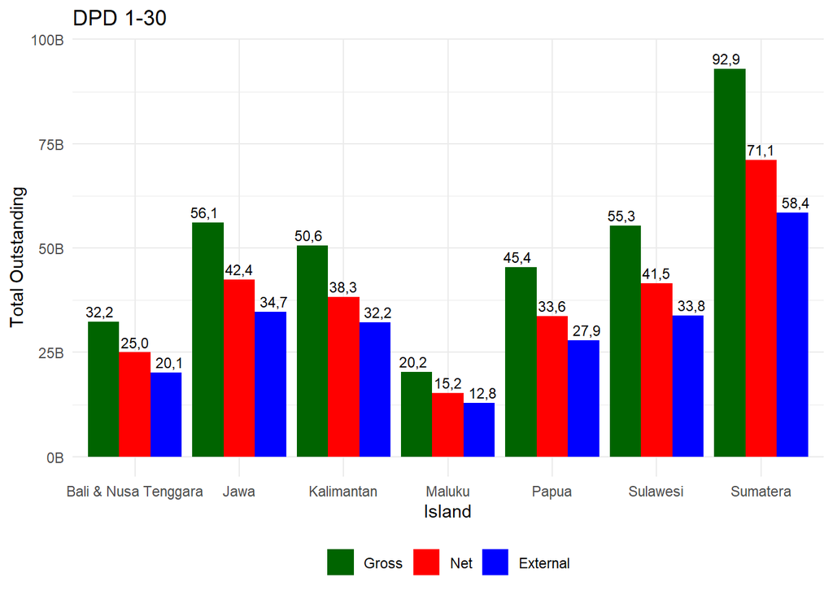

```r
# PLOT 2.1: DPD Bucket by Amount (02. 1-30 DPD)
plot2.1 <- ggplot(DPD_bucket_by_amount02, aes(x = island,
                    y = Total_OS,
                    text = label)) +

  geom_col(position = position_dodge(width = 0.9),
           aes(fill = Type)) +
  geom_text(aes(y = Total_OS + 2.5e9,
                label = format(floor(Total_OS/1e8)/10,
                                     big.mark = ".",
                                     decimal.mark = ","),
                group = Type),
            position = position_dodge(width = 1),
            size = 3) +
  scale_y_continuous(labels = label_number(scale = 1e-9,
                                           suffix = "B",
                                           accuracy = 1)) +
  scale_fill_manual(values = c("darkgreen", "red","blue"),
                    name = NULL) +
  labs(title = "DPD 1-30",
       x = "Island",
       y = "Total Outstanding") +
  theme_minimal() +
  theme(legend.position = "bottom")

plot2.1
```

```r
# This is for interactive plot
# ggplotly(plot2.1, tooltip = "text") %>%
#   layout(title = list(text = paste0(
#       "DPD 1-30",
#       "<br><sup>in billion Rupiah</sup>")),
#       legend = list(orientation = "h",
#                     y = -0.3))
```

The chart shows the **total outstanding DPD 1–30 (in billion Rupiah)** across different islands, comparing **Gross**, **Net**, and **External** figures.

- **Sumatera** recorded the **highest exposure**, with **Gross 92.9B**, **Net 71.1B**, and **External 58.4B**, indicating the largest loan volume in early delinquency.
- **Jawa** and **Sulawesi** followed, showing **Gross 56.1B** and **55.3B** respectively, suggesting significant portfolio size but still well-managed within the early DPD category.
- **Kalimantan** and **Papua** maintained moderate levels, with **Gross around 50.6B** and **45.4B**, while **Bali & Nusa Tenggara** and **Maluku** reported relatively **lower exposures**.

Overall, the **Gross DPD 1–30 remains consistently higher** than Net and External across all islands, reflecting **expected write-off and collection adjustments** in later stages.

### PLOT 2.2: (bar plot)

“DPD Bucket by Amount (03. 31-60 DPD) ~ Total Outstanding vs Island”

```r
# Dataset: Gross, Net, and External
sqllab_gross_clean
```

```
#> # A tibble: 135,420 × 11
#>    cut_off_date island region area  branch bucket   noa outstanding_amount  date
#>    <date>       <fct>  <fct>  <fct> <fct>  <fct>  <int>              <dbl> <int>
#>  1 2025-11-01   Sumat… Aceh   Aceh… Aceh … 01. C…    53          91784130.     1
#>  2 2025-11-01   Sumat… Aceh   Aceh… Aceh … 02. 1…   185         254273192.     1
#>  3 2025-11-01   Sumat… Aceh   Aceh… Aceh … 03. 3…   173         431221028.     1
#>  4 2025-11-01   Sumat… Aceh   Aceh… Aceh … 04. 6…   271        1326525315.     1
#>  5 2025-11-01   Sumat… Aceh   Aceh… Aceh … 05. 9…   119         557134482.     1
#>  6 2025-11-01   Sumat… Aceh   Aceh… Aceh … 01. C…   176         836408397.     1
#>  7 2025-11-01   Sumat… Aceh   Aceh… Aceh … 02. 1…   443         850066868.     1
#>  8 2025-11-01   Sumat… Aceh   Aceh… Aceh … 03. 3…   369        1051253334.     1
#>  9 2025-11-01   Sumat… Aceh   Aceh… Aceh … 04. 6…   386         920064468.     1
#> 10 2025-11-01   Sumat… Aceh   Aceh… Aceh … 05. 9…   148         702017007.     1
#> # ℹ 135,410 more rows
#> # ℹ 2 more variables: month <dbl>, year <dbl>
```

```r
sqllab_net_clean
```

```
#> # A tibble: 135,420 × 11
#>    cut_off_date island region area  branch bucket   noa outstanding_amount  date
#>    <date>       <fct>  <fct>  <fct> <fct>  <fct>  <int>              <dbl> <int>
#>  1 2025-11-01   Sumat… Aceh   Aceh… Aceh … 01. C…    53          76934000.     1
#>  2 2025-11-01   Sumat… Aceh   Aceh… Aceh … 02. 1…   185         218410473.     1
#>  3 2025-11-01   Sumat… Aceh   Aceh… Aceh … 03. 3…   173         317760703.     1
#>  4 2025-11-01   Sumat… Aceh   Aceh… Aceh … 04. 6…   271         811554170.     1
#>  5 2025-11-01   Sumat… Aceh   Aceh… Aceh … 05. 9…   119         271330064.     1
#>  6 2025-11-01   Sumat… Aceh   Aceh… Aceh … 01. C…   176         581834603.     1
#>  7 2025-11-01   Sumat… Aceh   Aceh… Aceh … 02. 1…   443         748995851.     1
#>  8 2025-11-01   Sumat… Aceh   Aceh… Aceh … 03. 3…   369         877552083.     1
#>  9 2025-11-01   Sumat… Aceh   Aceh… Aceh … 04. 6…   386         558000043.     1
#> 10 2025-11-01   Sumat… Aceh   Aceh… Aceh … 05. 9…   148         335235117.     1
#> # ℹ 135,410 more rows
#> # ℹ 2 more variables: month <dbl>, year <dbl>
```

```r
sqllab_external_clean
```

```
#> # A tibble: 135,420 × 11
#>    cut_off_date island region area  branch bucket   noa outstanding_amount  date
#>    <date>       <fct>  <fct>  <fct> <fct>  <fct>  <int>              <dbl> <int>
#>  1 2025-11-01   Sumat… Aceh   Aceh… Aceh … 01. C…    53          64398309.     1
#>  2 2025-11-01   Sumat… Aceh   Aceh… Aceh … 02. 1…   185         206470008.     1
#>  3 2025-11-01   Sumat… Aceh   Aceh… Aceh … 03. 3…   173         231682208.     1
#>  4 2025-11-01   Sumat… Aceh   Aceh… Aceh … 04. 6…   271         648403168.     1
#>  5 2025-11-01   Sumat… Aceh   Aceh… Aceh … 05. 9…   119          50133476.     1
#>  6 2025-11-01   Sumat… Aceh   Aceh… Aceh … 01. C…   176         458579814.     1
#>  7 2025-11-01   Sumat… Aceh   Aceh… Aceh … 02. 1…   443         553795359.     1
#>  8 2025-11-01   Sumat… Aceh   Aceh… Aceh … 03. 3…   369         827679983.     1
#>  9 2025-11-01   Sumat… Aceh   Aceh… Aceh … 04. 6…   386         511141034.     1
#> 10 2025-11-01   Sumat… Aceh   Aceh… Aceh … 05. 9…   148          47998959.     1
#> # ℹ 135,410 more rows
#> # ℹ 2 more variables: month <dbl>, year <dbl>
```

Now, we’re going to derive the latest *outstanding amount* from the *gross dataset*, specifically for the *“03. 31–60 DPD”* bucket in each island.

```r
# Gross: Outstanding amount for "03. DPD 31-60" bucket
DPD_bucket_by_amount03_gross <- sqllab_gross_clean %>%
  filter(bucket == "03. 31-60 DPD",
         cut_off_date == "2025-11-01") %>%
  group_by(island) %>%
  summarise(outstanding_amount = sum(outstanding_amount)) %>%
  ungroup()

DPD_bucket_by_amount03_gross
```

```
#> # A tibble: 7 × 2
#>   island               outstanding_amount
#>   <fct>                             <dbl>
#> 1 Bali & Nusa Tenggara       23901801836.
#> 2 Jawa                       53514956086.
#> 3 Kalimantan                 52384108110.
#> 4 Maluku                     16380364361.
#> 5 Papua                      42443492863.
#> 6 Sulawesi                   60825038183.
#> 7 Sumatera                   93988750331.
```

We’re also going to derive the latest *outstanding amount* from the *net and external dataset*, specifically for the *“03. 31–60 DPD”* bucket in each island.

```r
# Net: Outstanding amount for "03. DPD 31-60" bucket
DPD_bucket_by_amount03_net <- sqllab_net_clean %>%
  filter(bucket == "03. 31-60 DPD",
         cut_off_date == "2025-11-01") %>%
  group_by(island) %>%
  summarise(outstanding_amount = sum(outstanding_amount)) %>%
  ungroup()

DPD_bucket_by_amount03_net
```

```
#> # A tibble: 7 × 2
#>   island               outstanding_amount
#>   <fct>                             <dbl>
#> 1 Bali & Nusa Tenggara       17753080908.
#> 2 Jawa                       41069456228.
#> 3 Kalimantan                 39070205962.
#> 4 Maluku                     11955745329.
#> 5 Papua                      32300294975.
#> 6 Sulawesi                   45829473488.
#> 7 Sumatera                   69826052554.
```

```r
# External: Outstanding amount for "03. DPD 31-60" bucket
DPD_bucket_by_amount03_external <- sqllab_external_clean %>%
  filter(bucket == "03. 31-60 DPD",
         cut_off_date == "2025-11-01") %>%
  group_by(island) %>%
  summarise(outstanding_amount = sum(outstanding_amount)) %>%
  ungroup()

DPD_bucket_by_amount03_external
```

```
#> # A tibble: 7 × 2
#>   island               outstanding_amount
#>   <fct>                             <dbl>
#> 1 Bali & Nusa Tenggara       14261813358.
#> 2 Jawa                       34781958403.
#> 3 Kalimantan                 31718571037.
#> 4 Maluku                     10212794139.
#> 5 Papua                      26677463004.
#> 6 Sulawesi                   37493818108.
#> 7 Sumatera                   57419784697.
```

Like the previous example, we’re now going to *merge* and *pivot* the data into a single dataset for easier visualization.

```r
# Merging Gross, Net, and External "03. DPD 31-60" bucket outstanding amounts into one dataset
DPD_bucket_by_amount03 <- DPD_bucket_by_amount03_gross %>%
  inner_join(DPD_bucket_by_amount03_net, by = "island") %>%
  inner_join(DPD_bucket_by_amount03_external, by = "island") %>%
  rename(
    Gross = outstanding_amount.x,
    Net = outstanding_amount.y,
    External = outstanding_amount
  )

DPD_bucket_by_amount03
```

```
#> # A tibble: 7 × 4
#>   island                      Gross          Net     External
#>   <fct>                       <dbl>        <dbl>        <dbl>
#> 1 Bali & Nusa Tenggara 23901801836. 17753080908. 14261813358.
#> 2 Jawa                 53514956086. 41069456228. 34781958403.
#> 3 Kalimantan           52384108110. 39070205962. 31718571037.
#> 4 Maluku               16380364361. 11955745329. 10212794139.
#> 5 Papua                42443492863. 32300294975. 26677463004.
#> 6 Sulawesi             60825038183. 45829473488. 37493818108.
#> 7 Sumatera             93988750331. 69826052554. 57419784697.
```

```r
# Pivot and adding NPL type column
DPD_bucket_by_amount03 <- DPD_bucket_by_amount03 %>%
  pivot_longer(
    cols = c(Gross, Net, External),
    names_to = "Type",
    values_to = "Total_OS"
  ) %>%
  mutate(Type = factor(Type, levels = c("Gross", "Net", "External")))

DPD_bucket_by_amount03
```

```
#> # A tibble: 21 × 3
#>    island               Type         Total_OS
#>    <fct>                <fct>           <dbl>
#>  1 Bali & Nusa Tenggara Gross    23901801836.
#>  2 Bali & Nusa Tenggara Net      17753080908.
#>  3 Bali & Nusa Tenggara External 14261813358.
#>  4 Jawa                 Gross    53514956086.
#>  5 Jawa                 Net      41069456228.
#>  6 Jawa                 External 34781958403.
#>  7 Kalimantan           Gross    52384108110.
#>  8 Kalimantan           Net      39070205962.
#>  9 Kalimantan           External 31718571037.
#> 10 Maluku               Gross    16380364361.
#> # ℹ 11 more rows
```

```r
# tooltip
DPD_bucket_by_amount03 <- DPD_bucket_by_amount03 %>%
  mutate(
    label = glue(
      "Total Oustanding:IDR {number(Total_OS, big.mark = '.', decimal.mark = ',', accuracy = 1)}"
    )
  )

DPD_bucket_by_amount03
```

```
#> # A tibble: 21 × 4
#>    island               Type         Total_OS label
#>    <fct>                <fct>           <dbl> <glue>
#>  1 Bali & Nusa Tenggara Gross    23901801836. Total Oustanding:IDR 23.901.801.8…
#>  2 Bali & Nusa Tenggara Net      17753080908. Total Oustanding:IDR 17.753.080.9…
#>  3 Bali & Nusa Tenggara External 14261813358. Total Oustanding:IDR 14.261.813.3…
#>  4 Jawa                 Gross    53514956086. Total Oustanding:IDR 53.514.956.0…
#>  5 Jawa                 Net      41069456228. Total Oustanding:IDR 41.069.456.2…
#>  6 Jawa                 External 34781958403. Total Oustanding:IDR 34.781.958.4…
#>  7 Kalimantan           Gross    52384108110. Total Oustanding:IDR 52.384.108.1…
#>  8 Kalimantan           Net      39070205962. Total Oustanding:IDR 39.070.205.9…
#>  9 Kalimantan           External 31718571037. Total Oustanding:IDR 31.718.571.0…
#> 10 Maluku               Gross    16380364361. Total Oustanding:IDR 16.380.364.3…
#> # ℹ 11 more rows
```

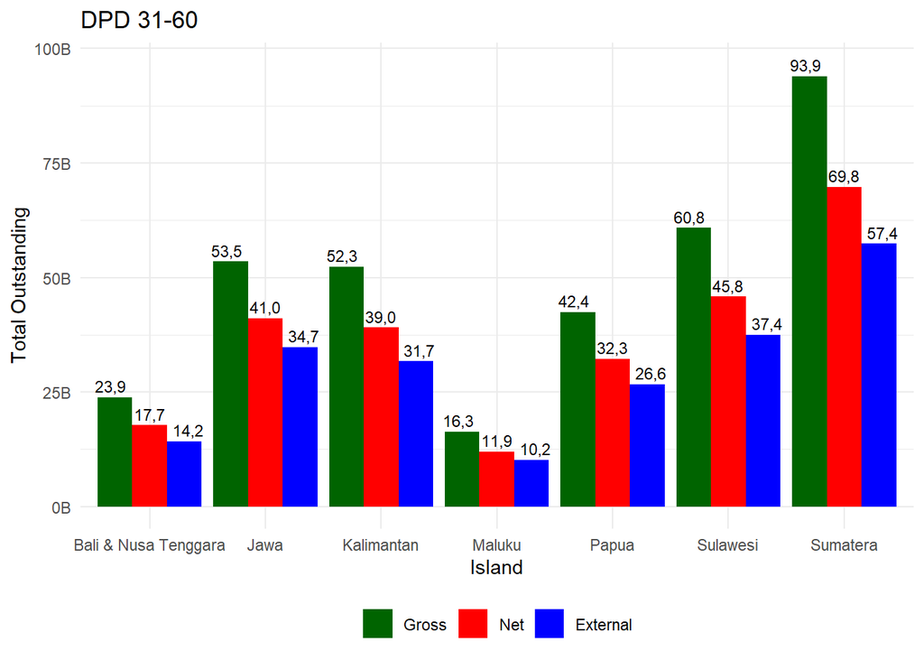

```r
# PLOT 2.2: DPD Bucket by Amount (03. 31-60 DPD)
plot2.2 <- ggplot(DPD_bucket_by_amount03, aes(x = island,
                    y = Total_OS,
                    text = label)) +

  geom_col(position = position_dodge(width = 0.9),
           aes(fill = Type)) +
  geom_text(aes(y = Total_OS + 2.5e9,
                label = format(floor(Total_OS/1e8)/10,
                                     big.mark = ".",
                                     decimal.mark = ","),
                group = Type),
            position = position_dodge(width = 1),
            size = 3) +
  scale_y_continuous(labels = label_number(scale = 1e-9,
                                           suffix = "B",
                                           accuracy = 1)) +
   scale_fill_manual(values = c("darkgreen", "red","blue"),
                    name = NULL) +
  labs(title = "DPD 31-60",
       x = "Island",
       y = "Total Outstanding") +
  theme_minimal() +
  theme(legend.position = "bottom")

plot2.2
```

```r
# This is for interactive plot
# ggplotly(plot2.2, tooltip = "text") %>%
#   layout(title = list(text = paste0(
#       "DPD 31-60",
#       "<br><sup>in billion Rupiah</sup>")),
#       legend = list(orientation = "h",
#                     y = -0.3))
```

The chart shows **Total Outstanding (in billion Rupiah)** for **DPD 31–60** across different **islands** in Indonesia, categorized into **Gross**, **Net**, and **External** values.

- **Sumatera** has the highest outstanding amounts across all categories, reaching **93.9B Gross**, **69.8B Net**, and **57.4B External**.
- **Jawa** and **Sulawesi** follow with relatively high totals, while **Maluku** records the lowest with **16.3B Gross**.
- Across all islands, **Gross values** consistently exceed **Net** and **External**, indicating deductions or adjustments between categories.
- Overall, the data suggests a concentration of higher DPD 31–60 exposures in **Sumatera**, **Jawa**, and **Sulawesi** regions.

### PLOT 2.3: (bar plot)

“DPD Bucket by Amount (04. 61-90 DPD) ~ Total Outstanding vs Island”

```r
# Dataset: Gross, Net, and External
sqllab_gross_clean
```

```
#> # A tibble: 135,420 × 11
#>    cut_off_date island region area  branch bucket   noa outstanding_amount  date
#>    <date>       <fct>  <fct>  <fct> <fct>  <fct>  <int>              <dbl> <int>
#>  1 2025-11-01   Sumat… Aceh   Aceh… Aceh … 01. C…    53          91784130.     1
#>  2 2025-11-01   Sumat… Aceh   Aceh… Aceh … 02. 1…   185         254273192.     1
#>  3 2025-11-01   Sumat… Aceh   Aceh… Aceh … 03. 3…   173         431221028.     1
#>  4 2025-11-01   Sumat… Aceh   Aceh… Aceh … 04. 6…   271        1326525315.     1
#>  5 2025-11-01   Sumat… Aceh   Aceh… Aceh … 05. 9…   119         557134482.     1
#>  6 2025-11-01   Sumat… Aceh   Aceh… Aceh … 01. C…   176         836408397.     1
#>  7 2025-11-01   Sumat… Aceh   Aceh… Aceh … 02. 1…   443         850066868.     1
#>  8 2025-11-01   Sumat… Aceh   Aceh… Aceh … 03. 3…   369        1051253334.     1
#>  9 2025-11-01   Sumat… Aceh   Aceh… Aceh … 04. 6…   386         920064468.     1
#> 10 2025-11-01   Sumat… Aceh   Aceh… Aceh … 05. 9…   148         702017007.     1
#> # ℹ 135,410 more rows
#> # ℹ 2 more variables: month <dbl>, year <dbl>
```

```r
sqllab_net_clean
```

```
#> # A tibble: 135,420 × 11
#>    cut_off_date island region area  branch bucket   noa outstanding_amount  date
#>    <date>       <fct>  <fct>  <fct> <fct>  <fct>  <int>              <dbl> <int>
#>  1 2025-11-01   Sumat… Aceh   Aceh… Aceh … 01. C…    53          76934000.     1
#>  2 2025-11-01   Sumat… Aceh   Aceh… Aceh … 02. 1…   185         218410473.     1
#>  3 2025-11-01   Sumat… Aceh   Aceh… Aceh … 03. 3…   173         317760703.     1
#>  4 2025-11-01   Sumat… Aceh   Aceh… Aceh … 04. 6…   271         811554170.     1
#>  5 2025-11-01   Sumat… Aceh   Aceh… Aceh … 05. 9…   119         271330064.     1
#>  6 2025-11-01   Sumat… Aceh   Aceh… Aceh … 01. C…   176         581834603.     1
#>  7 2025-11-01   Sumat… Aceh   Aceh… Aceh … 02. 1…   443         748995851.     1
#>  8 2025-11-01   Sumat… Aceh   Aceh… Aceh … 03. 3…   369         877552083.     1
#>  9 2025-11-01   Sumat… Aceh   Aceh… Aceh … 04. 6…   386         558000043.     1
#> 10 2025-11-01   Sumat… Aceh   Aceh… Aceh … 05. 9…   148         335235117.     1
#> # ℹ 135,410 more rows
#> # ℹ 2 more variables: month <dbl>, year <dbl>
```

```r
sqllab_external_clean
```

```
#> # A tibble: 135,420 × 11
#>    cut_off_date island region area  branch bucket   noa outstanding_amount  date
#>    <date>       <fct>  <fct>  <fct> <fct>  <fct>  <int>              <dbl> <int>
#>  1 2025-11-01   Sumat… Aceh   Aceh… Aceh … 01. C…    53          64398309.     1
#>  2 2025-11-01   Sumat… Aceh   Aceh… Aceh … 02. 1…   185         206470008.     1
#>  3 2025-11-01   Sumat… Aceh   Aceh… Aceh … 03. 3…   173         231682208.     1
#>  4 2025-11-01   Sumat… Aceh   Aceh… Aceh … 04. 6…   271         648403168.     1
#>  5 2025-11-01   Sumat… Aceh   Aceh… Aceh … 05. 9…   119          50133476.     1
#>  6 2025-11-01   Sumat… Aceh   Aceh… Aceh … 01. C…   176         458579814.     1
#>  7 2025-11-01   Sumat… Aceh   Aceh… Aceh … 02. 1…   443         553795359.     1
#>  8 2025-11-01   Sumat… Aceh   Aceh… Aceh … 03. 3…   369         827679983.     1
#>  9 2025-11-01   Sumat… Aceh   Aceh… Aceh … 04. 6…   386         511141034.     1
#> 10 2025-11-01   Sumat… Aceh   Aceh… Aceh … 05. 9…   148          47998959.     1
#> # ℹ 135,410 more rows
#> # ℹ 2 more variables: month <dbl>, year <dbl>
```

Next, we’re going to derive the latest *outstanding amount* from the *gross dataset*, specifically for the *“04. 61–90 DPD”* bucket in each island.

```r
# Gross: Outstanding amount for "04. DPD 61-90" bucket
DPD_bucket_by_amount04_gross <- sqllab_gross_clean %>%
  filter(bucket == "04. 61-90 DPD",
         cut_off_date == "2025-11-01") %>%
  group_by(island) %>%
  summarise(outstanding_amount = sum(outstanding_amount)) %>%
  ungroup()

DPD_bucket_by_amount04_gross
```

```
#> # A tibble: 7 × 2
#>   island               outstanding_amount
#>   <fct>                             <dbl>
#> 1 Bali & Nusa Tenggara       31530555874.
#> 2 Jawa                       70930299401.
#> 3 Kalimantan                 51489428694.
#> 4 Maluku                     16949251465.
#> 5 Papua                      49963254557.
#> 6 Sulawesi                   59909238818.
#> 7 Sumatera                  100635982109.
```

We’re also going to derive the latest *outstanding amount* from the *net and external dataset*, specifically for the *“04. 61–90 DPD”* bucket in each island.

```r
# Net: Outstanding amount for "04. DPD 61-90" bucket
DPD_bucket_by_amount04_net <- sqllab_net_clean %>%
  filter(bucket == "04. 61-90 DPD",
         cut_off_date == "2025-11-01") %>%
  group_by(island) %>%
  summarise(outstanding_amount = sum(outstanding_amount)) %>%
  ungroup()

DPD_bucket_by_amount04_net
```

```
#> # A tibble: 7 × 2
#>   island               outstanding_amount
#>   <fct>                             <dbl>
#> 1 Bali & Nusa Tenggara       23124220798.
#> 2 Jawa                       53885664072.
#> 3 Kalimantan                 39362628288.
#> 4 Maluku                     12559238651.
#> 5 Papua                      37214620587.
#> 6 Sulawesi                   44763869642.
#> 7 Sumatera                   76277451316.
```

```r
# External: Outstanding amount for "04. DPD 61-90" bucket
DPD_bucket_by_amount04_external <- sqllab_external_clean %>%
  filter(bucket == "04. 61-90 DPD",
         cut_off_date == "2025-11-01") %>%
  group_by(island) %>%
  summarise(outstanding_amount = sum(outstanding_amount)) %>%
  ungroup()

DPD_bucket_by_amount04_external
```

```
#> # A tibble: 7 × 2
#>   island               outstanding_amount
#>   <fct>                             <dbl>
#> 1 Bali & Nusa Tenggara       19310291179.
#> 2 Jawa                       44580693589.
#> 3 Kalimantan                 31829536623.
#> 4 Maluku                     10756744039.
#> 5 Papua                      31029710088.
#> 6 Sulawesi                   37431081119.
#> 7 Sumatera                   62031797749.
```

After obtaining the latest *Gross, Net, and External outstanding amounts*, specifically for the *“04. 61–90 DPD”* bucket in each island, we’re going to *merge* and *pivot* them into one dataset for easier visualization.

```r
# Merging Gross, Net, and External "04. DPD 61-90" bucket outstanding amounts into one dataset
DPD_bucket_by_amount04 <- DPD_bucket_by_amount04_gross %>%
  inner_join(DPD_bucket_by_amount04_net, by = "island") %>%
  inner_join(DPD_bucket_by_amount04_external, by = "island") %>%
  rename(
    Gross = outstanding_amount.x,
    Net = outstanding_amount.y,
    External = outstanding_amount
  )

DPD_bucket_by_amount04
```

```
#> # A tibble: 7 × 4
#>   island                       Gross          Net     External
#>   <fct>                        <dbl>        <dbl>        <dbl>
#> 1 Bali & Nusa Tenggara  31530555874. 23124220798. 19310291179.
#> 2 Jawa                  70930299401. 53885664072. 44580693589.
#> 3 Kalimantan            51489428694. 39362628288. 31829536623.
#> 4 Maluku                16949251465. 12559238651. 10756744039.
#> 5 Papua                 49963254557. 37214620587. 31029710088.
#> 6 Sulawesi              59909238818. 44763869642. 37431081119.
#> 7 Sumatera             100635982109. 76277451316. 62031797749.
```

```r
# Pivot and adding NPL type column
DPD_bucket_by_amount04 <- DPD_bucket_by_amount04 %>%
  pivot_longer(
    cols = c(Gross, Net, External),
    names_to = "Type",
    values_to = "Total_OS"
  ) %>%
  mutate(Type = factor(Type, levels = c("Gross", "Net", "External")))

DPD_bucket_by_amount04
```

```
#> # A tibble: 21 × 3
#>    island               Type         Total_OS
#>    <fct>                <fct>           <dbl>
#>  1 Bali & Nusa Tenggara Gross    31530555874.
#>  2 Bali & Nusa Tenggara Net      23124220798.
#>  3 Bali & Nusa Tenggara External 19310291179.
#>  4 Jawa                 Gross    70930299401.
#>  5 Jawa                 Net      53885664072.
#>  6 Jawa                 External 44580693589.
#>  7 Kalimantan           Gross    51489428694.
#>  8 Kalimantan           Net      39362628288.
#>  9 Kalimantan           External 31829536623.
#> 10 Maluku               Gross    16949251465.
#> # ℹ 11 more rows
```

```r
# tooltip
DPD_bucket_by_amount04 <- DPD_bucket_by_amount04 %>%
  mutate(
    label = glue(
      "Total Oustanding:IDR {number(Total_OS, big.mark = '.', decimal.mark = ',', accuracy = 1)}"
    )
  )

DPD_bucket_by_amount04
```

```
#> # A tibble: 21 × 4
#>    island               Type         Total_OS label
#>    <fct>                <fct>           <dbl> <glue>
#>  1 Bali & Nusa Tenggara Gross    31530555874. Total Oustanding:IDR 31.530.555.8…
#>  2 Bali & Nusa Tenggara Net      23124220798. Total Oustanding:IDR 23.124.220.7…
#>  3 Bali & Nusa Tenggara External 19310291179. Total Oustanding:IDR 19.310.291.1…
#>  4 Jawa                 Gross    70930299401. Total Oustanding:IDR 70.930.299.4…
#>  5 Jawa                 Net      53885664072. Total Oustanding:IDR 53.885.664.0…
#>  6 Jawa                 External 44580693589. Total Oustanding:IDR 44.580.693.5…
#>  7 Kalimantan           Gross    51489428694. Total Oustanding:IDR 51.489.428.6…
#>  8 Kalimantan           Net      39362628288. Total Oustanding:IDR 39.362.628.2…
#>  9 Kalimantan           External 31829536623. Total Oustanding:IDR 31.829.536.6…
#> 10 Maluku               Gross    16949251465. Total Oustanding:IDR 16.949.251.4…
#> # ℹ 11 more rows
```

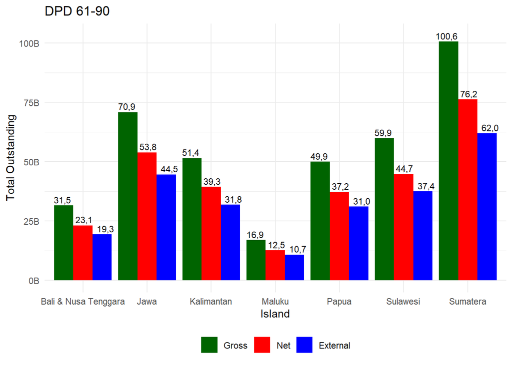

```r
# PLOT 2.3: DPD Bucket by Amount (04. 61-90 DPD)
plot2.3 <- ggplot(DPD_bucket_by_amount04, aes(x = island,
                    y = Total_OS,
                    text = label)) +

  geom_col(position = position_dodge(width = 0.9),
           aes(fill = Type)) +
  geom_text(aes(y = Total_OS + 2.5e9,
                label = format(floor(Total_OS/1e8)/10,
                                     big.mark = ".",
                                     decimal.mark = ","),
                group = Type),
            position = position_dodge(width = 1),
            size = 3) +
  scale_y_continuous(labels = label_number(scale = 1e-9,
                                           suffix = "B",
                                           accuracy = 1)) +
   scale_fill_manual(values = c("darkgreen", "red","blue"),
                    name = NULL) +
  labs(title = "DPD 61-90",
       x = "Island",
       y = "Total Outstanding") +
  theme_minimal() +
  theme(legend.position = "bottom")

plot2.3
```

```r
# This is for interactive plot
# ggplotly(plot2.3, tooltip = "text") %>%
#   layout(title = list(text = paste0(
#       "DPD 61-90",
#       "<br><sup>in billion Rupiah</sup>")),
#       legend = list(orientation = "h",
#                     y = -0.3))
```

The chart illustrates **Total Outstanding (in billion Rupiah)** for **DPD 61–90** across various **islands** in Indonesia, divided into **Gross**, **Net**, and **External** categories.

- **Sumatera** shows the highest exposure, reaching **100.6B Gross**, **76.2B Net**, and **62.0B External**, indicating significant outstanding amounts.
- **Jawa** follows with **70.9B Gross**, **53.8B Net**, and **44.5B External**, while **Sulawesi** and **Papua** also record relatively high figures.
- **Maluku** remains the lowest, with **16.9B Gross**, **12.5B Net**, and **10.7B External**.
- Consistent with previous trends, **Gross values** exceed **Net** and **External** across all regions, reflecting standard credit adjustments.
- Overall, the largest DPD 61–90 exposures are concentrated in **Sumatera** and **Jawa**, similar to the DPD 31–60 pattern.

### PLOT 2.4: (bar plot)

“DPD Bucket by Amount (05. 90+ DPD) ~ Total Outstanding vs Island”

```r
# Dataset: Gross, Net, and External
sqllab_gross_clean
```

```
#> # A tibble: 135,420 × 11
#>    cut_off_date island region area  branch bucket   noa outstanding_amount  date
#>    <date>       <fct>  <fct>  <fct> <fct>  <fct>  <int>              <dbl> <int>
#>  1 2025-11-01   Sumat… Aceh   Aceh… Aceh … 01. C…    53          91784130.     1
#>  2 2025-11-01   Sumat… Aceh   Aceh… Aceh … 02. 1…   185         254273192.     1
#>  3 2025-11-01   Sumat… Aceh   Aceh… Aceh … 03. 3…   173         431221028.     1
#>  4 2025-11-01   Sumat… Aceh   Aceh… Aceh … 04. 6…   271        1326525315.     1
#>  5 2025-11-01   Sumat… Aceh   Aceh… Aceh … 05. 9…   119         557134482.     1
#>  6 2025-11-01   Sumat… Aceh   Aceh… Aceh … 01. C…   176         836408397.     1
#>  7 2025-11-01   Sumat… Aceh   Aceh… Aceh … 02. 1…   443         850066868.     1
#>  8 2025-11-01   Sumat… Aceh   Aceh… Aceh … 03. 3…   369        1051253334.     1
#>  9 2025-11-01   Sumat… Aceh   Aceh… Aceh … 04. 6…   386         920064468.     1
#> 10 2025-11-01   Sumat… Aceh   Aceh… Aceh … 05. 9…   148         702017007.     1
#> # ℹ 135,410 more rows
#> # ℹ 2 more variables: month <dbl>, year <dbl>
```

```r
sqllab_net_clean
```

```
#> # A tibble: 135,420 × 11
#>    cut_off_date island region area  branch bucket   noa outstanding_amount  date
#>    <date>       <fct>  <fct>  <fct> <fct>  <fct>  <int>              <dbl> <int>
#>  1 2025-11-01   Sumat… Aceh   Aceh… Aceh … 01. C…    53          76934000.     1
#>  2 2025-11-01   Sumat… Aceh   Aceh… Aceh … 02. 1…   185         218410473.     1
#>  3 2025-11-01   Sumat… Aceh   Aceh… Aceh … 03. 3…   173         317760703.     1
#>  4 2025-11-01   Sumat… Aceh   Aceh… Aceh … 04. 6…   271         811554170.     1
#>  5 2025-11-01   Sumat… Aceh   Aceh… Aceh … 05. 9…   119         271330064.     1
#>  6 2025-11-01   Sumat… Aceh   Aceh… Aceh … 01. C…   176         581834603.     1
#>  7 2025-11-01   Sumat… Aceh   Aceh… Aceh … 02. 1…   443         748995851.     1
#>  8 2025-11-01   Sumat… Aceh   Aceh… Aceh … 03. 3…   369         877552083.     1
#>  9 2025-11-01   Sumat… Aceh   Aceh… Aceh … 04. 6…   386         558000043.     1
#> 10 2025-11-01   Sumat… Aceh   Aceh… Aceh … 05. 9…   148         335235117.     1
#> # ℹ 135,410 more rows
#> # ℹ 2 more variables: month <dbl>, year <dbl>
```

```r
sqllab_external_clean
```

```
#> # A tibble: 135,420 × 11
#>    cut_off_date island region area  branch bucket   noa outstanding_amount  date
#>    <date>       <fct>  <fct>  <fct> <fct>  <fct>  <int>              <dbl> <int>
#>  1 2025-11-01   Sumat… Aceh   Aceh… Aceh … 01. C…    53          64398309.     1
#>  2 2025-11-01   Sumat… Aceh   Aceh… Aceh … 02. 1…   185         206470008.     1
#>  3 2025-11-01   Sumat… Aceh   Aceh… Aceh … 03. 3…   173         231682208.     1
#>  4 2025-11-01   Sumat… Aceh   Aceh… Aceh … 04. 6…   271         648403168.     1
#>  5 2025-11-01   Sumat… Aceh   Aceh… Aceh … 05. 9…   119          50133476.     1
#>  6 2025-11-01   Sumat… Aceh   Aceh… Aceh … 01. C…   176         458579814.     1
#>  7 2025-11-01   Sumat… Aceh   Aceh… Aceh … 02. 1…   443         553795359.     1
#>  8 2025-11-01   Sumat… Aceh   Aceh… Aceh … 03. 3…   369         827679983.     1
#>  9 2025-11-01   Sumat… Aceh   Aceh… Aceh … 04. 6…   386         511141034.     1
#> 10 2025-11-01   Sumat… Aceh   Aceh… Aceh … 05. 9…   148          47998959.     1
#> # ℹ 135,410 more rows
#> # ℹ 2 more variables: month <dbl>, year <dbl>
```

Lastly, for the DPD bucket by amount section, we’re going to derive the latest *outstanding amount* from the *gross, net, and external dataset*, specifically for the last bucket, *“05. 90+ DPD”*, in each island.

```r
# Gross: Outstanding amount for "05. 90+ DPD" bucket
DPD_bucket_by_amount05_gross <- sqllab_gross_clean %>%
  filter(bucket == "05. 90+ DPD",
         cut_off_date == "2025-11-01") %>%
  group_by(island) %>%
  summarise(outstanding_amount = sum(outstanding_amount)) %>%
  ungroup()

DPD_bucket_by_amount05_gross
```

```
#> # A tibble: 7 × 2
#>   island               outstanding_amount
#>   <fct>                             <dbl>
#> 1 Bali & Nusa Tenggara       31003030413.
#> 2 Jawa                       64124530442.
#> 3 Kalimantan                 47065999364.
#> 4 Maluku                     21402843091.
#> 5 Papua                      55714241579.
#> 6 Sulawesi                   56068920845.
#> 7 Sumatera                   97924116601.
```

```r
# Net: Outstanding amount for "05. 90+ DPD" bucket
DPD_bucket_by_amount05_net <- sqllab_net_clean %>%
  filter(bucket == "05. 90+ DPD",
         cut_off_date == "2025-11-01") %>%
  group_by(island) %>%
  summarise(outstanding_amount = sum(outstanding_amount)) %>%
  ungroup()

DPD_bucket_by_amount05_net
```

```
#> # A tibble: 7 × 2
#>   island               outstanding_amount
#>   <fct>                             <dbl>
#> 1 Bali & Nusa Tenggara       10962829834.
#> 2 Jawa                       22503499617.
#> 3 Kalimantan                 15959716160.
#> 4 Maluku                      7596672396.
#> 5 Papua                      18630620970.
#> 6 Sulawesi                   20494808363.
#> 7 Sumatera                   35463611319.
```

```r
# External: Outstanding amount for "05. 90+ DPD" bucket
DPD_bucket_by_amount05_external <- sqllab_external_clean %>%
  filter(bucket == "05. 90+ DPD",
         cut_off_date == "2025-11-01") %>%
  group_by(island) %>%
  summarise(outstanding_amount = sum(outstanding_amount)) %>%
  ungroup()

DPD_bucket_by_amount05_external
```

```
#> # A tibble: 7 × 2
#>   island               outstanding_amount
#>   <fct>                             <dbl>
#> 1 Bali & Nusa Tenggara        2306183060.
#> 2 Jawa                        4678951964.
#> 3 Kalimantan                  3150806736.
#> 4 Maluku                      1435651017.
#> 5 Papua                       3649461770.
#> 6 Sulawesi                    4164370184.
#> 7 Sumatera                    6808339308.
```

After obtaining the latest *Gross, Net, and External outstanding amounts*, specifically for the last bucket, *“05. 90+ DPD”* bucket in each island, we’re going to *merge* and *pivot* them into one dataset for easier visualization.

```r
# Merging Gross, Net, and External "05. 90+ DPD" bucket outstanding amounts into one dataset
DPD_bucket_by_amount05 <- DPD_bucket_by_amount05_gross %>%
  inner_join(DPD_bucket_by_amount05_net, by = "island") %>%
  inner_join(DPD_bucket_by_amount05_external, by = "island") %>%
  rename(
    Gross = outstanding_amount.x,
    Net = outstanding_amount.y,
    External = outstanding_amount
  )

DPD_bucket_by_amount05
```

```
#> # A tibble: 7 × 4
#>   island                      Gross          Net    External
#>   <fct>                       <dbl>        <dbl>       <dbl>
#> 1 Bali & Nusa Tenggara 31003030413. 10962829834. 2306183060.
#> 2 Jawa                 64124530442. 22503499617. 4678951964.
#> 3 Kalimantan           47065999364. 15959716160. 3150806736.
#> 4 Maluku               21402843091.  7596672396. 1435651017.
#> 5 Papua                55714241579. 18630620970. 3649461770.
#> 6 Sulawesi             56068920845. 20494808363. 4164370184.
#> 7 Sumatera             97924116601. 35463611319. 6808339308.
```

```r
# Pivot and adding NPL type column
DPD_bucket_by_amount05 <- DPD_bucket_by_amount05 %>%
  pivot_longer(
    cols = c(Gross, Net, External),
    names_to = "Type",
    values_to = "Total_OS"
  ) %>%
  mutate(Type = factor(Type, levels = c("Gross", "Net", "External")))

DPD_bucket_by_amount05
```

```
#> # A tibble: 21 × 3
#>    island               Type         Total_OS
#>    <fct>                <fct>           <dbl>
#>  1 Bali & Nusa Tenggara Gross    31003030413.
#>  2 Bali & Nusa Tenggara Net      10962829834.
#>  3 Bali & Nusa Tenggara External  2306183060.
#>  4 Jawa                 Gross    64124530442.
#>  5 Jawa                 Net      22503499617.
#>  6 Jawa                 External  4678951964.
#>  7 Kalimantan           Gross    47065999364.
#>  8 Kalimantan           Net      15959716160.
#>  9 Kalimantan           External  3150806736.
#> 10 Maluku               Gross    21402843091.
#> # ℹ 11 more rows
```

```r
# tooltip
DPD_bucket_by_amount05 <- DPD_bucket_by_amount05 %>%
  mutate(
    label = glue(
      "Total Oustanding:IDR {number(Total_OS, big.mark = '.', decimal.mark = ',', accuracy = 1)}"
    )
  )

DPD_bucket_by_amount05
```

```
#> # A tibble: 21 × 4
#>    island               Type         Total_OS label
#>    <fct>                <fct>           <dbl> <glue>
#>  1 Bali & Nusa Tenggara Gross    31003030413. Total Oustanding:IDR 31.003.030.4…
#>  2 Bali & Nusa Tenggara Net      10962829834. Total Oustanding:IDR 10.962.829.8…
#>  3 Bali & Nusa Tenggara External  2306183060. Total Oustanding:IDR 2.306.183.060
#>  4 Jawa                 Gross    64124530442. Total Oustanding:IDR 64.124.530.4…
#>  5 Jawa                 Net      22503499617. Total Oustanding:IDR 22.503.499.6…
#>  6 Jawa                 External  4678951964. Total Oustanding:IDR 4.678.951.964
#>  7 Kalimantan           Gross    47065999364. Total Oustanding:IDR 47.065.999.3…
#>  8 Kalimantan           Net      15959716160. Total Oustanding:IDR 15.959.716.1…
#>  9 Kalimantan           External  3150806736. Total Oustanding:IDR 3.150.806.736
#> 10 Maluku               Gross    21402843091. Total Oustanding:IDR 21.402.843.0…
#> # ℹ 11 more rows
```

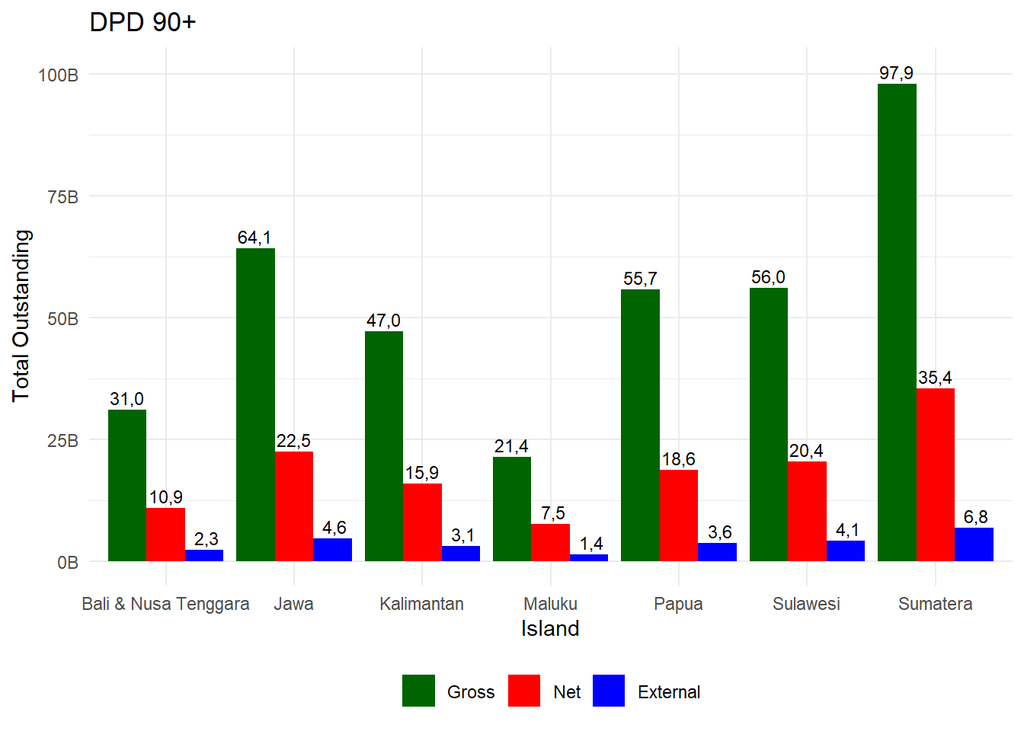

```r
# PLOT 2.4: DPD Bucket by Amount (05. 90+ DPD)
plot2.4 <- ggplot(DPD_bucket_by_amount05, aes(x = island,
                    y = Total_OS,
                    text = label)) +

  geom_col(position = position_dodge(width = 0.9),
           aes(fill = Type)) +
  geom_text(aes(y = Total_OS + 2.5e9,
                label = format(floor(Total_OS/1e8)/10,
                                     big.mark = ".",
                                     decimal.mark = ","),
                group = Type),
            position = position_dodge(width = 0.9),
            size = 3) +
  scale_y_continuous(labels = label_number(scale = 1e-9,
                                           suffix = "B",
                                           accuracy = 1)) +
   scale_fill_manual(values = c("darkgreen", "red","blue"),
                    name = NULL) +
  labs(title = "DPD 90+",
       x = "Island",
       y = "Total Outstanding") +
  theme_minimal() +
  theme(legend.position = "bottom")

plot2.4
```

```r
# This is for interactive plot
# ggplotly(plot2.4, tooltip = "text") %>%
#   layout(title = list(text = paste0(
#       "DPD 90+",
#       "<br><sup>in billion Rupiah</sup>")),
#       legend = list(orientation = "h",
#                     y = -0.3))
```

The chart presents **Total Outstanding (in billion Rupiah)** for **DPD 90+** across several **islands** in Indonesia, categorized into **Gross**, **Net**, and **External** amounts.

- **Sumatera** records the highest figures, reaching **97.9B Gross**, **35.4B Net**, and **6.8B External**.
- **Jawa**, **Sulawesi**, and **Papua** also show substantial levels, particularly in the **Gross** category.
- **Maluku** and **Bali & Nusa Tenggara** maintain relatively lower totals, with **Gross** values under **35B**.
- The **Gross values** remain significantly higher than **Net** and **External** across all islands, indicating a notable gap due to risk provisions or write-offs.
- Overall, **Sumatera** continues to dominate outstanding amounts in **DPD 90+**, consistent with earlier DPD bands.

## Section 2 (DPD Bucket by Accounts)

Now, I’m going to create a similar set of **bar plots** to visualize the **total number of accounts (NOA)** across islands for each **DPD bucket**. These visualizations provide a clearer overview of accounts distribution within the `Gross`, `Net`, and `External` datasets, making it easier to compare the concentration of accounts across islands and bucket categories.

The main goals of these plots are to:

- Compare the **total number of accounts (NOA)** across `Gross`, `Net`, and `External` datasets.
- Identify which islands have the **highest** and **lowest number of accounts** within each DPD bucket.
- Analyze the **distribution of accounts** across islands and bucket categories.
- Highlight the `DPD 90+` bucket to identify islands that require more attention due to having higher numbers of **overdue accounts**.

### PLOT 2.5: (bar plot)

“DPD Bucket by accounts (02. 1-30 DPD) ~ Total NOA vs Island”

```r
# Dataset: Gross, Net, and External
sqllab_gross_clean
```

```
#> # A tibble: 135,420 × 11
#>    cut_off_date island region area  branch bucket   noa outstanding_amount  date
#>    <date>       <fct>  <fct>  <fct> <fct>  <fct>  <int>              <dbl> <int>
#>  1 2025-11-01   Sumat… Aceh   Aceh… Aceh … 01. C…    53          91784130.     1
#>  2 2025-11-01   Sumat… Aceh   Aceh… Aceh … 02. 1…   185         254273192.     1
#>  3 2025-11-01   Sumat… Aceh   Aceh… Aceh … 03. 3…   173         431221028.     1
#>  4 2025-11-01   Sumat… Aceh   Aceh… Aceh … 04. 6…   271        1326525315.     1
#>  5 2025-11-01   Sumat… Aceh   Aceh… Aceh … 05. 9…   119         557134482.     1
#>  6 2025-11-01   Sumat… Aceh   Aceh… Aceh … 01. C…   176         836408397.     1
#>  7 2025-11-01   Sumat… Aceh   Aceh… Aceh … 02. 1…   443         850066868.     1
#>  8 2025-11-01   Sumat… Aceh   Aceh… Aceh … 03. 3…   369        1051253334.     1
#>  9 2025-11-01   Sumat… Aceh   Aceh… Aceh … 04. 6…   386         920064468.     1
#> 10 2025-11-01   Sumat… Aceh   Aceh… Aceh … 05. 9…   148         702017007.     1
#> # ℹ 135,410 more rows
#> # ℹ 2 more variables: month <dbl>, year <dbl>
```

```r
sqllab_net_clean
```

```
#> # A tibble: 135,420 × 11
#>    cut_off_date island region area  branch bucket   noa outstanding_amount  date
#>    <date>       <fct>  <fct>  <fct> <fct>  <fct>  <int>              <dbl> <int>
#>  1 2025-11-01   Sumat… Aceh   Aceh… Aceh … 01. C…    53          76934000.     1
#>  2 2025-11-01   Sumat… Aceh   Aceh… Aceh … 02. 1…   185         218410473.     1
#>  3 2025-11-01   Sumat… Aceh   Aceh… Aceh … 03. 3…   173         317760703.     1
#>  4 2025-11-01   Sumat… Aceh   Aceh… Aceh … 04. 6…   271         811554170.     1
#>  5 2025-11-01   Sumat… Aceh   Aceh… Aceh … 05. 9…   119         271330064.     1
#>  6 2025-11-01   Sumat… Aceh   Aceh… Aceh … 01. C…   176         581834603.     1
#>  7 2025-11-01   Sumat… Aceh   Aceh… Aceh … 02. 1…   443         748995851.     1
#>  8 2025-11-01   Sumat… Aceh   Aceh… Aceh … 03. 3…   369         877552083.     1
#>  9 2025-11-01   Sumat… Aceh   Aceh… Aceh … 04. 6…   386         558000043.     1
#> 10 2025-11-01   Sumat… Aceh   Aceh… Aceh … 05. 9…   148         335235117.     1
#> # ℹ 135,410 more rows
#> # ℹ 2 more variables: month <dbl>, year <dbl>
```

```r
sqllab_external_clean
```

```
#> # A tibble: 135,420 × 11
#>    cut_off_date island region area  branch bucket   noa outstanding_amount  date
#>    <date>       <fct>  <fct>  <fct> <fct>  <fct>  <int>              <dbl> <int>
#>  1 2025-11-01   Sumat… Aceh   Aceh… Aceh … 01. C…    53          64398309.     1
#>  2 2025-11-01   Sumat… Aceh   Aceh… Aceh … 02. 1…   185         206470008.     1
#>  3 2025-11-01   Sumat… Aceh   Aceh… Aceh … 03. 3…   173         231682208.     1
#>  4 2025-11-01   Sumat… Aceh   Aceh… Aceh … 04. 6…   271         648403168.     1
#>  5 2025-11-01   Sumat… Aceh   Aceh… Aceh … 05. 9…   119          50133476.     1
#>  6 2025-11-01   Sumat… Aceh   Aceh… Aceh … 01. C…   176         458579814.     1
#>  7 2025-11-01   Sumat… Aceh   Aceh… Aceh … 02. 1…   443         553795359.     1
#>  8 2025-11-01   Sumat… Aceh   Aceh… Aceh … 03. 3…   369         827679983.     1
#>  9 2025-11-01   Sumat… Aceh   Aceh… Aceh … 04. 6…   386         511141034.     1
#> 10 2025-11-01   Sumat… Aceh   Aceh… Aceh … 05. 9…   148          47998959.     1
#> # ℹ 135,410 more rows
#> # ℹ 2 more variables: month <dbl>, year <dbl>
```

Now, we’re going to derive the latest *NOA* (Number of accounts) from the *gross dataset*, specifically for the *“02. 1–30 DPD”* bucket in each island.

```r
# Gross: NOA for "02. DPD 1-30" bucket
DPD_bucket_by_accounts02_gross <- sqllab_gross_clean %>%
  filter(bucket == "02. 1-30 DPD",
         cut_off_date == "2025-11-01") %>%
  group_by(island) %>%
  summarise(total_noa = sum(noa)) %>%
  ungroup()

DPD_bucket_by_accounts02_gross
```

```
#> # A tibble: 7 × 2
#>   island               total_noa
#>   <fct>                    <int>
#> 1 Bali & Nusa Tenggara      9962
#> 2 Jawa                     18734
#> 3 Kalimantan               16075
#> 4 Maluku                    6638
#> 5 Papua                    15353
#> 6 Sulawesi                 19503
#> 7 Sumatera                 32592
```

We’re also going to derive the latest *NOA* from the *net and external dataset*, specifically for the *“02. 1–30 DPD”* bucket in each island.

```r
# Net: NOA for "02. DPD 1-30" bucket
DPD_bucket_by_accounts02_net <- sqllab_net_clean %>%
  filter(bucket == "02. 1-30 DPD",
         cut_off_date == "2025-11-01") %>%
  group_by(island) %>%
  summarise(total_noa = sum(noa))%>%
  ungroup()

DPD_bucket_by_accounts02_net
```

```
#> # A tibble: 7 × 2
#>   island               total_noa
#>   <fct>                    <int>
#> 1 Bali & Nusa Tenggara      9962
#> 2 Jawa                     18734
#> 3 Kalimantan               16075
#> 4 Maluku                    6638
#> 5 Papua                    15353
#> 6 Sulawesi                 19503
#> 7 Sumatera                 32592
```

```r
# External: NOA for "02. DPD 1-30" bucket
DPD_bucket_by_accounts02_external <- sqllab_external_clean %>%
  filter(bucket == "02. 1-30 DPD",
         cut_off_date == "2025-11-01") %>%
  group_by(island) %>%
  summarise(total_noa = sum(noa)) %>%
  ungroup()

DPD_bucket_by_accounts02_external
```

```
#> # A tibble: 7 × 2
#>   island               total_noa
#>   <fct>                    <int>
#> 1 Bali & Nusa Tenggara      9962
#> 2 Jawa                     18734
#> 3 Kalimantan               16075
#> 4 Maluku                    6638
#> 5 Papua                    15353
#> 6 Sulawesi                 19503
#> 7 Sumatera                 32592
```

After obtaining the latest *Gross, Net, and External NOA*, specifically for the *“02. 1–30 DPD”* bucket in each island, we then *merge* and *pivot* them into one dataset for easier visualization.

```r
# Merging Gross, Net, and External "02. DPD 1-30" bucket NOA into one dataset
DPD_bucket_by_accounts02 <- DPD_bucket_by_accounts02_gross %>%
  inner_join(DPD_bucket_by_accounts02_net, by = "island") %>%
  inner_join(DPD_bucket_by_accounts02_external, by = "island") %>%
  rename(
    Gross = total_noa.x,
    Net = total_noa.y,
    External = total_noa
  )

DPD_bucket_by_accounts02
```

```
#> # A tibble: 7 × 4
#>   island               Gross   Net External
#>   <fct>                <int> <int>    <int>
#> 1 Bali & Nusa Tenggara  9962  9962     9962
#> 2 Jawa                 18734 18734    18734
#> 3 Kalimantan           16075 16075    16075
#> 4 Maluku                6638  6638     6638
#> 5 Papua                15353 15353    15353
#> 6 Sulawesi             19503 19503    19503
#> 7 Sumatera             32592 32592    32592
```

```r
# Pivot and adding NPL type column
DPD_bucket_by_accounts02 <- DPD_bucket_by_accounts02 %>%
  pivot_longer(
    cols = c(Gross, Net, External),
    names_to = "Type",
    values_to = "Total_accounts"
  ) %>%
  mutate(Type = factor(Type, levels = c("Gross", "Net", "External")))

DPD_bucket_by_accounts02
```

```
#> # A tibble: 21 × 3
#>    island               Type     Total_accounts
#>    <fct>                <fct>             <int>
#>  1 Bali & Nusa Tenggara Gross              9962
#>  2 Bali & Nusa Tenggara Net                9962
#>  3 Bali & Nusa Tenggara External           9962
#>  4 Jawa                 Gross             18734
#>  5 Jawa                 Net               18734
#>  6 Jawa                 External          18734
#>  7 Kalimantan           Gross             16075
#>  8 Kalimantan           Net               16075
#>  9 Kalimantan           External          16075
#> 10 Maluku               Gross              6638
#> # ℹ 11 more rows
```

```r
# tooltip
DPD_bucket_by_accounts02 <- DPD_bucket_by_accounts02 %>%
  mutate(
    label = glue(
      "Total accounts: {number(Total_accounts, big.mark = '.', decimal.mark = ',', accuracy = 1)}"
    )
  )

DPD_bucket_by_accounts02
```

```
#> # A tibble: 21 × 4
#>    island               Type     Total_accounts label
#>    <fct>                <fct>             <int> <glue>
#>  1 Bali & Nusa Tenggara Gross              9962 Total accounts: 9.962
#>  2 Bali & Nusa Tenggara Net                9962 Total accounts: 9.962
#>  3 Bali & Nusa Tenggara External           9962 Total accounts: 9.962
#>  4 Jawa                 Gross             18734 Total accounts: 18.734
#>  5 Jawa                 Net               18734 Total accounts: 18.734
#>  6 Jawa                 External          18734 Total accounts: 18.734
#>  7 Kalimantan           Gross             16075 Total accounts: 16.075
#>  8 Kalimantan           Net               16075 Total accounts: 16.075
#>  9 Kalimantan           External          16075 Total accounts: 16.075
#> 10 Maluku               Gross              6638 Total accounts: 6.638
#> # ℹ 11 more rows
```

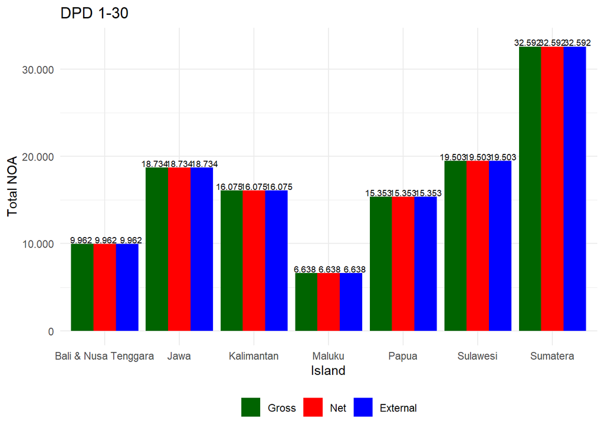

```r
# PLOT 2.5: DPD Bucket by accounts (02. 1-30 DPD)
plot2.5 <- ggplot(DPD_bucket_by_accounts02, aes(x = island,
                    y = Total_accounts,
                    text = label)) +

  geom_col(position = position_dodge(width = 0.9),
           aes(fill = Type)) +
  geom_text(aes(y = Total_accounts + 500,
                label = format(Total_accounts,
                               big.mark = ".",
                               decimal.mark = ","),
                group = Type),
            position = position_dodge(width = 1),
            size = 2.5) +
   scale_y_continuous(labels = label_comma(big.mark = ".", decimal.mark = ",")) +
   scale_fill_manual(values = c("darkgreen", "red","blue"),
                    name = NULL) +
  labs(title = "DPD 1-30",
       x = "Island",
       y = "Total NOA") +
  theme_minimal() +
  theme(legend.position = "bottom")

plot2.5
```

```r
# This is for interactive plot
# ggplotly(plot2.5, tooltip = "text") %>%
#   layout(title = list(text = paste0(
#       "DPD 1-30")),
#       legend = list(orientation = "h",
#                     y = -0.3))
```

The chart shows **Total NOA** for **DPD 1–30** across different **islands** in Indonesia, categorized into **Gross**, **Net**, and **External** values.

- **Sumatera** has the **highest** total with **32,592** accounts,
- while **Maluku** has the **lowest** with **6,638** accounts.
- All three categories (`Gross`, `Net`, and `External`) show **identical values** across each island, indicating no variation between NPL types at this delinquency stage.

### PLOT 2.6: (bar plot)

“DPD Bucket by accounts (03. 31-60 DPD) ~ Total NOA vs Island”

```r
# Dataset: Gross, Net, and External
sqllab_gross_clean
```

```
#> # A tibble: 135,420 × 11
#>    cut_off_date island region area  branch bucket   noa outstanding_amount  date
#>    <date>       <fct>  <fct>  <fct> <fct>  <fct>  <int>              <dbl> <int>
#>  1 2025-11-01   Sumat… Aceh   Aceh… Aceh … 01. C…    53          91784130.     1
#>  2 2025-11-01   Sumat… Aceh   Aceh… Aceh … 02. 1…   185         254273192.     1
#>  3 2025-11-01   Sumat… Aceh   Aceh… Aceh … 03. 3…   173         431221028.     1
#>  4 2025-11-01   Sumat… Aceh   Aceh… Aceh … 04. 6…   271        1326525315.     1
#>  5 2025-11-01   Sumat… Aceh   Aceh… Aceh … 05. 9…   119         557134482.     1
#>  6 2025-11-01   Sumat… Aceh   Aceh… Aceh … 01. C…   176         836408397.     1
#>  7 2025-11-01   Sumat… Aceh   Aceh… Aceh … 02. 1…   443         850066868.     1
#>  8 2025-11-01   Sumat… Aceh   Aceh… Aceh … 03. 3…   369        1051253334.     1
#>  9 2025-11-01   Sumat… Aceh   Aceh… Aceh … 04. 6…   386         920064468.     1
#> 10 2025-11-01   Sumat… Aceh   Aceh… Aceh … 05. 9…   148         702017007.     1
#> # ℹ 135,410 more rows
#> # ℹ 2 more variables: month <dbl>, year <dbl>
```

```r
sqllab_net_clean
```

```
#> # A tibble: 135,420 × 11
#>    cut_off_date island region area  branch bucket   noa outstanding_amount  date
#>    <date>       <fct>  <fct>  <fct> <fct>  <fct>  <int>              <dbl> <int>
#>  1 2025-11-01   Sumat… Aceh   Aceh… Aceh … 01. C…    53          76934000.     1
#>  2 2025-11-01   Sumat… Aceh   Aceh… Aceh … 02. 1…   185         218410473.     1
#>  3 2025-11-01   Sumat… Aceh   Aceh… Aceh … 03. 3…   173         317760703.     1
#>  4 2025-11-01   Sumat… Aceh   Aceh… Aceh … 04. 6…   271         811554170.     1
#>  5 2025-11-01   Sumat… Aceh   Aceh… Aceh … 05. 9…   119         271330064.     1
#>  6 2025-11-01   Sumat… Aceh   Aceh… Aceh … 01. C…   176         581834603.     1
#>  7 2025-11-01   Sumat… Aceh   Aceh… Aceh … 02. 1…   443         748995851.     1
#>  8 2025-11-01   Sumat… Aceh   Aceh… Aceh … 03. 3…   369         877552083.     1
#>  9 2025-11-01   Sumat… Aceh   Aceh… Aceh … 04. 6…   386         558000043.     1
#> 10 2025-11-01   Sumat… Aceh   Aceh… Aceh … 05. 9…   148         335235117.     1
#> # ℹ 135,410 more rows
#> # ℹ 2 more variables: month <dbl>, year <dbl>
```

```r
sqllab_external_clean
```

```
#> # A tibble: 135,420 × 11
#>    cut_off_date island region area  branch bucket   noa outstanding_amount  date
#>    <date>       <fct>  <fct>  <fct> <fct>  <fct>  <int>              <dbl> <int>
#>  1 2025-11-01   Sumat… Aceh   Aceh… Aceh … 01. C…    53          64398309.     1
#>  2 2025-11-01   Sumat… Aceh   Aceh… Aceh … 02. 1…   185         206470008.     1
#>  3 2025-11-01   Sumat… Aceh   Aceh… Aceh … 03. 3…   173         231682208.     1
#>  4 2025-11-01   Sumat… Aceh   Aceh… Aceh … 04. 6…   271         648403168.     1
#>  5 2025-11-01   Sumat… Aceh   Aceh… Aceh … 05. 9…   119          50133476.     1
#>  6 2025-11-01   Sumat… Aceh   Aceh… Aceh … 01. C…   176         458579814.     1
#>  7 2025-11-01   Sumat… Aceh   Aceh… Aceh … 02. 1…   443         553795359.     1
#>  8 2025-11-01   Sumat… Aceh   Aceh… Aceh … 03. 3…   369         827679983.     1
#>  9 2025-11-01   Sumat… Aceh   Aceh… Aceh … 04. 6…   386         511141034.     1
#> 10 2025-11-01   Sumat… Aceh   Aceh… Aceh … 05. 9…   148          47998959.     1
#> # ℹ 135,410 more rows
#> # ℹ 2 more variables: month <dbl>, year <dbl>
```

Now, we’re going to derive the latest *NOA* (Number of accounts) from the *gross, net, and external dataset*, specifically for the *“03. 31-60 DPD”* bucket in each island.

```r
# Gross: NOA for "03. 31-60 DPD" bucket
DPD_bucket_by_accounts03_gross <- sqllab_gross_clean %>%
  filter(bucket == "03. 31-60 DPD",
         cut_off_date == "2025-11-01") %>%
  group_by(island) %>%
  summarise(total_noa = sum(noa)) %>%
  ungroup()

DPD_bucket_by_accounts03_gross
```

```
#> # A tibble: 7 × 2
#>   island               total_noa
#>   <fct>                    <int>
#> 1 Bali & Nusa Tenggara      9998
#> 2 Jawa                     18446
#> 3 Kalimantan               18053
#> 4 Maluku                    5690
#> 5 Papua                    14883
#> 6 Sulawesi                 20514
#> 7 Sumatera                 32491
```

```r
# Net: NOA for "03. 31-60 DPD" bucket
DPD_bucket_by_accounts03_net <- sqllab_net_clean %>%
  filter(bucket == "03. 31-60 DPD",
         cut_off_date == "2025-11-01") %>%
  group_by(island) %>%
  summarise(total_noa = sum(noa))%>%
  ungroup()

DPD_bucket_by_accounts03_net
```

```
#> # A tibble: 7 × 2
#>   island               total_noa
#>   <fct>                    <int>
#> 1 Bali & Nusa Tenggara      9998
#> 2 Jawa                     18446
#> 3 Kalimantan               18053
#> 4 Maluku                    5690
#> 5 Papua                    14883
#> 6 Sulawesi                 20514
#> 7 Sumatera                 32491
```

```r
# External: NOA for "03. 31-60 DPD" bucket
DPD_bucket_by_accounts03_external <- sqllab_external_clean %>%
  filter(bucket == "03. 31-60 DPD",
         cut_off_date == "2025-11-01") %>%
  group_by(island) %>%
  summarise(total_noa = sum(noa)) %>%
  ungroup()

DPD_bucket_by_accounts03_external
```

```
#> # A tibble: 7 × 2
#>   island               total_noa
#>   <fct>                    <int>
#> 1 Bali & Nusa Tenggara      9998
#> 2 Jawa                     18446
#> 3 Kalimantan               18053
#> 4 Maluku                    5690
#> 5 Papua                    14883
#> 6 Sulawesi                 20514
#> 7 Sumatera                 32491
```

We then *merge* and *pivot* all the latest *Gross, Net, and External NOA* into one dataset for easier visualization.

```r
# Merging Gross, Net, and External "03. 31-60 DPD" bucket NOA into one dataset
DPD_bucket_by_accounts03 <- DPD_bucket_by_accounts03_gross %>%
  inner_join(DPD_bucket_by_accounts03_net, by = "island") %>%
  inner_join(DPD_bucket_by_accounts03_external, by = "island") %>%
  rename(
    Gross = total_noa.x,
    Net = total_noa.y,
    External = total_noa
  )

DPD_bucket_by_accounts03
```

```
#> # A tibble: 7 × 4
#>   island               Gross   Net External
#>   <fct>                <int> <int>    <int>
#> 1 Bali & Nusa Tenggara  9998  9998     9998
#> 2 Jawa                 18446 18446    18446
#> 3 Kalimantan           18053 18053    18053
#> 4 Maluku                5690  5690     5690
#> 5 Papua                14883 14883    14883
#> 6 Sulawesi             20514 20514    20514
#> 7 Sumatera             32491 32491    32491
```

```r
# Pivot and adding NPL type column
DPD_bucket_by_accounts03 <- DPD_bucket_by_accounts03 %>%
  pivot_longer(
    cols = c(Gross, Net, External),
    names_to = "Type",
    values_to = "Total_accounts"
  ) %>%
  mutate(Type = factor(Type, levels = c("Gross", "Net", "External")))

DPD_bucket_by_accounts03
```

```
#> # A tibble: 21 × 3
#>    island               Type     Total_accounts
#>    <fct>                <fct>             <int>
#>  1 Bali & Nusa Tenggara Gross              9998
#>  2 Bali & Nusa Tenggara Net                9998
#>  3 Bali & Nusa Tenggara External           9998
#>  4 Jawa                 Gross             18446
#>  5 Jawa                 Net               18446
#>  6 Jawa                 External          18446
#>  7 Kalimantan           Gross             18053
#>  8 Kalimantan           Net               18053
#>  9 Kalimantan           External          18053
#> 10 Maluku               Gross              5690
#> # ℹ 11 more rows
```

```r
# tooltip
DPD_bucket_by_accounts03 <- DPD_bucket_by_accounts03 %>%
  mutate(
    label = glue(
      "Total accounts: {number(Total_accounts, big.mark = '.', decimal.mark = ',', accuracy = 1)}"
    )
  )

DPD_bucket_by_accounts03
```

```
#> # A tibble: 21 × 4
#>    island               Type     Total_accounts label
#>    <fct>                <fct>             <int> <glue>
#>  1 Bali & Nusa Tenggara Gross              9998 Total accounts: 9.998
#>  2 Bali & Nusa Tenggara Net                9998 Total accounts: 9.998
#>  3 Bali & Nusa Tenggara External           9998 Total accounts: 9.998
#>  4 Jawa                 Gross             18446 Total accounts: 18.446
#>  5 Jawa                 Net               18446 Total accounts: 18.446
#>  6 Jawa                 External          18446 Total accounts: 18.446
#>  7 Kalimantan           Gross             18053 Total accounts: 18.053
#>  8 Kalimantan           Net               18053 Total accounts: 18.053
#>  9 Kalimantan           External          18053 Total accounts: 18.053
#> 10 Maluku               Gross              5690 Total accounts: 5.690
#> # ℹ 11 more rows
```

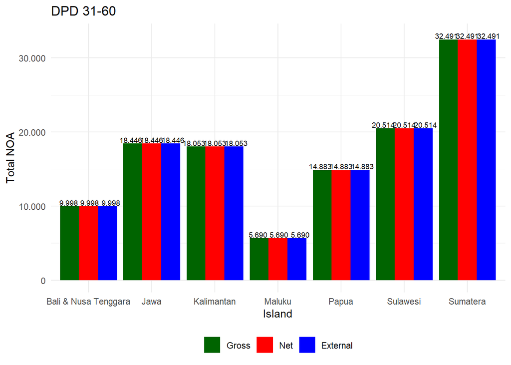

```r
# PLOT 2.6: DPD Bucket by accounts (03. 31-60 DPD)
plot2.6 <- ggplot(DPD_bucket_by_accounts03, aes(x = island,
                    y = Total_accounts,
                    text = label)) +

  geom_col(position = position_dodge(width = 0.9),
           aes(fill = Type)) +
  geom_text(aes(y = Total_accounts + 500,
                label = format(Total_accounts,
                               big.mark = ".",
                               decimal.mark = ","),
                group = Type),
            position = position_dodge(width = 1),
            size = 2.5) +
   scale_y_continuous(labels = label_comma(big.mark = ".", decimal.mark = ",")) +
   scale_fill_manual(values = c("darkgreen", "red","blue"),
                    name = NULL) +
  labs(title = "DPD 31-60",
       x = "Island",
       y = "Total NOA") +
  theme_minimal() +
  theme(legend.position = "bottom")

plot2.6
```

```r
# This is for interactive plot
# ggplotly(plot2.6, tooltip = "text") %>%
#   layout(title = list(text = paste0(
#       "DPD 31-60")),
#       legend = list(orientation = "h",
#                     y = -0.3))
```

The chart illustrates **Total NOA** for **DPD 31–60** across various **islands** in Indonesia, divided into **Gross**, **Net**, and **External** categories.

- **Sumatera** has the **highest** total at **32.491** accounts,
- while **Maluku** has the **lowest** at **5.690** accounts.